# Supervised Regression: 30-Model Comparison

### Prediction on test set with Hyperparameter tuning

```python
start_time = time.perf_counter()
```

```python
if not QUICK_LOAD:
    print("Extra Trees Regressor: predicting best model...")
    extra_trees_best_pred_train = extra_trees_best_tuning.predict(X_train)
    extra_trees_best_pred_test = extra_trees_best_tuning.predict(X_test)
    print("Extra Trees Regressor: best model predicted successfully.\n")

else:
    print("Extra Trees Regressor: loading best predicted model...")
    extra_trees_best_pred_train = loaded_predictions["extra_trees_best_pred_train_file"]
    extra_trees_best_pred_test = loaded_predictions["extra_trees_best_pred_test_file"]
    print("Extra Trees Regressor: best model loaded successfully.\n")


extra_trees_best_results = evaluate_regression(
    y_test,
    extra_trees_best_pred_test,
    "Best Extra Trees Regressor",
    y_train_true=y_train,
    y_train_pred=extra_trees_best_pred_train
)
```

```
Extra Trees Regressor: predicting best model...
Extra Trees Regressor: best model predicted successfully.

--- Best Extra Trees Regressor ---
TEST
MAE:  274.34
RMSE: 542.91
R²:   0.9815

TRAIN
MAE:  167.43
RMSE: 317.42
R²:   0.9937

GAP
RMSE gap: 225.49
R² gap:   0.0122
```

```python
extra_trees_tuning_predict_time = time.perf_counter() - start_time
formatted_time = str(timedelta(seconds=int(extra_trees_tuning_predict_time)))
print(f"Tuning predict time: {formatted_time}")
```

```
Tuning predict time: 0:00:01
```

### Test set prediction comparison

```python
extra_trees_results_comparison = pd.DataFrame({
    "Original Label": y_test.loc[sample_idx],
    "Prediction": pd.Series(extra_trees_best_pred_test, index=X_test.index).loc[sample_idx]
})

### Save test set predictions for each model
extra_trees_sample_pred = pd.Series(extra_trees_best_pred_test, index=X_test.index).loc[sample_idx]

extra_trees_results_comparison["Error"] = extra_trees_results_comparison["Prediction"] - extra_trees_results_comparison["Original Label"]
extra_trees_results_comparison.sample(15, random_state=RANDOM_STATE).sort_values("Original Label").T.style.format("{:.2f}") \
    .set_properties(
        subset=pd.IndexSlice[["Original Label"], :],
        **{"background-color": "#ffd966"}
    ) \
    .map_index(
        lambda v: "background-color: #ffd966" if v == "Original Label" else "",
        axis=0
    )
```

|  | 8048 | 9730 | 4593 | 3706 | 5458 | 8353 | 6130 | 510 | 10382 | 7331 | 6319 | 6725 | 10334 | 3614 | 7116 |
| --- | --- | --- | --- | --- | --- | --- | --- | --- | --- | --- | --- | --- | --- | --- | --- |
| Original Label | 571.00 | 764.00 | 827.00 | 1148.00 | 1356.00 | 1400.00 | 2669.00 | 2822.00 | 3943.00 | 4155.00 | 4404.00 | 7670.00 | 8828.00 | 11861.00 | 16670.00 |
| Prediction | 605.09 | 801.38 | 899.26 | 1088.67 | 1316.88 | 1253.70 | 3033.42 | 2766.04 | 3599.58 | 4248.03 | 4426.43 | 7235.36 | 11459.84 | 11563.48 | 14764.40 |
| Error | 34.09 | 37.38 | 72.26 | -59.33 | -39.12 | -146.30 | 364.42 | -55.96 | -343.42 | 93.03 | 22.43 | -434.64 | 2631.84 | -297.52 | -1905.60 |

### Add formatted timing and model type to the results

```python
extra_trees_results["Model_type"] = "Tree-based ensemble"

extra_trees_results["Fit_time"] = str(timedelta(seconds=int(extra_trees_fit_time)))
extra_trees_results["Pred_time"] = str(timedelta(seconds=int(extra_trees_predict_time)))
extra_trees_results["Tun_fit_time"] = str(timedelta(seconds=int(extra_trees_tuning_fit_time)))
extra_trees_results["Tun_pred_time"] = str(timedelta(seconds=int(extra_trees_tuning_predict_time)))
extra_trees_results["Full_model_time"] = str(timedelta(seconds=int(extra_trees_fit_time + extra_trees_predict_time + extra_trees_tuning_fit_time + extra_trees_tuning_predict_time)))

extra_trees_results["Tun_MAE"] = extra_trees_best_results["MAE"]
extra_trees_results["Tun_RMSE"] = extra_trees_best_results["RMSE"]
extra_trees_results["Tun_R2"] = extra_trees_best_results["R2"]

extra_trees_results["Tun_Train_MAE"] = extra_trees_best_results["Train_MAE"]
extra_trees_results["Tun_Train_RMSE"] = extra_trees_best_results["Train_RMSE"]
extra_trees_results["Tun_Train_R2"] = extra_trees_best_results["Train_R2"]
```

# **Boosting ensemble models**

## AdaBoost Regressor

The AdaBoostRegressor combines many weak models and improves them step by step by focusing more on difficult training examples.

```python
start_fit = time.perf_counter()
```

```python
if not QUICK_LOAD:
    from sklearn.ensemble import AdaBoostRegressor

    ada_param = {
        # Most important parameters: n_estimators, learning_rate, loss
        "n_estimators": 100,       # Default: 50 -> Often worth trying values between 25 and 500
        "learning_rate": 0.1,      # Default: 1.0 -> Often worth trying values between 0.01 and 1.0
        "loss": "linear"           # Default: "linear" -> Common alternatives: "square", "exponential"
    }

    ada_reg = Pipeline([
        ("preprocessing", tree_preprocessing),
        ("model", AdaBoostRegressor(random_state=RANDOM_STATE, **ada_param))
    ])

    print("AdaBoost Regressor: fitting model...")
    ada_reg.fit(X_train, y_train)
    print("AdaBoost Regressor: fitted successfully.")

else:
    print("AdaBoost Regressor: loading fitted model...")
    ada_reg = loaded_fitted_base_models["adaboost"]
    print("AdaBoost Regressor: loaded successfully.")
```

```
AdaBoost Regressor: fitting model...
AdaBoost Regressor: fitted successfully.
```

```python
ada_fit_time = time.perf_counter() - start_fit
formatted_time = str(timedelta(seconds=int(ada_fit_time)))
print(f"Fit time: {formatted_time}")
```

```
Fit time: 0:00:11
```

### Features created by AdaBoost Regressor Model

```python
# Number of input features used by the model
print("Number of input features:", ada_reg.named_steps["model"].n_features_in_)
```

```
Number of input features: 26
```

```python
# Names of the transformed features after preprocessing
print("Feature names after preprocessing:\n", ada_reg.named_steps["preprocessing"].get_feature_names_out())
```

```
Feature names after preprocessing:
 ['num__carat' 'num__depth' 'num__table' 'num__x' 'num__y' 'num__z'
 'cat__cut_Fair' 'cat__cut_Good' 'cat__cut_Ideal' 'cat__cut_Premium'
 'cat__cut_Very Good' 'cat__color_D' 'cat__color_E' 'cat__color_F'
 'cat__color_G' 'cat__color_H' 'cat__color_I' 'cat__color_J'
 'cat__clarity_I1' 'cat__clarity_IF' 'cat__clarity_SI1' 'cat__clarity_SI2'
 'cat__clarity_VS1' 'cat__clarity_VS2' 'cat__clarity_VVS1'
 'cat__clarity_VVS2']
```

### Prediction on test set

```python
start_pred = time.perf_counter()
```

```python
if not QUICK_LOAD:
    print("AdaBoost Regressor: predicting model...")
    ada_pred_train = ada_reg.predict(X_train)
    ada_pred_test = ada_reg.predict(X_test)
    print("AdaBoost Regressor: predicted successfully.\n")

else:
    print("AdaBoost Regressor: loading predicted model...")
    ada_pred_train = loaded_predictions["ada_pred_train_file"]
    ada_pred_test = loaded_predictions["ada_pred_test_file"]
    print("AdaBoost Regressor: loaded successfully.\n")


ada_results = evaluate_regression(
    y_test,
    ada_pred_test,
    model_name="AdaBoost Regressor",
    y_train_true=y_train,
    y_train_pred=ada_pred_train
)
```

```
AdaBoost Regressor: predicting model...
AdaBoost Regressor: predicted successfully.

--- AdaBoost Regressor ---
TEST
MAE:  889.86
RMSE: 1384.47
R²:   0.8796

TRAIN
MAE:  877.80
RMSE: 1353.13
R²:   0.8850

GAP
RMSE gap: 31.34
R² gap:   0.0054
```

```python
ada_predict_time = time.perf_counter() - start_pred
formatted_time = str(timedelta(seconds=int(ada_predict_time)))
print(f"Predict time: {formatted_time}")
```

```
Predict time: 0:00:01
```

### Hyperparameter Tuning

```python
start_time = time.perf_counter()
```

```python
if not QUICK_LOAD:
    from sklearn.model_selection import RandomizedSearchCV
    from sklearn.tree import DecisionTreeRegressor

    ada_search_reg = Pipeline([
        ("preprocessing", tree_preprocessing),
        ("model", AdaBoostRegressor(
            estimator=DecisionTreeRegressor(random_state=RANDOM_STATE),
            random_state=RANDOM_STATE
        ))
    ])

    ada_param_dist = {
        "model__n_estimators": [25, 50, 100, 200, 300, 500],
        "model__learning_rate": [0.01, 0.03, 0.05, 0.1, 0.2, 0.5, 1.0],
        "model__loss": ["linear", "square", "exponential"],
        "model__estimator__max_depth": [1, 2, 3, 4, 5, 6],
        "model__estimator__min_samples_split": [2, 5, 10, 20],
        "model__estimator__min_samples_leaf": [1, 2, 4, 8]
    }

    ada_search = RandomizedSearchCV(
        ada_search_reg,                           # The pipeline model to tune
        param_distributions=ada_param_dist,       # Dictionary with parameter values to test
        n_iter=40,                                # Number of random combinations to try
        scoring=SCORING,                          # Evaluation metric
        cv=KFOLD_5,                               # Number of cross-validation folds
        n_jobs=N_JOBS,                            # Parallel jobs
        verbose=VERBOSE,                          # Show progress during fitting
        random_state=RANDOM_STATE,                # Reproducible random search
        error_score=ERROR_SCORE                   # Raise error immediately if a fit fails
    )

    print("AdaBoost Regressor: running randomized search...")
    ada_search.fit(X_train, y_train)
    print("AdaBoost Regressor: randomized search completed successfully.")

else:
    print("AdaBoost Regressor: loading search object...")
    ada_search = loaded_searches["adaboost"]
    print("AdaBoost Regressor: search object loaded successfully.")
```

```
AdaBoost Regressor: running randomized search...
Fitting 5 folds for each of 40 candidates, totalling 200 fits
AdaBoost Regressor: randomized search completed successfully.
```

```python
ada_tuning_fit_time = time.perf_counter() - start_time
formatted_time = str(timedelta(seconds=int(ada_tuning_fit_time)))
print(f"Tuning time: {formatted_time}")
```

```
Tuning time: 0:19:30
```

```python
# Best parameters
ada_search.best_params_
```

```
{'model__n_estimators': 300,
 'model__loss': 'exponential',
 'model__learning_rate': 0.1,
 'model__estimator__min_samples_split': 5,
 'model__estimator__min_samples_leaf': 4,
 'model__estimator__max_depth': 6}
```

```python
# Best model
ada_best_tuning = ada_search.best_estimator_
```

### Prediction on test set with Hyperparameter tuning

```python
start_time = time.perf_counter()
```

```python
if not QUICK_LOAD:
    print("AdaBoost Regressor: predicting best model...")
    ada_best_pred_train = ada_best_tuning.predict(X_train)
    ada_best_pred_test = ada_best_tuning.predict(X_test)
    print("AdaBoost Regressor: best model predicted successfully.\n")

else:
    print("AdaBoost Regressor: loading best predicted model...")
    ada_best_pred_train = loaded_predictions["ada_best_pred_train_file"]
    ada_best_pred_test = loaded_predictions["ada_best_pred_test_file"]
    print("AdaBoost Regressor: best model loaded successfully.\n")


ada_best_results = evaluate_regression(
    y_test,
    ada_best_pred_test,
    "Best AdaBoost Regressor",
    y_train_true=y_train,
    y_train_pred=ada_best_pred_train
)
```

```
AdaBoost Regressor: predicting best model...
AdaBoost Regressor: best model predicted successfully.

--- Best AdaBoost Regressor ---
TEST
MAE:  543.39
RMSE: 843.12
R²:   0.9553

TRAIN
MAE:  526.20
RMSE: 797.54
R²:   0.9600

GAP
RMSE gap: 45.58
R² gap:   0.0047
```

```python
ada_tuning_predict_time = time.perf_counter() - start_time
formatted_time = str(timedelta(seconds=int(ada_tuning_predict_time)))
print(f"Tuning predict time: {formatted_time}")
```

```
Tuning predict time: 0:00:04
```

### Test set prediction comparison

```python
ada_results_comparison = pd.DataFrame({
    "Original Label": y_test.loc[sample_idx],
    "Prediction": pd.Series(ada_best_pred_test, index=X_test.index).loc[sample_idx]
})

### Save test set predictions for each model
ada_sample_pred = pd.Series(ada_best_pred_test, index=X_test.index).loc[sample_idx]

ada_results_comparison["Error"] = ada_results_comparison["Prediction"] - ada_results_comparison["Original Label"]
ada_results_comparison.sample(15, random_state=RANDOM_STATE).sort_values("Original Label").T.style.format("{:.2f}") \
    .set_properties(
        subset=pd.IndexSlice[["Original Label"], :],
        **{"background-color": "#ffd966"}
    ) \
    .map_index(
        lambda v: "background-color: #ffd966" if v == "Original Label" else "",
        axis=0
    )
```

|  | 8048 | 9730 | 4593 | 3706 | 5458 | 8353 | 6130 | 510 | 10382 | 7331 | 6319 | 6725 | 10334 | 3614 | 7116 |
| --- | --- | --- | --- | --- | --- | --- | --- | --- | --- | --- | --- | --- | --- | --- | --- |
| Original Label | 571.00 | 764.00 | 827.00 | 1148.00 | 1356.00 | 1400.00 | 2669.00 | 2822.00 | 3943.00 | 4155.00 | 4404.00 | 7670.00 | 8828.00 | 11861.00 | 16670.00 |
| Prediction | 854.64 | 735.27 | 960.77 | 827.00 | 1067.45 | 1018.77 | 4078.16 | 3320.33 | 4060.06 | 4106.89 | 5350.24 | 6713.44 | 11338.75 | 11486.76 | 14039.76 |
| Error | 283.64 | -28.73 | 133.77 | -321.00 | -288.55 | -381.23 | 1409.16 | 498.33 | 117.06 | -48.11 | 946.24 | -956.56 | 2510.75 | -374.24 | -2630.24 |

### Add formatted timing and model type to the results

```python
ada_results["Model_type"] = "Boosting ensemble"

ada_results["Fit_time"] = str(timedelta(seconds=int(ada_fit_time)))
ada_results["Pred_time"] = str(timedelta(seconds=int(ada_predict_time)))
ada_results["Tun_fit_time"] = str(timedelta(seconds=int(ada_tuning_fit_time)))
ada_results["Tun_pred_time"] = str(timedelta(seconds=int(ada_tuning_predict_time)))
ada_results["Full_model_time"] = str(timedelta(seconds=int(ada_fit_time + ada_predict_time + ada_tuning_fit_time + ada_tuning_predict_time)))

ada_results["Tun_MAE"] = ada_best_results["MAE"]
ada_results["Tun_RMSE"] = ada_best_results["RMSE"]
ada_results["Tun_R2"] = ada_best_results["R2"]

ada_results["Tun_Train_MAE"] = ada_best_results["Train_MAE"]
ada_results["Tun_Train_RMSE"] = ada_best_results["Train_RMSE"]
ada_results["Tun_Train_R2"] = ada_best_results["Train_R2"]
```

## Gradient Boosting Regressor

The GradientBoostingRegressor is an ensemble model that builds trees step by step, where each new tree tries to correct the errors of the previous ones.

```python
start_fit = time.perf_counter()
```

```python
if not QUICK_LOAD:
    from sklearn.ensemble import GradientBoostingRegressor

    gbr_param = {
        # Most important parameters: n_estimators, learning_rate, max_depth, subsample
        "n_estimators": 200,        # Default: 100 -> Often worth trying values between 100 and 1000
        "learning_rate": 0.05,      # Default: 0.1 -> From 0.01 to 0.8 - smaller learning_rate → slower but often better learning
        "max_depth": 3,             # Default: 3 -> Often worth trying values between 2 and 8
        "subsample": 0.8,           # Default: 1.0 -> From 0.5 to 1.0 - smaller value → more randomness
        "loss": "squared_error"     # Default: "squared_error" -> Common alternatives: "absolute_error", "huber", "quantile"
    }

    gbr_reg = Pipeline([
        ("preprocessing", tree_preprocessing),
        ("model", GradientBoostingRegressor(random_state=RANDOM_STATE, **gbr_param))
    ])

    print("Gradient Boosting Regressor: fitting model...")
    gbr_reg.fit(X_train, y_train)
    print("Gradient Boosting Regressor: fitted successfully.")

else:
    print("Gradient Boosting Regressor: loading fitted model...")
    gbr_reg = loaded_fitted_base_models["gradient_boosting"]
    print("Gradient Boosting Regressor: loaded successfully.")
```

```
Gradient Boosting Regressor: fitting model...
Gradient Boosting Regressor: fitted successfully.
```

```python
gbr_fit_time = time.perf_counter() - start_fit
formatted_time = str(timedelta(seconds=int(gbr_fit_time)))
print(f"Fit time: {formatted_time}")
```

```
Fit time: 0:00:15
```

### Features created by Gradient Boosting Regressor Model

```python
# Number of input features used by the model
print("Number of input features:", gbr_reg.named_steps["model"].n_features_in_)
```

```
Number of input features: 26
```

```python
# Names of the transformed features after preprocessing
print("Feature names after preprocessing:\n", gbr_reg.named_steps["preprocessing"].get_feature_names_out())
```

```
Feature names after preprocessing:
 ['num__carat' 'num__depth' 'num__table' 'num__x' 'num__y' 'num__z'
 'cat__cut_Fair' 'cat__cut_Good' 'cat__cut_Ideal' 'cat__cut_Premium'
 'cat__cut_Very Good' 'cat__color_D' 'cat__color_E' 'cat__color_F'
 'cat__color_G' 'cat__color_H' 'cat__color_I' 'cat__color_J'
 'cat__clarity_I1' 'cat__clarity_IF' 'cat__clarity_SI1' 'cat__clarity_SI2'
 'cat__clarity_VS1' 'cat__clarity_VS2' 'cat__clarity_VVS1'
 'cat__clarity_VVS2']
```

### Prediction on test set

```python
start_pred = time.perf_counter()
```

```python
if not QUICK_LOAD:
    print("Gradient Boosting Regressor: predicting model...")
    gbr_pred_train = gbr_reg.predict(X_train)
    gbr_pred_test = gbr_reg.predict(X_test)
    print("Gradient Boosting Regressor: predicted successfully.\n")

else:
    print("Gradient Boosting Regressor: loading predicted model...")
    gbr_pred_train = loaded_predictions["gbr_pred_train_file"]
    gbr_pred_test = loaded_predictions["gbr_pred_test_file"]
    print("Gradient Boosting Regressor: loaded successfully.\n")


gbr_results = evaluate_regression(
    y_test,
    gbr_pred_test,
    model_name="Gradient Boosting Regressor",
    y_train_true=y_train,
    y_train_pred=gbr_pred_train
)
```

```
Gradient Boosting Regressor: predicting model...
Gradient Boosting Regressor: predicted successfully.

--- Gradient Boosting Regressor ---
TEST
MAE:  410.94
RMSE: 757.78
R²:   0.9639

TRAIN
MAE:  394.16
RMSE: 711.06
R²:   0.9682

GAP
RMSE gap: 46.72
R² gap:   0.0043
```

```python
gbr_predict_time = time.perf_counter() - start_pred
formatted_time = str(timedelta(seconds=int(gbr_predict_time)))
print(f"Predict time: {formatted_time}")
```

```
Predict time: 0:00:00
```

### Hyperparameter Tuning

```python
start_time = time.perf_counter()
```

```python
if not QUICK_LOAD:
    from sklearn.model_selection import RandomizedSearchCV

    gbr_param_dist = {
        "model__n_estimators": [600, 700, 800, 862, 900, 1000],
        "model__learning_rate": [0.03, 0.04, 0.046, 0.05, 0.06, 0.08],
        "model__max_depth": [4, 5, 6, 7],
        "model__subsample": [0.6, 0.65, 0.68, 0.7, 0.75, 0.8],
        "model__loss": ["huber"]
    }

    gbr_search = RandomizedSearchCV(
        gbr_reg,                                  # The pipeline model to tune
        param_distributions=gbr_param_dist,       # Dictionary with parameter values to test
        n_iter=20,                                # Number of random combinations to try
        scoring=SCORING,                          # Evaluation metric
        cv=KFOLD_5,                               # Number of cross-validation folds
        n_jobs=N_JOBS,                            # Parallel jobs
        verbose=VERBOSE,                          # Show progress during fitting
        random_state=RANDOM_STATE,                # Reproducible random search
        error_score=ERROR_SCORE                   # Raise error immediately if a fit fails
    )

    print("Gradient Boosting Regressor: running randomized search...")
    gbr_search.fit(X_train, y_train)
    print("Gradient Boosting Regressor: randomized search completed successfully.")

else:
    print("Gradient Boosting Regressor: loading search object...")
    gbr_search = loaded_searches["gradient_boosting"]
    print("Gradient Boosting Regressor: search object loaded successfully.")
```

```
Gradient Boosting Regressor: running randomized search...
Fitting 5 folds for each of 20 candidates, totalling 100 fits
Gradient Boosting Regressor: randomized search completed successfully.
```

```python
gbr_tuning_fit_time = time.perf_counter() - start_time
formatted_time = str(timedelta(seconds=int(gbr_tuning_fit_time)))
print(f"Tuning time: {formatted_time}")
```

```
Tuning time: 0:38:50
```

```python
# Best parameters
gbr_search.best_params_
```

```
{'model__subsample': 0.7,
 'model__n_estimators': 1000,
 'model__max_depth': 6,
 'model__loss': 'huber',
 'model__learning_rate': 0.046}
```

```python
# Best model
gbr_best_tuning = gbr_search.best_estimator_
```

### Prediction on test set with Hyperparameter tuning

```python
start_time = time.perf_counter()
```

```python
if not QUICK_LOAD:
    print("Gradient Boosting Regressor: predicting best model...")
    gbr_best_pred_train = gbr_best_tuning.predict(X_train)
    gbr_best_pred_test = gbr_best_tuning.predict(X_test)
    print("Gradient Boosting Regressor: best model predicted successfully.\n")

else:
    print("Gradient Boosting Regressor: loading best predicted model...")
    gbr_best_pred_train = loaded_predictions["gbr_best_pred_train_file"]
    gbr_best_pred_test = loaded_predictions["gbr_best_pred_test_file"]
    print("Gradient Boosting Regressor: best model loaded successfully.\n")


gbr_best_results = evaluate_regression(
    y_test,
    gbr_best_pred_test,
    "Best Gradient Boosting Regressor",
    y_train_true=y_train,
    y_train_pred=gbr_best_pred_train
)
```

```
Gradient Boosting Regressor: predicting best model...
Gradient Boosting Regressor: best model predicted successfully.

--- Best Gradient Boosting Regressor ---
TEST
MAE:  270.22
RMSE: 540.63
R²:   0.9816

TRAIN
MAE:  191.96
RMSE: 363.18
R²:   0.9917

GAP
RMSE gap: 177.45
R² gap:   0.0101
```

```python
gbr_tuning_predict_time = time.perf_counter() - start_time
formatted_time = str(timedelta(seconds=int(gbr_tuning_predict_time)))
print(f"Tuning predict time: {formatted_time}")
```

```
Tuning predict time: 0:00:02
```

### Test set prediction comparison

```python
gbr_results_comparison = pd.DataFrame({
    "Original Label": y_test.loc[sample_idx],
    "Prediction": pd.Series(gbr_best_pred_test, index=X_test.index).loc[sample_idx]
})

### Save test set predictions for each model
gbr_sample_pred = pd.Series(gbr_best_pred_test, index=X_test.index).loc[sample_idx]

gbr_results_comparison["Error"] = gbr_results_comparison["Prediction"] - gbr_results_comparison["Original Label"]
gbr_results_comparison.sample(15, random_state=RANDOM_STATE).sort_values("Original Label").T.style.format("{:.2f}") \
    .set_properties(
        subset=pd.IndexSlice[["Original Label"], :],
        **{"background-color": "#ffd966"}
    ) \
    .map_index(
        lambda v: "background-color: #ffd966" if v == "Original Label" else "",
        axis=0
    )
```

|  | 8048 | 9730 | 4593 | 3706 | 5458 | 8353 | 6130 | 510 | 10382 | 7331 | 6319 | 6725 | 10334 | 3614 | 7116 |
| --- | --- | --- | --- | --- | --- | --- | --- | --- | --- | --- | --- | --- | --- | --- | --- |
| Original Label | 571.00 | 764.00 | 827.00 | 1148.00 | 1356.00 | 1400.00 | 2669.00 | 2822.00 | 3943.00 | 4155.00 | 4404.00 | 7670.00 | 8828.00 | 11861.00 | 16670.00 |
| Prediction | 589.76 | 785.87 | 860.57 | 1082.45 | 1315.25 | 1431.13 | 2957.40 | 3004.22 | 3718.28 | 3992.32 | 4504.11 | 7183.18 | 11830.64 | 11768.39 | 15016.79 |
| Error | 18.76 | 21.87 | 33.57 | -65.55 | -40.75 | 31.13 | 288.40 | 182.22 | -224.72 | -162.68 | 100.11 | -486.82 | 3002.64 | -92.61 | -1653.21 |

### Add formatted timing and model type to the results

```python
gbr_results["Model_type"] = "Boosting ensemble"

gbr_results["Fit_time"] = str(timedelta(seconds=int(gbr_fit_time)))
gbr_results["Pred_time"] = str(timedelta(seconds=int(gbr_predict_time)))
gbr_results["Tun_fit_time"] = str(timedelta(seconds=int(gbr_tuning_fit_time)))
gbr_results["Tun_pred_time"] = str(timedelta(seconds=int(gbr_tuning_predict_time)))
gbr_results["Full_model_time"] = str(timedelta(seconds=int(gbr_fit_time + gbr_predict_time + gbr_tuning_fit_time + gbr_tuning_predict_time)))

gbr_results["Tun_MAE"] = gbr_best_results["MAE"]
gbr_results["Tun_RMSE"] = gbr_best_results["RMSE"]
gbr_results["Tun_R2"] = gbr_best_results["R2"]

gbr_results["Tun_Train_MAE"] = gbr_best_results["Train_MAE"]
gbr_results["Tun_Train_RMSE"] = gbr_best_results["Train_RMSE"]
gbr_results["Tun_Train_R2"] = gbr_best_results["Train_R2"]
```

## Hist Gradient Boosting Regressor

The HistGradientBoostingRegressor is a fast boosting model that groups continuous values into bins to speed up training on larger datasets.

```python
start_fit = time.perf_counter()
```

```python
if not QUICK_LOAD:
    from sklearn.ensemble import HistGradientBoostingRegressor

    hgb_param = {
        # Most important parameters: max_iter, learning_rate, max_depth, max_leaf_nodes, min_samples_leaf
        "max_iter": 200,             # Default: 100 -> Often worth trying values between 100 and 500
        "learning_rate": 0.05,       # Default: 0.1 -> From 0.01 to 0.3 - smaller learning_rate → slower but often better learning
        "max_depth": None,           # Default: None -> Common alternatives: 3 to 12 - smaller depth → less overfitting
        "max_leaf_nodes": 31,        # Default: 31 -> Often worth trying values between 15 and 127
        "min_samples_leaf": 20       # Default: 20 -> Increase to make the model more stable
    }

    hgb_reg = Pipeline([
        ("preprocessing", tree_preprocessing),
        ("model", HistGradientBoostingRegressor(random_state=RANDOM_STATE, **hgb_param))
    ])

    print("Hist Gradient Boosting Regressor: fitting model...")
    hgb_reg.fit(X_train, y_train)
    print("Hist Gradient Boosting Regressor: fitted successfully.")

else:
    print("Hist Gradient Boosting Regressor: loading fitted model...")
    hgb_reg = loaded_fitted_base_models["hist_gradient_boosting"]
    print("Hist Gradient Boosting Regressor: loaded successfully.")
```

```
Hist Gradient Boosting Regressor: fitting model...
Hist Gradient Boosting Regressor: fitted successfully.
```

```python
hgb_fit_time = time.perf_counter() - start_fit
formatted_time = str(timedelta(seconds=int(hgb_fit_time)))
print(f"Fit time: {formatted_time}")
```

```
Fit time: 0:00:03
```

### Features created by Hist Gradient Boosting Regressor Model

```python
# Number of input features used by the model
print("Number of input features:", hgb_reg.named_steps["model"].n_features_in_)
```

```
Number of input features: 26
```

```python
# Names of the transformed features after preprocessing
print("Feature names after preprocessing:\n", hgb_reg.named_steps["preprocessing"].get_feature_names_out())
```

```
Feature names after preprocessing:
 ['num__carat' 'num__depth' 'num__table' 'num__x' 'num__y' 'num__z'
 'cat__cut_Fair' 'cat__cut_Good' 'cat__cut_Ideal' 'cat__cut_Premium'
 'cat__cut_Very Good' 'cat__color_D' 'cat__color_E' 'cat__color_F'
 'cat__color_G' 'cat__color_H' 'cat__color_I' 'cat__color_J'
 'cat__clarity_I1' 'cat__clarity_IF' 'cat__clarity_SI1' 'cat__clarity_SI2'
 'cat__clarity_VS1' 'cat__clarity_VS2' 'cat__clarity_VVS1'
 'cat__clarity_VVS2']
```

### Prediction on test set

```python
start_pred = time.perf_counter()
```

```python
if not QUICK_LOAD:
    print("Hist Gradient Boosting Regressor: predicting model...")
    hgb_pred_train = hgb_reg.predict(X_train)
    hgb_pred_test = hgb_reg.predict(X_test)
    print("Hist Gradient Boosting Regressor: predicted successfully.\n")

else:
    print("Hist Gradient Boosting Regressor: loading predicted model...")
    hgb_pred_train = loaded_predictions["hgb_pred_train_file"]
    hgb_pred_test = loaded_predictions["hgb_pred_test_file"]
    print("Hist Gradient Boosting Regressor: loaded successfully.\n")


hgb_results = evaluate_regression(
    y_test,
    hgb_pred_test,
    model_name="Hist Gradient Boosting Regressor",
    y_train_true=y_train,
    y_train_pred=hgb_pred_train
)
```

```
Hist Gradient Boosting Regressor: predicting model...
Hist Gradient Boosting Regressor: predicted successfully.

--- Hist Gradient Boosting Regressor ---
TEST
MAE:  295.67
RMSE: 569.11
R²:   0.9797

TRAIN
MAE:  271.53
RMSE: 494.89
R²:   0.9846

GAP
RMSE gap: 74.22
R² gap:   0.0050
```

```python
hgb_predict_time = time.perf_counter() - start_pred
formatted_time = str(timedelta(seconds=int(hgb_predict_time)))
print(f"Predict time: {formatted_time}")
```

```
Predict time: 0:00:00
```

### Hyperparameter Tuning

```python
start_time = time.perf_counter()
```

```python
if not QUICK_LOAD:
    from sklearn.model_selection import RandomizedSearchCV

    hgb_param_dist = {
        "model__max_iter": [100, 200, 300, 500],
        "model__learning_rate": [0.01, 0.05, 0.1, 0.2],
        "model__max_depth": [3, 5, 8, 12, None],
        "model__max_leaf_nodes": [15, 31, 63, 127],
        "model__min_samples_leaf": [10, 20, 30, 50]
    }

    hgb_search = RandomizedSearchCV(
        hgb_reg,                                  # The pipeline model to tune
        param_distributions=hgb_param_dist,       # Default: required -> Dictionary with parameter values to test - Parameter values to test
        n_iter=20,                                # Default: 10 -> Common values: 10, 20, 30, 50 - Number of random combinations to try
        scoring=SCORING,                          # Default: None -> Common alternatives: "r2", "neg_mean_absolute_error", "neg_mean_squared_error", "neg_root_mean_squared_error" - Evaluation metric
        cv=KFOLD_10,                              # Default: None -> Common values: 3, 5, 10 - Number of cross-validation folds
        n_jobs=N_JOBS,                            # Default: None -> Common values: None, 1, 2, 4, -1 // -1 = Use all CPU cores
        verbose=VERBOSE,                          # Default: 0 -> Common values: 0, 1, 2, 3 - Show progress during fitting
        random_state=RANDOM_STATE,                # Default: None -> Common values: None, 42 - Reproducible random search
        error_score=ERROR_SCORE                   # Default: np.nan -> Common values: np.nan, "raise" - If a fit fails during CV/search, raise the error immediately instead of silently assigning NaN to that candidate
    )

    print("Hist Gradient Boosting Regressor: running randomized search...")
    hgb_search.fit(X_train, y_train)
    print("Hist Gradient Boosting Regressor: randomized search completed successfully.")

else:
    print("Hist Gradient Boosting Regressor: loading search object...")
    hgb_search = loaded_searches["hist_gradient_boosting"]
    print("Hist Gradient Boosting Regressor: search object loaded successfully.")
```

```
Hist Gradient Boosting Regressor: running randomized search...
Fitting 10 folds for each of 20 candidates, totalling 200 fits
Hist Gradient Boosting Regressor: randomized search completed successfully.
```

```python
hgb_tuning_fit_time = time.perf_counter() - start_time
formatted_time = str(timedelta(seconds=int(hgb_tuning_fit_time)))
print(f"Tuning time: {formatted_time}")
```

```
Tuning time: 0:02:12
```

```python
# Best parameters
hgb_search.best_params_
```

```
{'model__min_samples_leaf': 10,
 'model__max_leaf_nodes': 127,
 'model__max_iter': 500,
 'model__max_depth': 12,
 'model__learning_rate': 0.05}
```

```python
# Best model
hgb_best_tuning = hgb_search.best_estimator_
```

### Prediction on test set with Hyperparameter tuning

```python
start_time = time.perf_counter()
```

```python
if not QUICK_LOAD:
    print("Hist Gradient Boosting Regressor: predicting best model...")
    hgb_best_pred_train = hgb_best_tuning.predict(X_train)
    hgb_best_pred_test = hgb_best_tuning.predict(X_test)
    print("Hist Gradient Boosting Regressor: best model predicted successfully.\n")

else:
    print("Hist Gradient Boosting Regressor: loading best predicted model...")
    hgb_best_pred_train = loaded_predictions["hgb_best_pred_train_file"]
    hgb_best_pred_test = loaded_predictions["hgb_best_pred_test_file"]
    print("Hist Gradient Boosting Regressor: best model loaded successfully.\n")


hgb_best_results = evaluate_regression(
    y_test,
    hgb_best_pred_test,
    "Best Hist Gradient Boosting Regressor",
    y_train_true=y_train,
    y_train_pred=hgb_best_pred_train
)
```

```
Hist Gradient Boosting Regressor: predicting best model...
Hist Gradient Boosting Regressor: best model predicted successfully.

--- Best Hist Gradient Boosting Regressor ---
TEST
MAE:  286.29
RMSE: 567.64
R²:   0.9798

TRAIN
MAE:  234.41
RMSE: 420.41
R²:   0.9889

GAP
RMSE gap: 147.23
R² gap:   0.0091
```

```python
hgb_tuning_predict_time = time.perf_counter() - start_time
formatted_time = str(timedelta(seconds=int(hgb_tuning_predict_time)))
print(f"Tuning predict time: {formatted_time}")
```

```
Tuning predict time: 0:00:01
```

### Test set prediction comparison

```python
hgb_results_comparison = pd.DataFrame({
    "Original Label": y_test.loc[sample_idx],
    "Prediction": pd.Series(hgb_best_pred_test, index=X_test.index).loc[sample_idx]
})

### Save test set predictions for each model
hgb_sample_pred = pd.Series(hgb_best_pred_test, index=X_test.index).loc[sample_idx]

hgb_results_comparison["Error"] = hgb_results_comparison["Prediction"] - hgb_results_comparison["Original Label"]
hgb_results_comparison.sample(15, random_state=RANDOM_STATE).sort_values("Original Label").T.style.format("{:.2f}") \
    .set_properties(
        subset=pd.IndexSlice[["Original Label"], :],
        **{"background-color": "#ffd966"}
    ) \
    .map_index(
        lambda v: "background-color: #ffd966" if v == "Original Label" else "",
        axis=0
    )
```

|  | 8048 | 9730 | 4593 | 3706 | 5458 | 8353 | 6130 | 510 | 10382 | 7331 | 6319 | 6725 | 10334 | 3614 | 7116 |
| --- | --- | --- | --- | --- | --- | --- | --- | --- | --- | --- | --- | --- | --- | --- | --- |
| Original Label | 571.00 | 764.00 | 827.00 | 1148.00 | 1356.00 | 1400.00 | 2669.00 | 2822.00 | 3943.00 | 4155.00 | 4404.00 | 7670.00 | 8828.00 | 11861.00 | 16670.00 |
| Prediction | 615.17 | 819.14 | 882.97 | 1056.07 | 1258.90 | 1290.38 | 3111.43 | 2894.48 | 3650.54 | 4046.04 | 4410.50 | 7523.40 | 10605.28 | 12028.61 | 15062.25 |
| Error | 44.17 | 55.14 | 55.97 | -91.93 | -97.10 | -109.62 | 442.43 | 72.48 | -292.46 | -108.96 | 6.50 | -146.60 | 1777.28 | 167.61 | -1607.75 |

### Add formatted timing and model type to the results

```python
hgb_results["Model_type"] = "Boosting ensemble"

hgb_results["Fit_time"] = str(timedelta(seconds=int(hgb_fit_time)))
hgb_results["Pred_time"] = str(timedelta(seconds=int(hgb_predict_time)))
hgb_results["Tun_fit_time"] = str(timedelta(seconds=int(hgb_tuning_fit_time)))
hgb_results["Tun_pred_time"] = str(timedelta(seconds=int(hgb_tuning_predict_time)))
hgb_results["Full_model_time"] = str(timedelta(seconds=int(hgb_fit_time + hgb_predict_time + hgb_tuning_fit_time + hgb_tuning_predict_time)))

hgb_results["Tun_MAE"] = hgb_best_results["MAE"]
hgb_results["Tun_RMSE"] = hgb_best_results["RMSE"]
hgb_results["Tun_R2"] = hgb_best_results["R2"]

hgb_results["Tun_Train_MAE"] = hgb_best_results["Train_MAE"]
hgb_results["Tun_Train_RMSE"] = hgb_best_results["Train_RMSE"]
hgb_results["Tun_Train_R2"] = hgb_best_results["Train_R2"]
```

## XGBoost Regressor

The XGBoost Regressor is a powerful boosting model that builds trees step by step to improve prediction accuracy.

```
conda install -c conda-forge xgboost
pip install xgboost
```

```python
start_fit = time.perf_counter()
```

```python
if not QUICK_LOAD:
    from xgboost import XGBRegressor

    xgb_param = {
        # Most important parameters: n_estimators, learning_rate, max_depth, subsample, colsample_bytree
        "n_estimators": 100,       # Default: 100 -> Often worth trying values between 100 and 500
        "learning_rate": 0.1,      # Default: 0.3 -> From 0.01 to 0.3 - smaller learning_rate → slower but often better learning
        "max_depth": 6,            # Default: 6 -> Often worth trying values between 3 and 10
        "subsample": 1.0,          # Default: 1.0 -> From 0.5 to 1.0 - smaller value → more randomness
        "colsample_bytree": 1.0    # Default: 1.0 -> From 0.5 to 1.0 - smaller value → fewer features per tree
    }

    xgb_reg = Pipeline([
        ("preprocessing", tree_preprocessing),
        ("model", XGBRegressor(random_state=RANDOM_STATE, **xgb_param))
    ])

    print("XGBoost Regressor: fitting model...")
    xgb_reg.fit(X_train, y_train)
    print("XGBoost Regressor: fitted successfully.")

else:
    print("XGBoost Regressor: loading fitted model...")
    xgb_reg = loaded_fitted_base_models["xgboost"]
    print("XGBoost Regressor: loaded successfully.")
```

```
XGBoost Regressor: fitting model...
XGBoost Regressor: fitted successfully.
```

```python
xgb_fit_time = time.perf_counter() - start_fit
formatted_time = str(timedelta(seconds=int(xgb_fit_time)))
print(f"Fit time: {formatted_time}")
```

```
Fit time: 0:00:00
```

### Features created by XGBoost Regressor Model

```python
# Number of input features used by the model
print("Number of input features:", xgb_reg.named_steps["model"].n_features_in_)
```

```
Number of input features: 26
```

```python
# Names of the transformed features after preprocessing
print("Feature names after preprocessing:\n", xgb_reg.named_steps["preprocessing"].get_feature_names_out())
```

```
Feature names after preprocessing:
 ['num__carat' 'num__depth' 'num__table' 'num__x' 'num__y' 'num__z'
 'cat__cut_Fair' 'cat__cut_Good' 'cat__cut_Ideal' 'cat__cut_Premium'
 'cat__cut_Very Good' 'cat__color_D' 'cat__color_E' 'cat__color_F'
 'cat__color_G' 'cat__color_H' 'cat__color_I' 'cat__color_J'
 'cat__clarity_I1' 'cat__clarity_IF' 'cat__clarity_SI1' 'cat__clarity_SI2'
 'cat__clarity_VS1' 'cat__clarity_VS2' 'cat__clarity_VVS1'
 'cat__clarity_VVS2']
```

### Prediction on test set

```python
start_pred = time.perf_counter()
```

```python
if not QUICK_LOAD:
    print("XGBoost Regressor: predicting model...")
    xgb_pred_train = xgb_reg.predict(X_train)
    xgb_pred_test = xgb_reg.predict(X_test)
    print("XGBoost Regressor: predicted successfully.\n")

else:
    print("XGBoost Regressor: loading predicted model...")
    xgb_pred_train = loaded_predictions["xgb_pred_train_file"]
    xgb_pred_test = loaded_predictions["xgb_pred_test_file"]
    print("XGBoost Regressor: loaded successfully.\n")


xgb_results = evaluate_regression(
    y_test,
    xgb_pred_test,
    model_name="XGBoost Regressor",
    y_train_true=y_train,
    y_train_pred=xgb_pred_train
)
```

```
XGBoost Regressor: predicting model...
XGBoost Regressor: predicted successfully.

--- XGBoost Regressor ---
TEST
MAE:  298.71
RMSE: 580.68
R²:   0.9788

TRAIN
MAE:  265.04
RMSE: 483.91
R²:   0.9853

GAP
RMSE gap: 96.77
R² gap:   0.0065
```

```python
xgb_predict_time = time.perf_counter() - start_pred
formatted_time = str(timedelta(seconds=int(xgb_predict_time)))
print(f"Predict time: {formatted_time}")
```

```
Predict time: 0:00:00
```

### Hyperparameter Tuning

```python
start_time = time.perf_counter()
```

```python
if not QUICK_LOAD:
    from sklearn.model_selection import RandomizedSearchCV

    xgb_param_dist = {
        "model__n_estimators": [100, 200, 300, 500],
        "model__learning_rate": [0.01, 0.05, 0.1, 0.2],
        "model__max_depth": [3, 4, 6, 8, 10],
        "model__subsample": [0.6, 0.8, 1.0],
        "model__colsample_bytree": [0.6, 0.8, 1.0],
        "model__reg_lambda": [0, 1, 3, 5],
        "model__reg_alpha": [0, 0.1, 1]
    }

    xgb_search = RandomizedSearchCV(
        xgb_reg,                                  # The pipeline model to tune
        param_distributions=xgb_param_dist,       # Default: required -> Dictionary with parameter values to test - Parameter values to test
        n_iter=30,                                # Default: 10 -> Common values: 10, 20, 30, 50 - Number of random combinations to try
        scoring=SCORING,                          # Default: None -> Common alternatives: "r2", "neg_mean_absolute_error", "neg_mean_squared_error", "neg_root_mean_squared_error" - Evaluation metric
        cv=KFOLD_10,                              # Default: None -> Common values: 3, 5, 10 - Number of cross-validation folds
        n_jobs=N_JOBS,                            # Default: None -> Common values: None, 1, 2, 4, -1 // -1 = Use all CPU cores
        verbose=VERBOSE,                          # Default: 0 -> Common values: 0, 1, 2, 3 - Show progress during fitting
        random_state=RANDOM_STATE,                # Default: None -> Common values: None, 42 - Reproducible random search
        error_score=ERROR_SCORE                   # Default: np.nan -> Common values: np.nan, "raise" - If a fit fails during CV/search, raise the error immediately instead of silently assigning NaN to that candidate
    )

    print("XGBoost Regressor: running randomized search...")
    xgb_search.fit(X_train, y_train)
    print("XGBoost Regressor: randomized search completed successfully.")

else:
    print("XGBoost Regressor: loading search object...")
    xgb_search = loaded_searches["xgboost"]
    print("XGBoost Regressor: search object loaded successfully.")
```

```
XGBoost Regressor: running randomized search...
Fitting 10 folds for each of 30 candidates, totalling 300 fits
XGBoost Regressor: randomized search completed successfully.
```

```python
xgb_tuning_fit_time = time.perf_counter() - start_time
formatted_time = str(timedelta(seconds=int(xgb_tuning_fit_time)))
print(f"Tuning time: {formatted_time}")
```

```
Tuning time: 0:04:15
```

```python
# Best parameters
xgb_search.best_params_
```

```
{'model__subsample': 0.8,
 'model__reg_lambda': 0,
 'model__reg_alpha': 0,
 'model__n_estimators': 200,
 'model__max_depth': 8,
 'model__learning_rate': 0.05,
 'model__colsample_bytree': 1.0}
```

```python
# Best model
xgb_best_tuning = xgb_search.best_estimator_
```

### Prediction on test set with Hyperparameter tuning

```python
start_time = time.perf_counter()
```

```python
if not QUICK_LOAD:
    print("XGBoost Regressor: predicting best model...")
    xgb_best_pred_train = xgb_best_tuning.predict(X_train)
    xgb_best_pred_test = xgb_best_tuning.predict(X_test)
    print("XGBoost Regressor: best model predicted successfully.\n")

else:
    print("XGBoost Regressor: loading best predicted model...")
    xgb_best_pred_train = loaded_predictions["xgb_best_pred_train_file"]
    xgb_best_pred_test = loaded_predictions["xgb_best_pred_test_file"]
    print("XGBoost Regressor: best model loaded successfully.\n")


xgb_best_results = evaluate_regression(
    y_test,
    xgb_best_pred_test,
    "Best XGBoost Regressor",
    y_train_true=y_train,
    y_train_pred=xgb_best_pred_train
)
```

```
XGBoost Regressor: predicting best model...
XGBoost Regressor: best model predicted successfully.

--- Best XGBoost Regressor ---
TEST
MAE:  280.71
RMSE: 559.19
R²:   0.9804

TRAIN
MAE:  211.66
RMSE: 365.56
R²:   0.9916

GAP
RMSE gap: 193.63
R² gap:   0.0112
```

```python
xgb_tuning_predict_time = time.perf_counter() - start_time
formatted_time = str(timedelta(seconds=int(xgb_tuning_predict_time)))
print(f"Tuning predict time: {formatted_time}")
```

```
Tuning predict time: 0:00:00
```

### Test set prediction comparison

```python
xgb_results_comparison = pd.DataFrame({
    "Original Label": y_test.loc[sample_idx],
    "Prediction": pd.Series(xgb_best_pred_test, index=X_test.index).loc[sample_idx]
})

### Save test set predictions for each model
xgb_sample_pred = pd.Series(xgb_best_pred_test, index=X_test.index).loc[sample_idx]

xgb_results_comparison["Error"] = xgb_results_comparison["Prediction"] - xgb_results_comparison["Original Label"]
xgb_results_comparison.sample(15, random_state=RANDOM_STATE).sort_values("Original Label").T.style.format("{:.2f}") \
    .set_properties(
        subset=pd.IndexSlice[["Original Label"], :],
        **{"background-color": "#ffd966"}
    ) \
    .map_index(
        lambda v: "background-color: #ffd966" if v == "Original Label" else "",
        axis=0
    )
```

|  | 8048 | 9730 | 4593 | 3706 | 5458 | 8353 | 6130 | 510 | 10382 | 7331 | 6319 | 6725 | 10334 | 3614 | 7116 |
| --- | --- | --- | --- | --- | --- | --- | --- | --- | --- | --- | --- | --- | --- | --- | --- |
| Original Label | 571.00 | 764.00 | 827.00 | 1148.00 | 1356.00 | 1400.00 | 2669.00 | 2822.00 | 3943.00 | 4155.00 | 4404.00 | 7670.00 | 8828.00 | 11861.00 | 16670.00 |
| Prediction | 642.85 | 826.16 | 919.00 | 1021.83 | 1271.60 | 1348.60 | 2858.77 | 2924.44 | 3705.47 | 4020.53 | 4479.54 | 7123.75 | 11128.91 | 11908.25 | 15072.71 |
| Error | 71.85 | 62.16 | 92.00 | -126.17 | -84.40 | -51.40 | 189.77 | 102.44 | -237.53 | -134.47 | 75.54 | -546.25 | 2300.91 | 47.25 | -1597.29 |

### Add formatted timing and model type to the results

```python
xgb_results["Model_type"] = "Boosting ensemble"

xgb_results["Fit_time"] = str(timedelta(seconds=int(xgb_fit_time)))
xgb_results["Pred_time"] = str(timedelta(seconds=int(xgb_predict_time)))
xgb_results["Tun_fit_time"] = str(timedelta(seconds=int(xgb_tuning_fit_time)))
xgb_results["Tun_pred_time"] = str(timedelta(seconds=int(xgb_tuning_predict_time)))
xgb_results["Full_model_time"] = str(timedelta(seconds=int(xgb_fit_time + xgb_predict_time + xgb_tuning_fit_time + xgb_tuning_predict_time)))

xgb_results["Tun_MAE"] = xgb_best_results["MAE"]
xgb_results["Tun_RMSE"] = xgb_best_results["RMSE"]
xgb_results["Tun_R2"] = xgb_best_results["R2"]

xgb_results["Tun_Train_MAE"] = xgb_best_results["Train_MAE"]
xgb_results["Tun_Train_RMSE"] = xgb_best_results["Train_RMSE"]
xgb_results["Tun_Train_R2"] = xgb_best_results["Train_R2"]
```

## LightGBM Regressor

The LightGBM Regressor is a fast boosting model that is especially effective on larger tabular datasets.

```
conda install -c conda-forge lightgbm
pip install lightgbm
```

```python
start_fit = time.perf_counter()
```

```python
import warnings

warnings.filterwarnings(
    "ignore",
    message=r"^X does not have valid feature names, but LGBMRegressor was fitted with feature names$",
    category=UserWarning,
    module=r"^sklearn\.utils\.validation$"
)
```

```python
if not QUICK_LOAD:
    from lightgbm import LGBMRegressor

    lgbm_param = {
        # Most important parameters: n_estimators, learning_rate, num_leaves, max_depth, subsample, colsample_bytree
        "n_estimators": 100,       # Default: 100 -> Often worth trying values between 100 and 500
        "learning_rate": 0.1,      # Default: 0.1 -> From 0.01 to 0.3 - smaller learning_rate → slower but often better learning
        "num_leaves": 31,          # Default: 31 -> Often worth trying values between 15 and 127
        "max_depth": -1,           # Default: -1 -> Common alternatives: 3 to 12 - smaller depth → less overfitting
        "subsample": 1.0,          # Default: 1.0 -> From 0.5 to 1.0 - smaller value → more randomness
        "colsample_bytree": 1.0,   # Default: 1.0 -> From 0.5 to 1.0 - smaller value → fewer features per tree
        "verbosity": -1,           # Default: 1 -> -1 hides LightGBM messages in the output
        "force_col_wise": True     # Default: False -> Forces column-wise training and removes the auto-choosing message
    }

    lgbm_reg = Pipeline([
        ("preprocessing", tree_preprocessing),
        ("model", LGBMRegressor(random_state=RANDOM_STATE, **lgbm_param))
    ])

    print("LightGBM Regressor: fitting model...")
    lgbm_reg.fit(X_train, y_train)
    print("LightGBM Regressor: fitted successfully.")

else:
    print("LightGBM Regressor: loading fitted model...")
    lgbm_reg = loaded_fitted_base_models["lightgbm"]
    print("LightGBM Regressor: loaded successfully.")
```

```
LightGBM Regressor: fitting model...
LightGBM Regressor: fitted successfully.
```

```python
lgbm_fit_time = time.perf_counter() - start_fit
formatted_time = str(timedelta(seconds=int(lgbm_fit_time)))
print(f"Fit time: {formatted_time}")
```

```
Fit time: 0:00:00
```

### Features created by LightGBM Regressor Model

```python
# Number of input features used by the model
print("Number of input features:", lgbm_reg.named_steps["model"].n_features_in_)
```

```
Number of input features: 26
```

```python
# Names of the transformed features after preprocessing
print("Feature names after preprocessing:\n", lgbm_reg.named_steps["preprocessing"].get_feature_names_out())
```

```
Feature names after preprocessing:
 ['num__carat' 'num__depth' 'num__table' 'num__x' 'num__y' 'num__z'
 'cat__cut_Fair' 'cat__cut_Good' 'cat__cut_Ideal' 'cat__cut_Premium'
 'cat__cut_Very Good' 'cat__color_D' 'cat__color_E' 'cat__color_F'
 'cat__color_G' 'cat__color_H' 'cat__color_I' 'cat__color_J'
 'cat__clarity_I1' 'cat__clarity_IF' 'cat__clarity_SI1' 'cat__clarity_SI2'
 'cat__clarity_VS1' 'cat__clarity_VS2' 'cat__clarity_VVS1'
 'cat__clarity_VVS2']
```

### Prediction on test set

```python
start_pred = time.perf_counter()
```

```python
if not QUICK_LOAD:
    print("LightGBM Regressor: predicting model...")
    lgbm_pred_train = lgbm_reg.predict(X_train)
    lgbm_pred_test = lgbm_reg.predict(X_test)
    print("LightGBM Regressor: predicted successfully.\n")

else:
    print("LightGBM Regressor: loading predicted model...")
    lgbm_pred_train = loaded_predictions["lgbm_pred_train_file"]
    lgbm_pred_test = loaded_predictions["lgbm_pred_test_file"]
    print("LightGBM Regressor: loaded successfully.\n")


lgbm_results = evaluate_regression(
    y_test,
    lgbm_pred_test,
    model_name="LightGBM Regressor",
    y_train_true=y_train,
    y_train_pred=lgbm_pred_train
)
```

```
LightGBM Regressor: predicting model...
LightGBM Regressor: predicted successfully.

--- LightGBM Regressor ---
TEST
MAE:  291.70
RMSE: 556.21
R²:   0.9806

TRAIN
MAE:  267.43
RMSE: 481.77
R²:   0.9854

GAP
RMSE gap: 74.44
R² gap:   0.0049
```

```python
lgbm_predict_time = time.perf_counter() - start_pred
formatted_time = str(timedelta(seconds=int(lgbm_predict_time)))
print(f"Predict time: {formatted_time}")
```

```
Predict time: 0:00:00
```

### Hyperparameter Tuning

```python
start_time = time.perf_counter()
```

```python
if not QUICK_LOAD:
    from sklearn.model_selection import RandomizedSearchCV

    lgbm_param_dist = {
        "model__n_estimators": [100, 200, 300, 500],
        "model__learning_rate": [0.01, 0.05, 0.1, 0.2],
        "model__num_leaves": [15, 31, 63, 127],
        "model__max_depth": [-1, 3, 5, 8, 12],
        "model__subsample": [0.6, 0.8, 1.0],
        "model__colsample_bytree": [0.6, 0.8, 1.0],
        "model__reg_alpha": [0.0, 0.1, 1.0],
        "model__reg_lambda": [0.0, 1.0, 3.0, 5.0]
    }

    lgbm_search = RandomizedSearchCV(
        lgbm_reg,                                 # The pipeline model to tune
        param_distributions=lgbm_param_dist,      # Default: required -> Dictionary with parameter values to test - Parameter values to test
        n_iter=30,                                # Default: 10 -> Common values: 10, 20, 30, 50 - Number of random combinations to try
        scoring=SCORING,                          # Default: None -> Common alternatives: "r2", "neg_mean_absolute_error", "neg_mean_squared_error", "neg_root_mean_squared_error" - Evaluation metric
        cv=KFOLD_10,                              # Default: None -> Common values: 3, 5, 10 - Number of cross-validation folds
        n_jobs=N_JOBS,                            # Default: None -> Common values: None, 1, 2, 4, -1 // -1 = Use all CPU cores
        verbose=VERBOSE,                          # Default: 0 -> Common values: 0, 1, 2, 3 - Show progress during fitting
        random_state=RANDOM_STATE,                # Default: None -> Common values: None, 42 - Reproducible random search
        error_score=ERROR_SCORE                   # Default: np.nan -> Common values: np.nan, "raise" - If a fit fails during CV/search, raise the error immediately instead of silently assigning NaN to that candidate
    )

    print("LightGBM Regressor: running randomized search...")
    lgbm_search.fit(X_train, y_train)
    print("LightGBM Regressor: randomized search completed successfully.")

else:
    print("LightGBM Regressor: loading search object...")
    lgbm_search = loaded_searches["lightgbm"]
    print("LightGBM Regressor: search object loaded successfully.")
```

```
LightGBM Regressor: running randomized search...
Fitting 10 folds for each of 30 candidates, totalling 300 fits
LightGBM Regressor: randomized search completed successfully.
```

```python
lgbm_tuning_fit_time = time.perf_counter() - start_time
formatted_time = str(timedelta(seconds=int(lgbm_tuning_fit_time)))
print(f"Tuning time: {formatted_time}")
```

```
Tuning time: 0:03:20
```

```python
# Best parameters
lgbm_search.best_params_
```

```
{'model__subsample': 0.8,
 'model__reg_lambda': 0.0,
 'model__reg_alpha': 0.0,
 'model__num_leaves': 31,
 'model__n_estimators': 500,
 'model__max_depth': 12,
 'model__learning_rate': 0.05,
 'model__colsample_bytree': 1.0}
```

```python
# Best model
lgbm_best_tuning = lgbm_search.best_estimator_
```

### Prediction on test set with Hyperparameter tuning

```python
start_time = time.perf_counter()
```

```python
if not QUICK_LOAD:
    print("LightGBM Regressor: predicting best model...")
    lgbm_best_pred_train = lgbm_best_tuning.predict(X_train)
    lgbm_best_pred_test = lgbm_best_tuning.predict(X_test)
    print("LightGBM Regressor: best model predicted successfully.\n")

else:
    print("LightGBM Regressor: loading best predicted model...")
    lgbm_best_pred_train = loaded_predictions["lgbm_best_pred_train_file"]
    lgbm_best_pred_test = loaded_predictions["lgbm_best_pred_test_file"]
    print("LightGBM Regressor: best model loaded successfully.\n")


lgbm_best_results = evaluate_regression(
    y_test,
    lgbm_best_pred_test,
    "Best LightGBM Regressor",
    y_train_true=y_train,
    y_train_pred=lgbm_best_pred_train
)
```

```
LightGBM Regressor: predicting best model...
LightGBM Regressor: best model predicted successfully.

--- Best LightGBM Regressor ---
TEST
MAE:  280.26
RMSE: 546.91
R²:   0.9812

TRAIN
MAE:  239.95
RMSE: 430.82
R²:   0.9883

GAP
RMSE gap: 116.09
R² gap:   0.0071
```

```python
lgbm_tuning_predict_time = time.perf_counter() - start_time
formatted_time = str(timedelta(seconds=int(lgbm_tuning_predict_time)))
print(f"Tuning predict time: {formatted_time}")
```

```
Tuning predict time: 0:00:01
```

### Test set prediction comparison

```python
lgbm_results_comparison = pd.DataFrame({
    "Original Label": y_test.loc[sample_idx],
    "Prediction": pd.Series(lgbm_best_pred_test, index=X_test.index).loc[sample_idx]
})

### Save test set predictions for each model
lgbm_sample_pred = pd.Series(lgbm_best_pred_test, index=X_test.index).loc[sample_idx]

lgbm_results_comparison["Error"] = lgbm_results_comparison["Prediction"] - lgbm_results_comparison["Original Label"]
lgbm_results_comparison.sample(15, random_state=RANDOM_STATE).sort_values("Original Label").T.style.format("{:.2f}") \
    .set_properties(
        subset=pd.IndexSlice[["Original Label"], :],
        **{"background-color": "#ffd966"}
    ) \
    .map_index(
        lambda v: "background-color: #ffd966" if v == "Original Label" else "",
        axis=0
    )
```

|  | 8048 | 9730 | 4593 | 3706 | 5458 | 8353 | 6130 | 510 | 10382 | 7331 | 6319 | 6725 | 10334 | 3614 | 7116 |
| --- | --- | --- | --- | --- | --- | --- | --- | --- | --- | --- | --- | --- | --- | --- | --- |
| Original Label | 571.00 | 764.00 | 827.00 | 1148.00 | 1356.00 | 1400.00 | 2669.00 | 2822.00 | 3943.00 | 4155.00 | 4404.00 | 7670.00 | 8828.00 | 11861.00 | 16670.00 |
| Prediction | 612.39 | 807.36 | 889.22 | 1075.63 | 1303.79 | 1415.74 | 3190.49 | 2698.53 | 3714.86 | 3996.38 | 4403.89 | 7328.76 | 11340.36 | 12153.15 | 14946.34 |
| Error | 41.39 | 43.36 | 62.22 | -72.37 | -52.21 | 15.74 | 521.49 | -123.47 | -228.14 | -158.62 | -0.11 | -341.24 | 2512.36 | 292.15 | -1723.66 |

### Add formatted timing and model type to the results

```python
lgbm_results["Model_type"] = "Boosting ensemble"

lgbm_results["Fit_time"] = str(timedelta(seconds=int(lgbm_fit_time)))
lgbm_results["Pred_time"] = str(timedelta(seconds=int(lgbm_predict_time)))
lgbm_results["Tun_fit_time"] = str(timedelta(seconds=int(lgbm_tuning_fit_time)))
lgbm_results["Tun_pred_time"] = str(timedelta(seconds=int(lgbm_tuning_predict_time)))
lgbm_results["Full_model_time"] = str(timedelta(seconds=int(lgbm_fit_time + lgbm_predict_time + lgbm_tuning_fit_time + lgbm_tuning_predict_time)))

lgbm_results["Tun_MAE"] = lgbm_best_results["MAE"]
lgbm_results["Tun_RMSE"] = lgbm_best_results["RMSE"]
lgbm_results["Tun_R2"] = lgbm_best_results["R2"]

lgbm_results["Tun_Train_MAE"] = lgbm_best_results["Train_MAE"]
lgbm_results["Tun_Train_RMSE"] = lgbm_best_results["Train_RMSE"]
lgbm_results["Tun_Train_R2"] = lgbm_best_results["Train_R2"]
```

## CatBoost Regressor

The CatBoost Regressor is a boosting model that works especially well with tabular data and categorical features.

```
conda install -c conda-forge catboost
pip install catboost
```

```python
start_fit = time.perf_counter()
```

```python
if not QUICK_LOAD:
    from catboost import CatBoostRegressor

    cat_param = {
        # Most important parameters: iterations, learning_rate, depth, l2_leaf_reg
        "iterations": 1000,             # Default: 1000 -> Often worth trying values between 100 and 1000
        "learning_rate": None,          # Default: auto -> Often worth trying values between 0.01 and 0.3
        "depth": None,                  # Default: None (effectively auto/standard depth) -> Often worth trying values between 4 and 10
        "l2_leaf_reg": 3.0,             # Default: 3.0 -> Often worth trying values between 1.0 and 10.0
        "loss_function": "RMSE",        # Default: "RMSE" -> Common alternatives: "MAE", "Huber"
        "allow_writing_files": False    # Prevent creating the catboost_info folder and other training files
    }

    cat_reg = Pipeline([
        ("preprocessing", tree_preprocessing),
        ("model", CatBoostRegressor(random_state=RANDOM_STATE, verbose=0, **cat_param))
    ])

    print("CatBoost Regressor: fitting model...")
    cat_reg.fit(X_train, y_train)
    print("CatBoost Regressor: fitted successfully.")

else:
    print("CatBoost Regressor: loading fitted model...")
    cat_reg = loaded_fitted_base_models["catboost"]
    print("CatBoost Regressor: loaded successfully.")
```

```
CatBoost Regressor: fitting model...
CatBoost Regressor: fitted successfully.
```

```python
cat_fit_time = time.perf_counter() - start_fit
formatted_time = str(timedelta(seconds=int(cat_fit_time)))
print(f"Fit time: {formatted_time}")
```

```
Fit time: 0:00:08
```

### Features created by CatBoost Regressor Model

```python
# Number of input features used by the model
print("Number of input features:", cat_reg.named_steps["model"].n_features_in_)
```

```
Number of input features: 26
```

```python
# Names of the transformed features after preprocessing
print("Feature names after preprocessing:\n", cat_reg.named_steps["preprocessing"].get_feature_names_out())
```

```
Feature names after preprocessing:
 ['num__carat' 'num__depth' 'num__table' 'num__x' 'num__y' 'num__z'
 'cat__cut_Fair' 'cat__cut_Good' 'cat__cut_Ideal' 'cat__cut_Premium'
 'cat__cut_Very Good' 'cat__color_D' 'cat__color_E' 'cat__color_F'
 'cat__color_G' 'cat__color_H' 'cat__color_I' 'cat__color_J'
 'cat__clarity_I1' 'cat__clarity_IF' 'cat__clarity_SI1' 'cat__clarity_SI2'
 'cat__clarity_VS1' 'cat__clarity_VS2' 'cat__clarity_VVS1'
 'cat__clarity_VVS2']
```

### Prediction on test set

```python
start_pred = time.perf_counter()
```

```python
if not QUICK_LOAD:
    print("CatBoost Regressor: predicting model...")
    cat_pred_train = cat_reg.predict(X_train)
    cat_pred_test = cat_reg.predict(X_test)
    print("CatBoost Regressor: predicted successfully.\n")

else:
    print("CatBoost Regressor: loading predicted model...")
    cat_pred_train = loaded_predictions["cat_pred_train_file"]
    cat_pred_test = loaded_predictions["cat_pred_test_file"]
    print("CatBoost Regressor: loaded successfully.\n")


cat_results = evaluate_regression(
    y_test,
    cat_pred_test,
    model_name="CatBoost Regressor",
    y_train_true=y_train,
    y_train_pred=cat_pred_train
)
```

```
CatBoost Regressor: predicting model...
CatBoost Regressor: predicted successfully.

--- CatBoost Regressor ---
TEST
MAE:  301.92
RMSE: 565.78
R²:   0.9799

TRAIN
MAE:  280.82
RMSE: 503.57
R²:   0.9841

GAP
RMSE gap: 62.22
R² gap:   0.0042
```

```python
cat_predict_time = time.perf_counter() - start_pred
formatted_time = str(timedelta(seconds=int(cat_predict_time)))
print(f"Predict time: {formatted_time}")
```

```
Predict time: 0:00:00
```

### Hyperparameter Tuning

```python
start_time = time.perf_counter()
```

```python
if not QUICK_LOAD:
    from sklearn.model_selection import RandomizedSearchCV

    cat_param_dist = {
        "model__iterations": [200, 500, 1000],
        "model__learning_rate": [0.01, 0.03, 0.05, 0.1, 0.2],
        "model__depth": [4, 6, 8, 10],
        "model__l2_leaf_reg": [1.0, 3.0, 5.0, 10.0],
        "model__loss_function": ["RMSE", "MAE"]
    }

    cat_search = RandomizedSearchCV(
        cat_reg,                                  # The pipeline model to tune
        param_distributions=cat_param_dist,       # Default: required -> Dictionary with parameter values to test - Parameter values to test
        n_iter=20,                                # Default: 10 -> Common values: 10, 20, 30, 50 - Number of random combinations to try
        scoring=SCORING,                          # Default: None -> Common alternatives: "r2", "neg_mean_absolute_error", "neg_mean_squared_error", "neg_root_mean_squared_error" - Evaluation metric
        cv=KFOLD_5,                               # Default: None -> Common values: 3, 5, 10 - Number of cross-validation folds
        n_jobs=N_JOBS,                            # Default: None -> Common values: None, 1, 2, 4, -1 // -1 = Use all CPU cores
        verbose=0,                                # Default: 0 -> Common values: 0, 1, 2, 3 - Show progress during fitting
        random_state=RANDOM_STATE,                # Default: None -> Common values: None, 42 - Reproducible random search
        error_score=ERROR_SCORE                   # Default: np.nan -> Common values: np.nan, "raise" - If a fit fails during CV/search, raise the error immediately instead of silently assigning NaN to that candidate
    )

    print("CatBoost Regressor: running randomized search...")
    cat_search.fit(X_train, y_train)
    print("CatBoost Regressor: randomized search completed successfully.")

else:
    print("CatBoost Regressor: loading search object...")
    cat_search = loaded_searches["catboost"]
    print("CatBoost Regressor: search object loaded successfully.")
```

```
CatBoost Regressor: running randomized search...
CatBoost Regressor: randomized search completed successfully.
```

```python
cat_tuning_fit_time = time.perf_counter() - start_time
formatted_time = str(timedelta(seconds=int(cat_tuning_fit_time)))
print(f"Tuning time: {formatted_time}")
```

```
Tuning time: 0:09:46
```

```python
# Best parameters
cat_search.best_params_
```

```
{'model__loss_function': 'RMSE',
 'model__learning_rate': 0.03,
 'model__l2_leaf_reg': 1.0,
 'model__iterations': 1000,
 'model__depth': 10}
```

```python
# Best model
cat_best_tuning = cat_search.best_estimator_
```

### Prediction on test set with Hyperparameter tuning

```python
start_time = time.perf_counter()
```

```python
if not QUICK_LOAD:
    print("CatBoost Regressor: predicting best model...")
    cat_best_pred_train = cat_best_tuning.predict(X_train)
    cat_best_pred_test = cat_best_tuning.predict(X_test)
    print("CatBoost Regressor: best model predicted successfully.\n")

else:
    print("CatBoost Regressor: loading best predicted model...")
    cat_best_pred_train = loaded_predictions["cat_best_pred_train_file"]
    cat_best_pred_test = loaded_predictions["cat_best_pred_test_file"]
    print("CatBoost Regressor: best model loaded successfully.\n")


cat_best_results = evaluate_regression(
    y_test,
    cat_best_pred_test,
    "Best CatBoost Regressor",
    y_train_true=y_train,
    y_train_pred=cat_best_pred_train
)
```

```
CatBoost Regressor: predicting best model...
CatBoost Regressor: best model predicted successfully.

--- Best CatBoost Regressor ---
TEST
MAE:  275.41
RMSE: 539.24
R²:   0.9817

TRAIN
MAE:  224.01
RMSE: 390.18
R²:   0.9904

GAP
RMSE gap: 149.06
R² gap:   0.0087
```

```python
cat_tuning_predict_time = time.perf_counter() - start_time
formatted_time = str(timedelta(seconds=int(cat_tuning_predict_time)))
print(f"Tuning predict time: {formatted_time}")
```

```
Tuning predict time: 0:00:00
```

### Test set prediction comparison

```python
cat_results_comparison = pd.DataFrame({
    "Original Label": y_test.loc[sample_idx],
    "Prediction": pd.Series(cat_best_pred_test, index=X_test.index).loc[sample_idx]
})

### Save test set predictions for each model
cat_sample_pred = pd.Series(cat_best_pred_test, index=X_test.index).loc[sample_idx]

cat_results_comparison["Error"] = cat_results_comparison["Prediction"] - cat_results_comparison["Original Label"]
cat_results_comparison.sample(15, random_state=RANDOM_STATE).sort_values("Original Label").T.style.format("{:.2f}") \
    .set_properties(
        subset=pd.IndexSlice[["Original Label"], :],
        **{"background-color": "#ffd966"}
    ) \
    .map_index(
        lambda v: "background-color: #ffd966" if v == "Original Label" else "",
        axis=0
    )
```

|  | 8048 | 9730 | 4593 | 3706 | 5458 | 8353 | 6130 | 510 | 10382 | 7331 | 6319 | 6725 | 10334 | 3614 | 7116 |
| --- | --- | --- | --- | --- | --- | --- | --- | --- | --- | --- | --- | --- | --- | --- | --- |
| Original Label | 571.00 | 764.00 | 827.00 | 1148.00 | 1356.00 | 1400.00 | 2669.00 | 2822.00 | 3943.00 | 4155.00 | 4404.00 | 7670.00 | 8828.00 | 11861.00 | 16670.00 |
| Prediction | 584.16 | 794.15 | 899.40 | 1120.37 | 1310.87 | 1345.27 | 3170.53 | 2943.56 | 3676.56 | 3840.50 | 4502.36 | 7254.20 | 12081.78 | 11887.45 | 15044.23 |
| Error | 13.16 | 30.15 | 72.40 | -27.63 | -45.13 | -54.73 | 501.53 | 121.56 | -266.44 | -314.50 | 98.36 | -415.80 | 3253.78 | 26.45 | -1625.77 |

### Add formatted timing and model type to the results

```python
cat_results["Model_type"] = "Boosting ensemble"

cat_results["Fit_time"] = str(timedelta(seconds=int(cat_fit_time)))
cat_results["Pred_time"] = str(timedelta(seconds=int(cat_predict_time)))
cat_results["Tun_fit_time"] = str(timedelta(seconds=int(cat_tuning_fit_time)))
cat_results["Tun_pred_time"] = str(timedelta(seconds=int(cat_tuning_predict_time)))
cat_results["Full_model_time"] = str(timedelta(seconds=int(cat_fit_time + cat_predict_time + cat_tuning_fit_time + cat_tuning_predict_time)))

cat_results["Tun_MAE"] = cat_best_results["MAE"]
cat_results["Tun_RMSE"] = cat_best_results["RMSE"]
cat_results["Tun_R2"] = cat_best_results["R2"]

cat_results["Tun_Train_MAE"] = cat_best_results["Train_MAE"]
cat_results["Tun_Train_RMSE"] = cat_best_results["Train_RMSE"]
cat_results["Tun_Train_R2"] = cat_best_results["Train_R2"]
```

# **Neural models**

## MLP Regressor

The MLPRegressor is a neural network model that can learn more complex non-linear relationships in the data.

```python
start_fit = time.perf_counter()
```

```python
if not QUICK_LOAD:
    from sklearn.neural_network import MLPRegressor

    mlp_param = {
        # Most important parameters: hidden_layer_sizes, activation, alpha, learning_rate_init, max_iter
        "hidden_layer_sizes": (100, 50),  # Default: (100,) -> Common alternatives: (50,), (100, 50), (200, 100)
        "activation": "relu",             # Default: "relu" -> Common alternatives: "tanh", "logistic"
        "alpha": 0.0001,                  # Default: 0.0001 -> From 0.00001 to 0.01 - smaller alpha → weaker regularization
        "learning_rate_init": 0.001,      # Default: 0.001 -> From 0.0001 to 0.01 - smaller value → slower learning
        "max_iter": 2000                  # Default: 200 -> Increase if convergence warning appears
    }

    mlp_reg = Pipeline([
        ("preprocessing", scaled_preprocessing),
        ("model", MLPRegressor(random_state=RANDOM_STATE, **mlp_param))
    ])

    print("MLP Regressor: fitting model...")
    mlp_reg.fit(X_train, y_train)
    print("MLP Regressor: fitted successfully.")

else:
    print("MLP Regressor: loading fitted model...")
    mlp_reg = loaded_fitted_base_models["mlp"]
    print("MLP Regressor: loaded successfully.")
```

```
MLP Regressor: fitting model...
MLP Regressor: fitted successfully.
```

```python
mlp_fit_time = time.perf_counter() - start_fit
formatted_time = str(timedelta(seconds=int(mlp_fit_time)))
print(f"Fit time: {formatted_time}")
```

```
Fit time: 0:12:01
```

### Features created by MLP Regressor Model

```python
# Number of input features used by the model
print("Number of input features:", mlp_reg.named_steps["model"].n_features_in_)
```

```
Number of input features: 26
```

```python
# Names of the transformed features after preprocessing
print("Feature names after preprocessing:\n", mlp_reg.named_steps["preprocessing"].get_feature_names_out())
```

```
Feature names after preprocessing:
 ['num__carat' 'num__depth' 'num__table' 'num__x' 'num__y' 'num__z'
 'cat__cut_Fair' 'cat__cut_Good' 'cat__cut_Ideal' 'cat__cut_Premium'
 'cat__cut_Very Good' 'cat__color_D' 'cat__color_E' 'cat__color_F'
 'cat__color_G' 'cat__color_H' 'cat__color_I' 'cat__color_J'
 'cat__clarity_I1' 'cat__clarity_IF' 'cat__clarity_SI1' 'cat__clarity_SI2'
 'cat__clarity_VS1' 'cat__clarity_VS2' 'cat__clarity_VVS1'
 'cat__clarity_VVS2']
```

### Prediction on test set

```python
start_pred = time.perf_counter()
```

```python
if not QUICK_LOAD:
    print("MLP Regressor: predicting model...")
    mlp_pred_train = mlp_reg.predict(X_train)
    mlp_pred_test = mlp_reg.predict(X_test)
    print("MLP Regressor: predicted successfully.\n")

else:
    print("MLP Regressor: loading predicted model...")
    mlp_pred_train = loaded_predictions["mlp_pred_train_file"]
    mlp_pred_test = loaded_predictions["mlp_pred_test_file"]
    print("MLP Regressor: loaded successfully.\n")


mlp_results = evaluate_regression(
    y_test,
    mlp_pred_test,
    model_name="MLP Regressor",
    y_train_true=y_train,
    y_train_pred=mlp_pred_train
)
```

```
MLP Regressor: predicting model...
MLP Regressor: predicted successfully.

--- MLP Regressor ---
TEST
MAE:  299.39
RMSE: 563.93
R²:   0.9800

TRAIN
MAE:  284.40
RMSE: 524.78
R²:   0.9827

GAP
RMSE gap: 39.15
R² gap:   0.0027
```

```python
mlp_predict_time = time.perf_counter() - start_pred
formatted_time = str(timedelta(seconds=int(mlp_predict_time)))
print(f"Predict time: {formatted_time}")
```

```
Predict time: 0:00:02
```

### Hyperparameter Tuning

```python
start_time = time.perf_counter()
```

```python
if not QUICK_LOAD:
    from sklearn.model_selection import RandomizedSearchCV

    mlp_param_dist = {
        "model__hidden_layer_sizes": [(50,), (75,), (50, 25), (75, 50)],
        "model__activation": ["tanh"],
        "model__alpha": [0.0005, 0.001, 0.002, 0.003],
        "model__learning_rate_init": [0.0015, 0.002, 0.003],
        "model__max_iter": [3000],
        "model__early_stopping": [False, True]
    }

    mlp_search = RandomizedSearchCV(
        mlp_reg,                                  # The pipeline model to tune
        param_distributions=mlp_param_dist,       # Dictionary with parameter values to test
        n_iter=15,                                # Number of random combinations to try
        scoring=SCORING,                          # Evaluation metric
        cv=KFOLD_5,                               # Number of cross-validation folds
        n_jobs=N_JOBS,                            # Parallel jobs
        verbose=VERBOSE,                          # Show progress during fitting
        random_state=RANDOM_STATE,                # Reproducible random search
        error_score=ERROR_SCORE                   # Raise error immediately if a fit fails
    )

    print("MLP Regressor: running randomized search...")
    mlp_search.fit(X_train, y_train)
    print("MLP Regressor: randomized search completed successfully.")

else:
    print("MLP Regressor: loading search object...")
    mlp_search = loaded_searches["mlp"]
    print("MLP Regressor: search object loaded successfully.")
```

```
MLP Regressor: running randomized search...
Fitting 5 folds for each of 15 candidates, totalling 75 fits
MLP Regressor: randomized search completed successfully.
```

```python
mlp_tuning_fit_time = time.perf_counter() - start_time
formatted_time = str(timedelta(seconds=int(mlp_tuning_fit_time)))
print(f"Tuning time: {formatted_time}")
```

```
Tuning time: 2:01:28
```

```python
# Best parameters
mlp_search.best_params_
```

```
{'model__max_iter': 3000,
 'model__learning_rate_init': 0.003,
 'model__hidden_layer_sizes': (75,),
 'model__early_stopping': False,
 'model__alpha': 0.003,
 'model__activation': 'tanh'}
```

```python
# Best model
mlp_best_tuning = mlp_search.best_estimator_
```

### Prediction on test set with Hyperparameter tuning

```python
start_time = time.perf_counter()
```

```python
if not QUICK_LOAD:
    print("MLP Regressor: predicting best model...")
    mlp_best_pred_train = mlp_best_tuning.predict(X_train)
    mlp_best_pred_test = mlp_best_tuning.predict(X_test)
    print("MLP Regressor: best model predicted successfully.\n")

else:
    print("MLP Regressor: loading best predicted model...")
    mlp_best_pred_train = loaded_predictions["mlp_best_pred_train_file"]
    mlp_best_pred_test = loaded_predictions["mlp_best_pred_test_file"]
    print("MLP Regressor: best model loaded successfully.\n")


mlp_best_results = evaluate_regression(
    y_test,
    mlp_best_pred_test,
    "Best MLP Regressor",
    y_train_true=y_train,
    y_train_pred=mlp_best_pred_train
)
```

```
MLP Regressor: predicting best model...
MLP Regressor: best model predicted successfully.

--- Best MLP Regressor ---
TEST
MAE:  287.05
RMSE: 546.21
R²:   0.9813

TRAIN
MAE:  260.99
RMSE: 487.42
R²:   0.9851

GAP
RMSE gap: 58.79
R² gap:   0.0038
```

```python
mlp_tuning_predict_time = time.perf_counter() - start_time
formatted_time = str(timedelta(seconds=int(mlp_tuning_predict_time)))
print(f"Tuning predict time: {formatted_time}")
```

```
Tuning predict time: 0:00:00
```

### Test set prediction comparison

```python
mlp_results_comparison = pd.DataFrame({
    "Original Label": y_test.loc[sample_idx],
    "Prediction": pd.Series(mlp_best_pred_test, index=X_test.index).loc[sample_idx]
})

### Save test set predictions for each model
mlp_sample_pred = pd.Series(mlp_best_pred_test, index=X_test.index).loc[sample_idx]

mlp_results_comparison["Error"] = mlp_results_comparison["Prediction"] - mlp_results_comparison["Original Label"]
mlp_results_comparison.sample(15, random_state=RANDOM_STATE).sort_values("Original Label").T.style.format("{:.2f}") \
    .set_properties(
        subset=pd.IndexSlice[["Original Label"], :],
        **{"background-color": "#ffd966"}
    ) \
    .map_index(
        lambda v: "background-color: #ffd966" if v == "Original Label" else "",
        axis=0
    )
```

|  | 8048 | 9730 | 4593 | 3706 | 5458 | 8353 | 6130 | 510 | 10382 | 7331 | 6319 | 6725 | 10334 | 3614 | 7116 |
| --- | --- | --- | --- | --- | --- | --- | --- | --- | --- | --- | --- | --- | --- | --- | --- |
| Original Label | 571.00 | 764.00 | 827.00 | 1148.00 | 1356.00 | 1400.00 | 2669.00 | 2822.00 | 3943.00 | 4155.00 | 4404.00 | 7670.00 | 8828.00 | 11861.00 | 16670.00 |
| Prediction | 643.49 | 822.50 | 1025.35 | 1131.27 | 1430.79 | 1306.63 | 2909.18 | 3055.91 | 3731.91 | 4184.38 | 4384.40 | 7651.51 | 11505.61 | 11475.58 | 14354.44 |
| Error | 72.49 | 58.50 | 198.35 | -16.73 | 74.79 | -93.37 | 240.18 | 233.91 | -211.09 | 29.38 | -19.60 | -18.49 | 2677.61 | -385.42 | -2315.56 |

### Add formatted timing and model type to the results

```python
mlp_results["Model_type"] = "Neural"

mlp_results["Fit_time"] = str(timedelta(seconds=int(mlp_fit_time)))
mlp_results["Pred_time"] = str(timedelta(seconds=int(mlp_predict_time)))
mlp_results["Tun_fit_time"] = str(timedelta(seconds=int(mlp_tuning_fit_time)))
mlp_results["Tun_pred_time"] = str(timedelta(seconds=int(mlp_tuning_predict_time)))
mlp_results["Full_model_time"] = str(timedelta(seconds=int(mlp_fit_time + mlp_predict_time + mlp_tuning_fit_time + mlp_tuning_predict_time)))

mlp_results["Tun_MAE"] = mlp_best_results["MAE"]
mlp_results["Tun_RMSE"] = mlp_best_results["RMSE"]
mlp_results["Tun_R2"] = mlp_best_results["R2"]

mlp_results["Tun_Train_MAE"] = mlp_best_results["Train_MAE"]
mlp_results["Tun_Train_RMSE"] = mlp_best_results["Train_RMSE"]
mlp_results["Tun_Train_R2"] = mlp_best_results["Train_R2"]
```

# **Advanced ensemble models**

## Bagging Regressor

The BaggingRegressor trains multiple models on different random samples of the training data and averages their predictions.

```python
start_fit = time.perf_counter()
```

```python
if not QUICK_LOAD:
    from sklearn.ensemble import BaggingRegressor
    from sklearn.tree import DecisionTreeRegressor

    bagging_param = {
        # Most important parameters: n_estimators, max_samples, max_features
        "n_estimators": 100,    # Default: 10 -> Often worth trying values between 10 and 200
        "max_samples": 0.8,     # Default: 1.0 -> From 0.5 to 1.0 - smaller value → more randomness
        "max_features": 1.0,    # Default: 1.0 -> From 0.5 to 1.0 - smaller value → fewer features per model
        "bootstrap": True       # Default: True -> False means sampling without replacement
    }

    bagging_reg = Pipeline([
        ("preprocessing", tree_preprocessing),
        ("model", BaggingRegressor(
            estimator=DecisionTreeRegressor(random_state=RANDOM_STATE),
            random_state=RANDOM_STATE,
            **bagging_param
        ))
    ])

    print("Bagging Regressor: fitting model...")
    bagging_reg.fit(X_train, y_train)
    print("Bagging Regressor: fitted successfully.")

else:
    print("Bagging Regressor: loading fitted model...")
    bagging_reg = loaded_fitted_base_models["bagging"]
    print("Bagging Regressor: loaded successfully.")
```

```
Bagging Regressor: fitting model...
Bagging Regressor: fitted successfully.
```

```python
bagging_fit_time = time.perf_counter() - start_fit
formatted_time = str(timedelta(seconds=int(bagging_fit_time)))
print(f"Fit time: {formatted_time}")
```

```
Fit time: 0:00:44
```

### Features created by Bagging Regressor Model

```python
# Number of input features used by the model
print("Number of input features:", bagging_reg.named_steps["model"].n_features_in_)
```

```
Number of input features: 26
```

```python
# Names of the transformed features after preprocessing
print("Feature names after preprocessing:\n", bagging_reg.named_steps["preprocessing"].get_feature_names_out())
```

```
Feature names after preprocessing:
 ['num__carat' 'num__depth' 'num__table' 'num__x' 'num__y' 'num__z'
 'cat__cut_Fair' 'cat__cut_Good' 'cat__cut_Ideal' 'cat__cut_Premium'
 'cat__cut_Very Good' 'cat__color_D' 'cat__color_E' 'cat__color_F'
 'cat__color_G' 'cat__color_H' 'cat__color_I' 'cat__color_J'
 'cat__clarity_I1' 'cat__clarity_IF' 'cat__clarity_SI1' 'cat__clarity_SI2'
 'cat__clarity_VS1' 'cat__clarity_VS2' 'cat__clarity_VVS1'
 'cat__clarity_VVS2']
```

### Prediction on test set

```python
start_pred = time.perf_counter()
```

```python
if not QUICK_LOAD:
    print("Bagging Regressor: predicting model...")
    bagging_pred_train = bagging_reg.predict(X_train)
    bagging_pred_test = bagging_reg.predict(X_test)
    print("Bagging Regressor: predicted successfully.\n")

else:
    print("Bagging Regressor: loading predicted model...")
    bagging_pred_train = loaded_predictions["bagging_pred_train_file"]
    bagging_pred_test = loaded_predictions["bagging_pred_test_file"]
    print("Bagging Regressor: loaded successfully.\n")


bagging_results = evaluate_regression(
    y_test,
    bagging_pred_test,
    model_name="Bagging Regressor",
    y_train_true=y_train,
    y_train_pred=bagging_pred_train
)
```

```
Bagging Regressor: predicting model...
Bagging Regressor: predicted successfully.

--- Bagging Regressor ---
TEST
MAE:  277.24
RMSE: 561.61
R²:   0.9802

TRAIN
MAE:  121.53
RMSE: 248.55
R²:   0.9961

GAP
RMSE gap: 313.06
R² gap:   0.0159
```

```python
bagging_predict_time = time.perf_counter() - start_pred
formatted_time = str(timedelta(seconds=int(bagging_predict_time)))
print(f"Predict time: {formatted_time}")
```

```
Predict time: 0:00:03
```

### Hyperparameter Tuning

```python
start_time = time.perf_counter()
```

```python
if not QUICK_LOAD:
    from sklearn.ensemble import BaggingRegressor
    from sklearn.tree import DecisionTreeRegressor
    from sklearn.model_selection import RandomizedSearchCV

    bagging_search_reg = Pipeline([
        ("preprocessing", tree_preprocessing),
        ("model", BaggingRegressor(
            estimator=DecisionTreeRegressor(random_state=RANDOM_STATE),
            random_state=RANDOM_STATE
        ))
    ])

    bagging_param_dist = {
        "model__n_estimators": [200, 300],
        "model__max_samples": [0.6, 0.7, 0.8],
        "model__max_features": [0.8, 1.0],
        "model__bootstrap": [True],
        "model__estimator__max_depth": [None, 15, 20, 25],
        "model__estimator__min_samples_leaf": [1, 2, 4],
        "model__estimator__min_samples_split": [2, 5, 10]
    }

    bagging_search = RandomizedSearchCV(
        bagging_search_reg,
        param_distributions=bagging_param_dist,
        n_iter=20,
        scoring=SCORING,
        cv=KFOLD_5,
        n_jobs=2,
        pre_dispatch=2,
        verbose=VERBOSE,
        random_state=RANDOM_STATE,
        error_score=ERROR_SCORE
    )

    print("Bagging Regressor: running randomized search...")
    bagging_search.fit(X_train, y_train)
    print("Bagging Regressor: randomized search completed successfully.")

else:
    print("Bagging Regressor: loading search object...")
    bagging_search = loaded_searches["bagging"]
    print("Bagging Regressor: search object loaded successfully.")
```

```
Bagging Regressor: running randomized search...
Fitting 5 folds for each of 20 candidates, totalling 100 fits
Bagging Regressor: randomized search completed successfully.
```

```python
bagging_tuning_fit_time = time.perf_counter() - start_time
formatted_time = str(timedelta(seconds=int(bagging_tuning_fit_time)))
print(f"Tuning time: {formatted_time}")
```

```
Tuning time: 0:36:40
```

```python
# Best parameters
bagging_search.best_params_
```

```
{'model__n_estimators': 300,
 'model__max_samples': 0.7,
 'model__max_features': 1.0,
 'model__estimator__min_samples_split': 2,
 'model__estimator__min_samples_leaf': 1,
 'model__estimator__max_depth': None,
 'model__bootstrap': True}
```

```python
# Best model
bagging_best_tuning = bagging_search.best_estimator_
```

### Prediction on test set with Hyperparameter tuning

```python
start_time = time.perf_counter()
```

```python
if not QUICK_LOAD:
    print("Bagging Regressor: predicting best model...")
    bagging_best_pred_train = bagging_best_tuning.predict(X_train)
    bagging_best_pred_test = bagging_best_tuning.predict(X_test)
    print("Bagging Regressor: best model predicted successfully.\n")

else:
    print("Bagging Regressor: loading best predicted model...")
    bagging_best_pred_train = loaded_predictions["bagging_best_pred_train_file"]
    bagging_best_pred_test = loaded_predictions["bagging_best_pred_test_file"]
    print("Bagging Regressor: best model loaded successfully.\n")


bagging_best_results = evaluate_regression(
    y_test,
    bagging_best_pred_test,
    "Best Bagging Regressor",
    y_train_true=y_train,
    y_train_pred=bagging_best_pred_train
)
```

```
Bagging Regressor: predicting best model...
Bagging Regressor: best model predicted successfully.

--- Best Bagging Regressor ---
TEST
MAE:  276.32
RMSE: 557.92
R²:   0.9804

TRAIN
MAE:  133.28
RMSE: 270.47
R²:   0.9954

GAP
RMSE gap: 287.45
R² gap:   0.0150
```

```python
bagging_tuning_predict_time = time.perf_counter() - start_time
formatted_time = str(timedelta(seconds=int(bagging_tuning_predict_time)))
print(f"Tuning predict time: {formatted_time}")
```

```
Tuning predict time: 0:00:11
```

### Test set prediction comparison

```python
bagging_results_comparison = pd.DataFrame({
    "Original Label": y_test.loc[sample_idx],
    "Prediction": pd.Series(bagging_best_pred_test, index=X_test.index).loc[sample_idx]
})

### Save test set predictions for each model
bagging_sample_pred = pd.Series(bagging_best_pred_test, index=X_test.index).loc[sample_idx]

bagging_results_comparison["Error"] = bagging_results_comparison["Prediction"] - bagging_results_comparison["Original Label"]
bagging_results_comparison.sample(15, random_state=RANDOM_STATE).sort_values("Original Label").T.style.format("{:.2f}") \
    .set_properties(
        subset=pd.IndexSlice[["Original Label"], :],
        **{"background-color": "#ffd966"}
    ) \
    .map_index(
        lambda v: "background-color: #ffd966" if v == "Original Label" else "",
        axis=0
    )
```

|  | 8048 | 9730 | 4593 | 3706 | 5458 | 8353 | 6130 | 510 | 10382 | 7331 | 6319 | 6725 | 10334 | 3614 | 7116 |
| --- | --- | --- | --- | --- | --- | --- | --- | --- | --- | --- | --- | --- | --- | --- | --- |
| Original Label | 571.00 | 764.00 | 827.00 | 1148.00 | 1356.00 | 1400.00 | 2669.00 | 2822.00 | 3943.00 | 4155.00 | 4404.00 | 7670.00 | 8828.00 | 11861.00 | 16670.00 |
| Prediction | 591.10 | 775.90 | 848.77 | 1082.20 | 1337.62 | 1331.70 | 3070.66 | 2760.98 | 3498.34 | 4269.81 | 4453.90 | 7544.81 | 10824.47 | 12290.34 | 14944.14 |
| Error | 20.10 | 11.90 | 21.77 | -65.80 | -18.38 | -68.30 | 401.66 | -61.02 | -444.66 | 114.81 | 49.90 | -125.19 | 1996.47 | 429.34 | -1725.86 |

### Add formatted timing and model type to the results

```python
bagging_results["Model_type"] = "Advanced ensemble"

bagging_results["Fit_time"] = str(timedelta(seconds=int(bagging_fit_time)))
bagging_results["Pred_time"] = str(timedelta(seconds=int(bagging_predict_time)))
bagging_results["Tun_fit_time"] = str(timedelta(seconds=int(bagging_tuning_fit_time)))
bagging_results["Tun_pred_time"] = str(timedelta(seconds=int(bagging_tuning_predict_time)))
bagging_results["Full_model_time"] = str(timedelta(seconds=int(bagging_fit_time + bagging_predict_time + bagging_tuning_fit_time + bagging_tuning_predict_time)))

bagging_results["Tun_MAE"] = bagging_best_results["MAE"]
bagging_results["Tun_RMSE"] = bagging_best_results["RMSE"]
bagging_results["Tun_R2"] = bagging_best_results["R2"]

bagging_results["Tun_Train_MAE"] = bagging_best_results["Train_MAE"]
bagging_results["Tun_Train_RMSE"] = bagging_best_results["Train_RMSE"]
bagging_results["Tun_Train_R2"] = bagging_best_results["Train_R2"]
```

### Voting and Stacking Ensemble Strategy

The initial Voting and Stacking regressors are built from the selected untuned model pipelines.

The tuned Voting and Stacking regressors are built from the best tuned estimators produced by the earlier hyperparameter searches. No additional grid search is applied to Voting weights or to the Stacking final estimator, because these extra searches were computationally expensive and produced only small improvements in previous runs.

This keeps the comparison clear:

- **Initial Voting / Stacking:** built from selected untuned model pipelines
- **Tuned Voting / Stacking:** built from the best estimators found by the earlier hyperparameter searches

```python
from sklearn.base import clone
from sklearn.pipeline import Pipeline
from types import SimpleNamespace
import numpy as np

from catboost import CatBoostClassifier, CatBoostRegressor


# ============================================================
# Helper functions to reuse current tuned estimators safely
# ============================================================

CATBOOST_CLASSES = (CatBoostClassifier, CatBoostRegressor)


def make_python_native(value):
    """
    Convert numpy scalar values into regular Python values.

    This helps avoid sklearn.clone issues with some third-party estimators,
    especially CatBoost models whose tuned parameters may contain numpy types.
    """

    if isinstance(value, np.generic):
        return value.item()

    if isinstance(value, list):
        return [make_python_native(v) for v in value]

    if isinstance(value, tuple):
        return tuple(make_python_native(v) for v in value)

    if isinstance(value, dict):
        return {
            key: make_python_native(val)
            for key, val in value.items()
        }

    return value


def rebuild_catboost_model(model):
    """
    Rebuild a CatBoost model with Python-native parameter values.

    This avoids sklearn.clone errors where CatBoost may internally modify
    parameters such as learning_rate.
    """

    params = model.get_params(deep=False)

    params = {
        key: make_python_native(value)
        for key, value in params.items()
    }

    return model.__class__(**params)


def make_clone_safe_estimator(estimator):
    """
    Return a clone-safe version of an estimator.

    Normal sklearn-compatible estimators are cloned normally.
    CatBoost estimators are rebuilt manually if needed.
    Pipelines are handled step by step.
    """

    # First try normal sklearn clone
    try:
        return clone(estimator)

    except RuntimeError as error:
        error_message = str(error)

        if "Cannot clone object" not in error_message:
            raise

    # Pipeline case
    if isinstance(estimator, Pipeline):
        new_steps = []

        for step_name, step_model in estimator.steps:
            if isinstance(step_model, CATBOOST_CLASSES):
                safe_step_model = rebuild_catboost_model(step_model)
            else:
                safe_step_model = clone(step_model)

            new_steps.append((step_name, safe_step_model))

        safe_pipeline = Pipeline(new_steps)

        # Validate that the rebuilt pipeline can now be cloned
        return clone(safe_pipeline)

    # Standalone CatBoost case
    if isinstance(estimator, CATBOOST_CLASSES):
        safe_estimator = rebuild_catboost_model(estimator)

        # Validate that the rebuilt estimator can now be cloned
        return clone(safe_estimator)

    # If we get here, the estimator failed clone but is not handled
    raise RuntimeError(
        "The estimator could not be cloned, and it is not a supported "
        "CatBoost or Pipeline estimator."
    )


def get_current_best_estimator(model_label, variable_name):
    """
    Return a cloned estimator using the current best tuned configuration.

    Supports:
    - already extracted best estimators/pipelines
    - search objects with .best_estimator_

    This allows Voting and Stacking tuned versions to use the latest
    tuned model configurations without running an additional grid search.

    CatBoost estimators are handled safely because sklearn.clone may fail
    on some CatBoost parameter values.
    """

    estimator = globals().get(variable_name)

    if estimator is None:
        raise NameError(
            f"{model_label}: {variable_name} was not found. "
            "Run or load the tuning section for this model first."
        )

    if hasattr(estimator, "best_estimator_"):
        estimator = estimator.best_estimator_

    print(f"{model_label}: using tuned estimator from {variable_name}")

    return make_clone_safe_estimator(estimator)
```

## Voting Regressor

The VotingRegressor combines the predictions of multiple regression models and returns their average as the final prediction.

In this notebook, the initial Voting Regressor is built from selected untuned models, while the tuned Voting Regressor is built from the best estimators found by earlier hyperparameter searches.

```python
start_fit = time.perf_counter()
```

```python
if not QUICK_LOAD:
    from sklearn.ensemble import VotingRegressor
    from sklearn.base import clone

    # ============================================================
    # Base Voting Regressor
    # ============================================================
    # Built from base model pipelines, not tuned estimators.

    voting_reg = VotingRegressor(
        estimators=[
            ("cat", clone(cat_reg)),
            ("gbr", clone(gbr_reg)),
            ("extra_trees", clone(extra_trees_reg)),
            ("mlp", clone(mlp_reg)),
            ("lgbm", clone(lgbm_reg)),
            ("bagging", clone(bagging_reg)),
        ],
        weights=None,
        n_jobs=1
    )

    print("Voting Regressor: fitting base model...")
    voting_reg.fit(X_train, y_train)
    print("Voting Regressor: fitted successfully.")

else:
    print("Voting Regressor: loading fitted model...")
    voting_reg = loaded_fitted_base_models["voting"]
    print("Voting Regressor: loaded successfully.")
```

```
Voting Regressor: fitting base model...
Voting Regressor: fitted successfully.
```

```python
voting_fit_time = time.perf_counter() - start_fit
formatted_time = str(timedelta(seconds=int(voting_fit_time)))
print(f"Fit time: {formatted_time}")
```

```
Fit time: 0:13:18
```

### Features created by Voting Regressor Model

```python
# Number of input features used by the model
print("Number of input features:", voting_reg.n_features_in_)
```

```
Number of input features: 9
```

```python
# Names of the transformed features after preprocessing
print(
    "Feature names after preprocessing:\n",
    voting_reg.estimators_[0].named_steps["preprocessing"].get_feature_names_out()
)
```

```
Feature names after preprocessing:
 ['num__carat' 'num__depth' 'num__table' 'num__x' 'num__y' 'num__z'
 'cat__cut_Fair' 'cat__cut_Good' 'cat__cut_Ideal' 'cat__cut_Premium'
 'cat__cut_Very Good' 'cat__color_D' 'cat__color_E' 'cat__color_F'
 'cat__color_G' 'cat__color_H' 'cat__color_I' 'cat__color_J'
 'cat__clarity_I1' 'cat__clarity_IF' 'cat__clarity_SI1' 'cat__clarity_SI2'
 'cat__clarity_VS1' 'cat__clarity_VS2' 'cat__clarity_VVS1'
 'cat__clarity_VVS2']
```

### Prediction on test set

```python
start_pred = time.perf_counter()
```

```python
if not QUICK_LOAD:
    print("Voting Regressor: predicting model...")
    voting_pred_train = voting_reg.predict(X_train)
    voting_pred_test = voting_reg.predict(X_test)
    print("Voting Regressor: predicted successfully.\n")

else:
    print("Voting Regressor: loading predicted model...")
    voting_pred_train = loaded_predictions["voting_pred_train_file"]
    voting_pred_test = loaded_predictions["voting_pred_test_file"]
    print("Voting Regressor: loaded successfully.\n")


voting_results = evaluate_regression(
    y_test,
    voting_pred_test,
    model_name="Voting Regressor",
    y_train_true=y_train,
    y_train_pred=voting_pred_train
)
```

```
Voting Regressor: predicting model...
Voting Regressor: predicted successfully.

--- Voting Regressor ---
TEST
MAE:  287.70
RMSE: 556.54
R²:   0.9805

TRAIN
MAE:  239.70
RMSE: 447.20
R²:   0.9874

GAP
RMSE gap: 109.34
R² gap:   0.0069
```

```python
voting_predict_time = time.perf_counter() - start_pred
formatted_time = str(timedelta(seconds=int(voting_predict_time)))
print(f"Predict time: {formatted_time}")
```

```
Predict time: 0:00:10
```

### Tuned Ensemble from Earlier Hyperparameter Searches

```python
start_time = time.perf_counter()
```

```python
if not QUICK_LOAD:
    from sklearn.ensemble import VotingRegressor
    from types import SimpleNamespace

    # ============================================================
    # Tuned Voting Regressor
    # ============================================================
    # Built directly from the current tuned base estimators.
    # No additional GridSearchCV is used because weight tuning was slow
    # and produced only small improvements in this project.

    voting_best_tuning = VotingRegressor(
        estimators=[
            (
                "cat",
                get_current_best_estimator(
                    "CatBoost Regressor",
                    "cat_best_tuning"
                )
            ),
            (
                "gbr",
                get_current_best_estimator(
                    "Gradient Boosting Regressor",
                    "gbr_best_tuning"
                )
            ),
            (
                "extra_trees",
                get_current_best_estimator(
                    "Extra Trees Regressor",
                    "extra_trees_best_tuning"
                )
            ),
            (
                "mlp",
                get_current_best_estimator(
                    "MLP Regressor",
                    "mlp_best_tuning"
                )
            ),
            (
                "lgbm",
                get_current_best_estimator(
                    "LightGBM Regressor",
                    "lgbm_best_tuning"
                )
            ),
            (
                "bagging",
                get_current_best_estimator(
                    "Bagging Regressor",
                    "bagging_best_tuning"
                )
            ),
        ],
        weights=None,
        n_jobs=1
    )

    print("Voting Regressor: fitting tuned-base model...")
    voting_best_tuning.fit(X_train, y_train)
    print("Voting Regressor: tuned-base model fitted successfully.")

    # Search-like object to keep the existing notebook structure compatible
    voting_search = SimpleNamespace(
        best_estimator_=voting_best_tuning,
        best_params_={
            "base_estimators": [
                "cat_best_tuning",
                "gbr_best_tuning",
                "extra_trees_best_tuning",
                "mlp_best_tuning",
                "lgbm_best_tuning",
                "bagging_best_tuning"
            ],
            "weights": None,
            "additional_grid_search": False
        }
    )

else:
    print("Voting Regressor: loading search-like object...")
    voting_search = loaded_searches["voting"]
    print("Voting Regressor: search-like object loaded successfully.")
```

```
CatBoost Regressor: using tuned estimator from cat_best_tuning
Gradient Boosting Regressor: using tuned estimator from gbr_best_tuning
Extra Trees Regressor: using tuned estimator from extra_trees_best_tuning
MLP Regressor: using tuned estimator from mlp_best_tuning
LightGBM Regressor: using tuned estimator from lgbm_best_tuning
Bagging Regressor: using tuned estimator from bagging_best_tuning
Voting Regressor: fitting tuned-base model...
Voting Regressor: tuned-base model fitted successfully.
```

```python
voting_tuning_fit_time = time.perf_counter() - start_time
formatted_time = str(timedelta(seconds=int(voting_tuning_fit_time)))
print(f"Tuning time: {formatted_time}")
```

```
Tuning time: 0:10:21
```

```python
# Best parameters
voting_search.best_params_
```

```
{'base_estimators': ['cat_best_tuning',
  'gbr_best_tuning',
  'extra_trees_best_tuning',
  'mlp_best_tuning',
  'lgbm_best_tuning',
  'bagging_best_tuning'],
 'weights': None,
 'additional_grid_search': False}
```

```python
# Best model
voting_best_tuning = voting_search.best_estimator_
```

### Prediction on test set with tuned ensemble

```python
start_time = time.perf_counter()
```

```python
if not QUICK_LOAD:
    print("Voting Regressor: predicting best model...")
    voting_best_pred_train = voting_best_tuning.predict(X_train)
    voting_best_pred_test = voting_best_tuning.predict(X_test)
    print("Voting Regressor: best model predicted successfully.\n")

else:
    print("Voting Regressor: loading best predicted model...")
    voting_best_pred_train = loaded_predictions["voting_best_pred_train_file"]
    voting_best_pred_test = loaded_predictions["voting_best_pred_test_file"]
    print("Voting Regressor: best model loaded successfully.\n")


voting_best_results = evaluate_regression(
    y_test,
    voting_best_pred_test,
    "Best Voting Regressor",
    y_train_true=y_train,
    y_train_pred=voting_best_pred_train
)
```

```
Voting Regressor: predicting best model...
Voting Regressor: best model predicted successfully.

--- Best Voting Regressor ---
TEST
MAE:  263.88
RMSE: 523.72
R²:   0.9828

TRAIN
MAE:  192.36
RMSE: 357.40
R²:   0.9920

GAP
RMSE gap: 166.32
R² gap:   0.0092
```

```python
voting_tuning_predict_time = time.perf_counter() - start_time
formatted_time = str(timedelta(seconds=int(voting_tuning_predict_time)))
print(f"Tuning predict time: {formatted_time}")
```

```
Tuning predict time: 0:00:17
```

### Test set prediction comparison

```python
voting_results_comparison = pd.DataFrame({
    "Original Label": y_test.loc[sample_idx],
    "Prediction": pd.Series(voting_best_pred_test, index=X_test.index).loc[sample_idx]
})

### Save test set predictions for each model
voting_sample_pred = pd.Series(voting_best_pred_test, index=X_test.index).loc[sample_idx]

voting_results_comparison["Error"] = voting_results_comparison["Prediction"] - voting_results_comparison["Original Label"]
voting_results_comparison.sample(15, random_state=RANDOM_STATE).sort_values("Original Label").T.style.format("{:.2f}") \
    .set_properties(
        subset=pd.IndexSlice[["Original Label"], :],
        **{"background-color": "#ffd966"}
    ) \
    .map_index(
        lambda v: "background-color: #ffd966" if v == "Original Label" else "",
        axis=0
    )
```

|  | 8048 | 9730 | 4593 | 3706 | 5458 | 8353 | 6130 | 510 | 10382 | 7331 | 6319 | 6725 | 10334 | 3614 | 7116 |
| --- | --- | --- | --- | --- | --- | --- | --- | --- | --- | --- | --- | --- | --- | --- | --- |
| Original Label | 571.00 | 764.00 | 827.00 | 1148.00 | 1356.00 | 1400.00 | 2669.00 | 2822.00 | 3943.00 | 4155.00 | 4404.00 | 7670.00 | 8828.00 | 11861.00 | 16670.00 |
| Prediction | 604.33 | 797.86 | 903.76 | 1096.77 | 1335.87 | 1347.36 | 3055.28 | 2871.54 | 3656.59 | 4088.57 | 4445.85 | 7366.30 | 11507.12 | 11856.40 | 14845.06 |
| Error | 33.33 | 33.86 | 76.76 | -51.23 | -20.13 | -52.64 | 386.28 | 49.54 | -286.41 | -66.43 | 41.85 | -303.70 | 2679.12 | -4.60 | -1824.94 |

### Add formatted timing and model type to the results

```python
voting_results["Model_type"] = "Advanced ensemble"

voting_results["Fit_time"] = str(timedelta(seconds=int(voting_fit_time)))
voting_results["Pred_time"] = str(timedelta(seconds=int(voting_predict_time)))
voting_results["Tun_fit_time"] = str(timedelta(seconds=int(voting_tuning_fit_time)))
voting_results["Tun_pred_time"] = str(timedelta(seconds=int(voting_tuning_predict_time)))
voting_results["Full_model_time"] = str(timedelta(seconds=int(voting_fit_time + voting_predict_time + voting_tuning_fit_time + voting_tuning_predict_time)))

voting_results["Tun_MAE"] = voting_best_results["MAE"]
voting_results["Tun_RMSE"] = voting_best_results["RMSE"]
voting_results["Tun_R2"] = voting_best_results["R2"]

voting_results["Tun_Train_MAE"] = voting_best_results["Train_MAE"]
voting_results["Tun_Train_RMSE"] = voting_best_results["Train_RMSE"]
voting_results["Tun_Train_R2"] = voting_best_results["Train_R2"]
```

## Stacking Regressor

The StackingRegressor combines multiple regression models and trains a final meta-model to learn how to combine their predictions.

In this notebook, Ridge regression is used as the final estimator, and the tuned Stacking Regressor is built from the best estimators found by earlier hyperparameter searches.

```python
start_fit = time.perf_counter()
```

```python
if not QUICK_LOAD:
    from sklearn.ensemble import StackingRegressor
    from sklearn.linear_model import Ridge
    from sklearn.base import clone

    # ============================================================
    # Base Stacking Regressor
    # ============================================================
    # Built from base model pipelines, not tuned estimators.

    stacking_reg = StackingRegressor(
        estimators=[
            ("cat", clone(cat_reg)),
            ("gbr", clone(gbr_reg)),
            ("extra_trees", clone(extra_trees_reg)),
            ("mlp", clone(mlp_reg)),
            ("lgbm", clone(lgbm_reg)),
            ("bagging", clone(bagging_reg)),
            ("xgb", clone(xgb_reg)),
        ],
        final_estimator=Ridge(alpha=1.0),
        cv=KFOLD_3,
        passthrough=False,
        n_jobs=1
    )

    print("Stacking Regressor: fitting base model...")
    stacking_reg.fit(X_train, y_train)
    print("Stacking Regressor: fitted successfully.")

else:
    print("Stacking Regressor: loading fitted model...")
    stacking_reg = loaded_fitted_base_models["stacking"]
    print("Stacking Regressor: loaded successfully.")
```

```
Stacking Regressor: fitting base model...
Stacking Regressor: fitted successfully.
```

```python
stacking_fit_time = time.perf_counter() - start_fit
formatted_time = str(timedelta(seconds=int(stacking_fit_time)))
print(f"Fit time: {formatted_time}")
```

```
Fit time: 0:47:53
```

### Features created by Stacking Regressor Model

```python
# Number of input features used by the model
print("Number of input features:", stacking_reg.n_features_in_)
```

```
Number of input features: 9
```

```python
# Names of the transformed features after preprocessing
print("Feature names after preprocessing:\n", stacking_reg.get_feature_names_out())
```

```
Feature names after preprocessing:
 ['stackingregressor_cat' 'stackingregressor_gbr'
 'stackingregressor_extra_trees' 'stackingregressor_mlp'
 'stackingregressor_lgbm' 'stackingregressor_bagging'
 'stackingregressor_xgb']
```

### Prediction on test set

```python
start_pred = time.perf_counter()
```

```python
if not QUICK_LOAD:
    print("Stacking Regressor: predicting model...")
    stacking_pred_train = stacking_reg.predict(X_train)
    stacking_pred_test = stacking_reg.predict(X_test)
    print("Stacking Regressor: predicted successfully.\n")

else:
    print("Stacking Regressor: loading predicted model...")
    stacking_pred_train = loaded_predictions["stacking_pred_train_file"]
    stacking_pred_test = loaded_predictions["stacking_pred_test_file"]
    print("Stacking Regressor: loaded successfully.\n")


stacking_results = evaluate_regression(
    y_test,
    stacking_pred_test,
    model_name="Stacking Regressor",
    y_train_true=y_train,
    y_train_pred=stacking_pred_train
)
```

```
Stacking Regressor: predicting model...
Stacking Regressor: predicted successfully.

--- Stacking Regressor ---
TEST
MAE:  273.48
RMSE: 534.10
R²:   0.9821

TRAIN
MAE:  203.13
RMSE: 376.81
R²:   0.9911

GAP
RMSE gap: 157.29
R² gap:   0.0090
```

```python
stacking_predict_time = time.perf_counter() - start_pred
formatted_time = str(timedelta(seconds=int(stacking_predict_time)))
print(f"Predict time: {formatted_time}")
```

```
Predict time: 0:00:10
```

### Tuned Ensemble from Earlier Hyperparameter Searches

```python
start_time = time.perf_counter()
```

```python
if not QUICK_LOAD:
    from sklearn.ensemble import StackingRegressor
    from sklearn.linear_model import Ridge
    from types import SimpleNamespace

    # ============================================================
    # Tuned Stacking Regressor
    # ============================================================
    # Built directly from the current tuned base estimators.
    # No additional GridSearchCV is used because final-estimator tuning
    # was slow and produced only small improvements in this project.

    stacking_best_tuning = StackingRegressor(
        estimators=[
            (
                "cat",
                get_current_best_estimator(
                    "CatBoost Regressor",
                    "cat_best_tuning"
                )
            ),
            (
                "gbr",
                get_current_best_estimator(
                    "Gradient Boosting Regressor",
                    "gbr_best_tuning"
                )
            ),
            (
                "extra_trees",
                get_current_best_estimator(
                    "Extra Trees Regressor",
                    "extra_trees_best_tuning"
                )
            ),
            (
                "mlp",
                get_current_best_estimator(
                    "MLP Regressor",
                    "mlp_best_tuning"
                )
            ),
            (
                "lgbm",
                get_current_best_estimator(
                    "LightGBM Regressor",
                    "lgbm_best_tuning"
                )
            ),
            (
                "bagging",
                get_current_best_estimator(
                    "Bagging Regressor",
                    "bagging_best_tuning"
                )
            ),
            (
                "xgb",
                get_current_best_estimator(
                    "XGBoost Regressor",
                    "xgb_best_tuning"
                )
            ),
        ],
        final_estimator=Ridge(alpha=1.0),
        cv=KFOLD_3,
        passthrough=False,
        n_jobs=1
    )

    print("Stacking Regressor: fitting tuned-base model...")
    stacking_best_tuning.fit(X_train, y_train)
    print("Stacking Regressor: tuned-base model fitted successfully.")

    # Search-like object to keep the existing notebook structure compatible
    stacking_search = SimpleNamespace(
        best_estimator_=stacking_best_tuning,
        best_params_={
            "base_estimators": [
                "cat_best_tuning",
                "gbr_best_tuning",
                "extra_trees_best_tuning",
                "mlp_best_tuning",
                "lgbm_best_tuning",
                "bagging_best_tuning",
                "xgb_best_tuning"
            ],
            "final_estimator": "Ridge(alpha=1.0)",
            "cv": "KFOLD_3",
            "passthrough": False,
            "additional_grid_search": False
        }
    )

else:
    print("Stacking Regressor: loading search-like object...")
    stacking_search = loaded_searches["stacking"]
    print("Stacking Regressor: search-like object loaded successfully.")
```

```
CatBoost Regressor: using tuned estimator from cat_best_tuning
Gradient Boosting Regressor: using tuned estimator from gbr_best_tuning
Extra Trees Regressor: using tuned estimator from extra_trees_best_tuning
MLP Regressor: using tuned estimator from mlp_best_tuning
LightGBM Regressor: using tuned estimator from lgbm_best_tuning
Bagging Regressor: using tuned estimator from bagging_best_tuning
XGBoost Regressor: using tuned estimator from xgb_best_tuning
Stacking Regressor: fitting tuned-base model...
Stacking Regressor: tuned-base model fitted successfully.
```

```python
stacking_tuning_fit_time = time.perf_counter() - start_time
formatted_time = str(timedelta(seconds=int(stacking_tuning_fit_time)))
print(f"Tuning time: {formatted_time}")
```

```
Tuning time: 0:35:12
```

```python
# Best parameters
stacking_search.best_params_
```

```
{'base_estimators': ['cat_best_tuning',
  'gbr_best_tuning',
  'extra_trees_best_tuning',
  'mlp_best_tuning',
  'lgbm_best_tuning',
  'bagging_best_tuning',
  'xgb_best_tuning'],
 'final_estimator': 'Ridge(alpha=1.0)',
 'cv': 'KFOLD_3',
 'passthrough': False,
 'additional_grid_search': False}
```

```python
# Best model
stacking_best_tuning = stacking_search.best_estimator_
```

### Prediction on test set with tuned ensemble

```python
start_time = time.perf_counter()
```

```python
if not QUICK_LOAD:
    print("Stacking Regressor: predicting best model...")
    stacking_best_pred_train = stacking_best_tuning.predict(X_train)
    stacking_best_pred_test = stacking_best_tuning.predict(X_test)
    print("Stacking Regressor: best model predicted successfully.\n")

else:
    print("Stacking Regressor: loading best predicted model...")
    stacking_best_pred_train = loaded_predictions["stacking_best_pred_train_file"]
    stacking_best_pred_test = loaded_predictions["stacking_best_pred_test_file"]
    print("Stacking Regressor: best model loaded successfully.\n")


stacking_best_results = evaluate_regression(
    y_test,
    stacking_best_pred_test,
    "Best Stacking Regressor",
    y_train_true=y_train,
    y_train_pred=stacking_best_pred_train
)
```

```
Stacking Regressor: predicting best model...
Stacking Regressor: best model predicted successfully.

--- Best Stacking Regressor ---
TEST
MAE:  264.66
RMSE: 522.41
R²:   0.9829

TRAIN
MAE:  206.71
RMSE: 384.31
R²:   0.9907

GAP
RMSE gap: 138.09
R² gap:   0.0079
```

```python
stacking_tuning_predict_time = time.perf_counter() - start_time
formatted_time = str(timedelta(seconds=int(stacking_tuning_predict_time)))
print(f"Tuning predict time: {formatted_time}")
```

```
Tuning predict time: 0:00:16
```

### Test set prediction comparison

```python
stacking_results_comparison = pd.DataFrame({
    "Original Label": y_test.loc[sample_idx],
    "Prediction": pd.Series(stacking_best_pred_test, index=X_test.index).loc[sample_idx]
})

### Save test set predictions for each model
stacking_sample_pred = pd.Series(stacking_best_pred_test, index=X_test.index).loc[sample_idx]

stacking_results_comparison["Error"] = stacking_results_comparison["Prediction"] - stacking_results_comparison["Original Label"]
stacking_results_comparison.sample(15, random_state=RANDOM_STATE).sort_values("Original Label").T.style.format("{:.2f}") \
    .set_properties(
        subset=pd.IndexSlice[["Original Label"], :],
        **{"background-color": "#ffd966"}
    ) \
    .map_index(
        lambda v: "background-color: #ffd966" if v == "Original Label" else "",
        axis=0
    )
```

|  | 8048 | 9730 | 4593 | 3706 | 5458 | 8353 | 6130 | 510 | 10382 | 7331 | 6319 | 6725 | 10334 | 3614 | 7116 |
| --- | --- | --- | --- | --- | --- | --- | --- | --- | --- | --- | --- | --- | --- | --- | --- |
| Original Label | 571.00 | 764.00 | 827.00 | 1148.00 | 1356.00 | 1400.00 | 2669.00 | 2822.00 | 3943.00 | 4155.00 | 4404.00 | 7670.00 | 8828.00 | 11861.00 | 16670.00 |
| Prediction | 604.74 | 796.99 | 924.62 | 1097.41 | 1346.71 | 1335.26 | 2995.15 | 2945.62 | 3690.96 | 4083.95 | 4442.45 | 7378.35 | 11649.81 | 11695.06 | 14767.11 |
| Error | 33.74 | 32.99 | 97.62 | -50.59 | -9.29 | -64.74 | 326.15 | 123.62 | -252.04 | -71.05 | 38.45 | -291.65 | 2821.81 | -165.94 | -1902.89 |

### Add formatted timing and model type to the results

```python
stacking_results["Model_type"] = "Advanced ensemble"

stacking_results["Fit_time"] = str(timedelta(seconds=int(stacking_fit_time)))
stacking_results["Pred_time"] = str(timedelta(seconds=int(stacking_predict_time)))
stacking_results["Tun_fit_time"] = str(timedelta(seconds=int(stacking_tuning_fit_time)))
stacking_results["Tun_pred_time"] = str(timedelta(seconds=int(stacking_tuning_predict_time)))
stacking_results["Full_model_time"] = str(timedelta(seconds=int(stacking_fit_time + stacking_predict_time + stacking_tuning_fit_time + stacking_tuning_predict_time)))

stacking_results["Tun_MAE"] = stacking_best_results["MAE"]
stacking_results["Tun_RMSE"] = stacking_best_results["RMSE"]
stacking_results["Tun_R2"] = stacking_best_results["R2"]

stacking_results["Tun_Train_MAE"] = stacking_best_results["Train_MAE"]
stacking_results["Tun_Train_RMSE"] = stacking_best_results["Train_RMSE"]
stacking_results["Tun_Train_R2"] = stacking_best_results["Train_R2"]
```

## Tuned Regression Model Comparison

```python
best_pred_candidates = {
    # Baseline models
    "Dummy Regressor": dummy_pred_test if "dummy_pred_test" in globals() else None,

    # Linear / regularized models
    "Linear Regressor": lin_pred_test if "lin_pred_test" in globals() else None,
    "Ridge Regressor": ridge_best_pred_test if "ridge_best_pred_test" in globals() else None,
    "Lasso Regressor": lasso_best_pred_test if "lasso_best_pred_test" in globals() else None,
    "ElasticNet Regressor": elastic_best_pred_test if "elastic_best_pred_test" in globals() else None,
    "Bayesian Ridge Regressor": bayes_ridge_best_pred_test if "bayes_ridge_best_pred_test" in globals() else None,
    "Quantile Regressor": quantile_best_pred_test if "quantile_best_pred_test" in globals() else None,

    # Robust linear models
    "Huber Regressor": huber_best_pred_test if "huber_best_pred_test" in globals() else None,
    "RANSAC Regressor": ransac_best_pred_test if "ransac_best_pred_test" in globals() else None,

    # Online linear models
    "SGD Regressor": sgd_best_pred_test if "sgd_best_pred_test" in globals() else None,
    "Passive Aggressive Regressor": pa_best_pred_test if "pa_best_pred_test" in globals() else None,

    # GLM / distribution-based linear models
    "Poisson Regressor": poisson_best_pred_test if "poisson_best_pred_test" in globals() else None,
    "Gamma Regressor": gamma_best_pred_test if "gamma_best_pred_test" in globals() else None,

    # Kernel / distance-based models
    "SVR (linear)": svr_linear_best_pred_test if "svr_linear_best_pred_test" in globals() else None,
    "SVR (RBF)": svr_rbf_best_pred_test if "svr_rbf_best_pred_test" in globals() else None,
    "KNeighbors Regressor": knn_best_pred_test if "knn_best_pred_test" in globals() else None,
    "NuSVR Regressor": nusvr_best_pred_test if "nusvr_best_pred_test" in globals() else None,

    # Tree-based models
    "Decision Tree Regressor": dt_best_pred_test if "dt_best_pred_test" in globals() else None,

    # Tree-based ensemble models
    "Random Forest Regressor": rf_best_pred_test if "rf_best_pred_test" in globals() else None,
    "Extra Trees Regressor": extra_trees_best_pred_test if "extra_trees_best_pred_test" in globals() else None,

    # Boosting ensemble models
    "AdaBoost Regressor": ada_best_pred_test if "ada_best_pred_test" in globals() else None,
    "Gradient Boosting Regressor": gbr_best_pred_test if "gbr_best_pred_test" in globals() else None,
    "Hist Gradient Boosting Regressor": hgb_best_pred_test if "hgb_best_pred_test" in globals() else None,
    "XGBoost Regressor": xgb_best_pred_test if "xgb_best_pred_test" in globals() else None,
    "LightGBM Regressor": lgbm_best_pred_test if "lgbm_best_pred_test" in globals() else None,
    "CatBoost Regressor": cat_best_pred_test if "cat_best_pred_test" in globals() else None,

    # Neural models
    "MLP Regressor": mlp_best_pred_test if "mlp_best_pred_test" in globals() else None,

    # Advanced ensemble models
    "Bagging Regressor": bagging_best_pred_test if "bagging_best_pred_test" in globals() else None,
    "Voting Regressor": voting_best_pred_test if "voting_best_pred_test" in globals() else None,
    "Stacking Regressor": stacking_best_pred_test if "stacking_best_pred_test" in globals() else None
}
```

```python
# Create results table only from variables that already exist
results_list = []

for var_name in [
    # Baseline models
    "dummy_results",         # Dummy Regressor

    # Linear / regularized models
    "lin_results",           # Linear Regressor
    "ridge_results",         # Ridge Regressor
    "lasso_results",         # Lasso Regressor
    "elastic_results",       # ElasticNet Regressor
    "bayes_ridge_results",   # Bayesian Ridge Regressor
    "quantile_results",      # Quantile Regressor

    # Robust linear models
    "huber_results",         # Huber Regressor
    "ransac_results",        # RANSAC Regressor

    # Online linear models
    "sgd_results",           # SGD Regressor (Stochastic Gradient Descent)
    "pa_results",            # Passive Aggressive Regressor

    # GLM / distribution-based linear models
    "poisson_results",       # Poisson Regressor
    "gamma_results",         # Gamma Regressor

    # Kernel / distance-based models
    "svr_linear_results",    # SVR - Support Vector Regression (linear)
    "svr_rbf_results",       # SVR - Support Vector Regression (RBF)
    "knn_results",           # KNeighbors Regressor
    "nusvr_results",         # NuSVR Regressor

    # Tree-based models
    "dt_results",            # Decision Tree Regressor

    # Tree-based ensemble models
    "rf_results",            # Random Forest Regressor
    "extra_trees_results",   # Extra Trees Regressor

    # Boosting ensemble models
    "ada_results",           # AdaBoost Regressor
    "gbr_results",           # Gradient Boosting Regressor
    "hgb_results",           # Hist Gradient Boosting Regressor
    "xgb_results",           # XGBoost Regressor
    "lgbm_results",          # LightGBM Regressor
    "cat_results",           # CatBoost Regressor

    # Neural models
    "mlp_results",           # MLP Regressor

    # Advanced ensemble models
    "bagging_results",       # Bagging Regressor
    "voting_results",        # Voting Regressor
    "stacking_results"       # Stacking Regressor
]:
    if var_name in globals():
        results_list.append(globals()[var_name])

results_df = pd.DataFrame(results_list)
```

```python
results_df_sorted = results_df.sort_values("Tun_RMSE").reset_index(drop=True)

results_df_sorted = results_df_sorted[
    [
        "Model",
        "Model_type",
        "Train_MAE",
        "Train_RMSE",
        "Train_R2",
        "MAE",
        "RMSE",
        "R2",
        "Fit_time",
        "Pred_time",
        "Tun_Train_MAE",
        "Tun_Train_RMSE",
        "Tun_Train_R2",
        "Tun_MAE",
        "Tun_RMSE",
        "Tun_R2",
        "Tun_fit_time",
        "Tun_pred_time",
        "Full_model_time"
    ]
]

### Add total row for time columns

time_columns = [
    "Fit_time",
    "Pred_time",
    "Tun_fit_time",
    "Tun_pred_time",
    "Full_model_time"
]

numeric_columns = [
    "MAE",
    "Train_MAE",
    "RMSE",
    "Train_RMSE",
    "R2",
    "Train_R2",
    "Tun_MAE",
    "Tun_Train_MAE",
    "Tun_RMSE",
    "Tun_Train_RMSE",
    "Tun_R2",
    "Tun_Train_R2"
]

# Calculate time sums safely from the original table
time_sums = {}

for col in time_columns:
    td_series = pd.to_timedelta(results_df_sorted[col], errors="coerce").dropna()
    time_sums[col] = sum(td_series, pd.Timedelta(0))

# Create final table
results_df_with_total = results_df_sorted.copy()
results_df_with_total.loc["Total"] = np.nan
results_df_with_total.loc["Total", "Model"] = "Total"
results_df_with_total.loc["Total", "Model_type"] = ""

# Insert summed times into the Total row
for col in time_columns:
    results_df_with_total.loc["Total", col] = str(time_sums[col]).replace("0 days ", "")
```

```python
format_dict = {col: "{:.2f}" for col in numeric_columns}
format_dict["R2"] = "{:.4f}"
format_dict["Train_R2"] = "{:.4f}"
format_dict["Tun_R2"] = "{:.4f}"
format_dict["Tun_Train_R2"] = "{:.4f}"

red_columns = [
    "Train_MAE",
    "Train_RMSE",
    "Train_R2"
]

dark_red_columns = [
    "MAE",
    "RMSE",
    "R2"
]

green_columns = [
    "Tun_Train_MAE",
    "Tun_Train_RMSE",
    "Tun_Train_R2"
]

dark_green_columns = [
    "Tun_MAE",
    "Tun_RMSE",
    "Tun_R2"
]

white_columns = [
    "Model",
    "Model_type"
]

light_grey_columns = [
    "Fit_time",
    "Pred_time",
    "Tun_fit_time",
    "Tun_pred_time"
]

grey_columns = [
    "Full_model_time"
]

results_df_with_total["Model"] = results_df_with_total["Model"].str.replace(" Regressor", "", regex=False)

results_df_with_total.style.format(
    format_dict,
    na_rep=""
).set_properties(
    **{"text-align": "center"}
).set_properties(
    subset=pd.IndexSlice[:, green_columns],
    **{"background-color": "#e5fddb"}
).set_properties(
    subset=pd.IndexSlice[:, dark_green_columns],
    **{"background-color": "#d7f5cc"}
).set_properties(
    subset=pd.IndexSlice[:, red_columns],
    **{"background-color": "#fef1f1"}
).set_properties(
    subset=pd.IndexSlice[:, dark_red_columns],
    **{"background-color": "#f8e6e6"}
).set_properties(
    subset=pd.IndexSlice[:, white_columns],
    **{"background-color": "#ffffff"}
).set_properties(
    subset=pd.IndexSlice[:, light_grey_columns],
    **{"background-color": "#f0f0f0"}
).set_properties(
    subset=pd.IndexSlice[:, grey_columns],
    **{"background-color": "#e3e3e3"}
).set_properties(
    subset=pd.IndexSlice[["Total"], :],
    **{"background-color": "#e3e3e3"}
).map_index(
    lambda v: "background-color: #e3e3e3" if v == "Total" else "background-color: #ffffff",
    axis=0
).set_properties(
    subset=pd.IndexSlice[:, ["Model"]],
    **{
        "white-space": "nowrap",
        "text-align": "left",
        "font-weight": "bold"
    }
).set_properties(
    subset=pd.IndexSlice[:, ["Model_type"]],
    **{
        "white-space": "nowrap",
        "text-align": "left"
    }
).set_table_styles(
    [
        {
            "selector": "th.col_heading",
            "props": [("text-align", "left")]
        },
        {
            "selector": "th, td",
            "props": [
                ("border", "1px solid #d0d0d0")
            ]
        },
        {
            "selector": "td.col0",
            "props": [
                ("text-align", "left !important"),
                ("white-space", "nowrap")
            ]
        },
        {
            "selector": "th.col_heading.level0.col0",
            "props": [
                ("text-align", "left !important"),
                ("white-space", "nowrap")
            ]
        },
        {
            "selector": "table",
            "props": [
                ("border-collapse", "collapse")
            ]
        },
        {
            "selector": "tbody tr:nth-child(even) td",
            "props": [("filter", "brightness(0.985)")]
        },
        {
            "selector": "tbody tr:nth-child(even) th",
            "props": [("filter", "brightness(0.985)")]
        },
        {
            "selector": "tbody tr:hover td",
            "props": [("filter", "brightness(0.94)")]
        },
        {
            "selector": "tbody tr:hover th",
            "props": [("filter", "brightness(0.94)")]
        }
    ],
    overwrite=False
).hide(axis="index")
```

| Model | Model_type | Train_MAE | Train_RMSE | Train_R2 | MAE | RMSE | R2 | Fit_time | Pred_time | Tun_Train_MAE | Tun_Train_RMSE | Tun_Train_R2 | Tun_MAE | Tun_RMSE | Tun_R2 | Tun_fit_time | Tun_pred_time | Full_model_time |
| --- | --- | --- | --- | --- | --- | --- | --- | --- | --- | --- | --- | --- | --- | --- | --- | --- | --- | --- |
| Stacking | Advanced ensemble | 203.13 | 376.81 | 0.9911 | 273.48 | 534.10 | 0.9821 | 0:47:53 | 0:00:10 | 206.71 | 384.31 | 0.9907 | 264.66 | 522.41 | 0.9829 | 0:35:12 | 0:00:16 | 1:23:33 |
| Voting | Advanced ensemble | 239.70 | 447.20 | 0.9874 | 287.70 | 556.54 | 0.9805 | 0:13:18 | 0:00:10 | 192.36 | 357.40 | 0.9920 | 263.88 | 523.72 | 0.9828 | 0:10:21 | 0:00:17 | 0:24:08 |
| CatBoost | Boosting ensemble | 280.82 | 503.57 | 0.9841 | 301.92 | 565.78 | 0.9799 | 0:00:08 | 0:00:00 | 224.01 | 390.18 | 0.9904 | 275.41 | 539.24 | 0.9817 | 0:09:46 | 0:00:00 | 0:09:55 |
| Gradient Boosting | Boosting ensemble | 394.16 | 711.06 | 0.9682 | 410.94 | 757.78 | 0.9639 | 0:00:15 | 0:00:00 | 191.96 | 363.18 | 0.9917 | 270.22 | 540.63 | 0.9816 | 0:38:50 | 0:00:02 | 0:39:08 |
| Extra Trees | Tree-based ensemble | 239.07 | 449.23 | 0.9873 | 320.02 | 618.24 | 0.9760 | 0:00:22 | 0:00:04 | 167.43 | 317.42 | 0.9937 | 274.34 | 542.91 | 0.9815 | 0:19:28 | 0:00:01 | 0:19:56 |
| MLP | Neural | 284.40 | 524.78 | 0.9827 | 299.39 | 563.93 | 0.9800 | 0:12:01 | 0:00:02 | 260.99 | 487.42 | 0.9851 | 287.05 | 546.21 | 0.9813 | 2:01:28 | 0:00:00 | 2:13:32 |
| LightGBM | Boosting ensemble | 267.43 | 481.77 | 0.9854 | 291.70 | 556.21 | 0.9806 | 0:00:00 | 0:00:00 | 239.95 | 430.82 | 0.9883 | 280.26 | 546.91 | 0.9812 | 0:03:20 | 0:00:01 | 0:03:22 |
| Bagging | Advanced ensemble | 121.53 | 248.55 | 0.9961 | 277.24 | 561.61 | 0.9802 | 0:00:44 | 0:00:03 | 133.28 | 270.47 | 0.9954 | 276.32 | 557.92 | 0.9804 | 0:36:40 | 0:00:11 | 0:37:40 |
| XGBoost | Boosting ensemble | 265.04 | 483.91 | 0.9853 | 298.71 | 580.68 | 0.9788 | 0:00:00 | 0:00:00 | 211.66 | 365.56 | 0.9916 | 280.71 | 559.19 | 0.9804 | 0:04:15 | 0:00:00 | 0:04:16 |
| Random Forest | Tree-based ensemble | 103.58 | 208.16 | 0.9973 | 291.18 | 590.60 | 0.9781 | 0:00:40 | 0:00:05 | 170.67 | 335.87 | 0.9929 | 278.87 | 559.44 | 0.9803 | 0:08:33 | 0:00:01 | 0:09:21 |
| Hist Gradient Boosting | Boosting ensemble | 271.53 | 494.89 | 0.9846 | 295.67 | 569.11 | 0.9797 | 0:00:03 | 0:00:00 | 234.41 | 420.41 | 0.9889 | 286.29 | 567.64 | 0.9798 | 0:02:12 | 0:00:01 | 0:02:17 |
| Decision Tree | Tree-based | 366.48 | 681.08 | 0.9709 | 408.04 | 763.02 | 0.9634 | 0:00:00 | 0:00:00 | 246.23 | 469.78 | 0.9861 | 329.24 | 641.31 | 0.9742 | 0:01:59 | 0:00:00 | 0:02:00 |
| SVR (RBF) | Kernel / Distance-based | 642.81 | 1390.55 | 0.8785 | 663.55 | 1456.31 | 0.8668 | 0:03:39 | 0:10:09 | 289.53 | 595.36 | 0.9777 | 318.52 | 667.51 | 0.9720 | 0:39:21 | 0:10:08 | 1:03:19 |
| KNeighbors | Kernel / Distance-based | 0.47 | 8.85 | 1.0000 | 387.51 | 792.30 | 0.9606 | 0:00:00 | 0:00:07 | 332.91 | 662.87 | 0.9724 | 384.46 | 791.59 | 0.9606 | 0:01:08 | 0:00:27 | 0:01:43 |
| AdaBoost | Boosting ensemble | 877.80 | 1353.13 | 0.8850 | 889.86 | 1384.47 | 0.8796 | 0:00:11 | 0:00:01 | 526.20 | 797.54 | 0.9600 | 543.39 | 843.12 | 0.9553 | 0:19:30 | 0:00:04 | 0:19:48 |
| Poisson | GLM / distribution-based linear | 446.86 | 874.69 | 0.9519 | 455.73 | 907.80 | 0.9482 | 0:00:03 | 0:00:00 | 438.19 | 848.85 | 0.9547 | 444.73 | 875.40 | 0.9519 | 0:01:38 | 0:00:00 | 0:01:41 |
| NuSVR | Kernel / Distance-based | 1409.10 | 2750.32 | 0.5247 | 1413.92 | 2766.31 | 0.5192 | 0:04:46 | 0:04:59 | 421.54 | 872.67 | 0.9521 | 444.34 | 950.57 | 0.9432 | 0:27:54 | 0:05:02 | 0:42:43 |
| Lasso | Linear / regularized | 732.45 | 1114.62 | 0.9219 | 751.67 | 1191.26 | 0.9108 | 0:00:08 | 0:00:00 | 730.87 | 1114.79 | 0.9219 | 750.02 | 1191.18 | 0.9109 | 0:06:54 | 0:00:00 | 0:07:03 |
| Bayesian Ridge | Linear / regularized | 732.63 | 1114.62 | 0.9219 | 751.86 | 1191.27 | 0.9108 | 0:00:00 | 0:00:00 | 732.63 | 1114.62 | 0.9219 | 751.86 | 1191.27 | 0.9108 | 0:00:10 | 0:00:00 | 0:00:10 |
| Linear | Linear / regularized | 732.64 | 1114.62 | 0.9219 | 751.86 | 1191.28 | 0.9108 | 0:00:00 | 0:00:00 |  |  |  | 751.86 | 1191.28 | 0.9108 |  |  | 0:00:00 |
| SGD | Online linear | 732.63 | 1114.63 | 0.9219 | 751.84 | 1191.23 | 0.9108 | 0:00:01 | 0:00:00 | 732.70 | 1115.31 | 0.9218 | 751.77 | 1191.36 | 0.9108 | 0:02:38 | 0:00:00 | 0:02:40 |
| Ridge | Linear / regularized | 732.59 | 1114.68 | 0.9219 | 751.78 | 1191.18 | 0.9109 | 0:00:00 | 0:00:00 | 732.97 | 1115.87 | 0.9218 | 751.98 | 1191.68 | 0.9108 | 0:00:13 | 0:00:00 | 0:00:13 |
| ElasticNet | Linear / regularized | 909.81 | 1340.40 | 0.8871 | 922.99 | 1384.66 | 0.8795 | 0:00:00 | 0:00:00 | 734.06 | 1118.03 | 0.9215 | 752.81 | 1193.11 | 0.9106 | 0:00:24 | 0:00:00 | 0:00:25 |
| Passive Aggressive | Online linear | 643.47 | 1238.61 | 0.9036 | 661.22 | 1323.48 | 0.8900 | 0:00:00 | 0:00:00 | 730.42 | 1116.38 | 0.9217 | 749.59 | 1193.47 | 0.9105 | 0:06:55 | 0:00:00 | 0:06:56 |
| Huber | Robust linear | 642.26 | 1196.97 | 0.9100 | 662.10 | 1289.80 | 0.8955 | 0:00:02 | 0:00:00 | 730.20 | 1116.25 | 0.9217 | 749.74 | 1195.11 | 0.9103 | 0:07:29 | 0:00:00 | 0:07:32 |
| RANSAC | Robust linear | 654.06 | 1165.66 | 0.9146 | 674.05 | 1256.31 | 0.9008 | 0:00:03 | 0:00:00 | 720.41 | 1119.55 | 0.9212 | 741.22 | 1201.35 | 0.9093 | 0:06:23 | 0:00:00 | 0:06:27 |
| Quantile | Linear / quantile | 638.64 | 1231.25 | 0.9047 | 657.62 | 1322.29 | 0.8902 | 0:03:11 | 0:00:00 | 638.64 | 1231.25 | 0.9047 | 657.62 | 1322.29 | 0.8902 | 1:04:26 | 0:00:00 | 1:07:39 |
| SVR (linear) | Kernel / Distance-based | 643.71 | 1254.48 | 0.9011 | 659.76 | 1330.26 | 0.8888 | 0:03:20 | 0:02:32 | 638.97 | 1237.17 | 0.9038 | 657.20 | 1323.45 | 0.8900 | 0:23:02 | 0:02:32 | 0:31:28 |
| Gamma | GLM / distribution-based linear | 4094.48 | 625005.31 | -24544.1262 | 1097.17 | 3580.22 | 0.1947 | 0:00:00 | 0:00:00 | 2304.66 | 3251.71 | 0.3356 | 2301.82 | 3228.21 | 0.3453 | 0:00:11 | 0:00:00 | 0:00:11 |
| Dummy | Baseline | 3031.54 | 3989.34 | 0.0000 | 3031.98 | 3989.65 | -0.0000 | 0:00:00 | 0:00:00 |  |  |  | 3031.98 | 3989.65 | -0.0000 |  |  | 0:00:00 |
| Total |  |  |  |  |  |  |  | 01:30:48 | 00:18:22 |  |  |  |  |  |  | 08:20:20 | 00:19:03 | 10:29:06 |

### Export Final Regression Results and Model Comparison Plot

```python
# ============================================================
# Export tuned regression model comparison table as CSV
# ============================================================

output_path = REGRESSION_RESULTS_DIR / "supervised_regression_tuned_model_comparison_table.csv"

tuned_regression_model_comparison_table = results_df_with_total.copy()

if SAVE_PORTFOLIO_OUTPUTS:
    tuned_regression_model_comparison_table.to_csv(
        output_path,
        index=False
    )

    print("Saved:", output_path)
```

```
Saved: _exports\regression_models\results\supervised_regression_tuned_model_comparison_table.csv
```

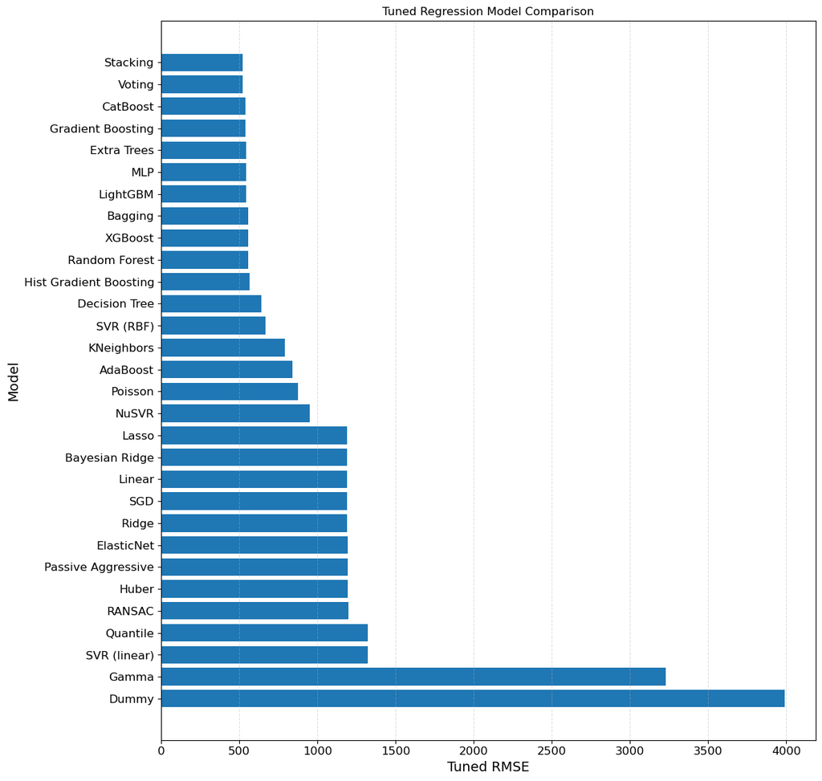

```python
# ============================================================
# Export tuned regression model comparison plot
# ============================================================

model_comparison_plot_df = results_df_sorted.copy()

model_comparison_plot_df = model_comparison_plot_df.dropna(
    subset=["Tun_RMSE"]
).copy()

model_comparison_plot_df["Model_Display"] = (
    model_comparison_plot_df["Model"]
    .astype(str)
    .str.replace(" Regressor", "", regex=False)
)

model_comparison_plot_df = model_comparison_plot_df.sort_values(
    "Tun_RMSE",
    ascending=True
)

plt.figure(figsize=(12, max(7, 0.38 * len(model_comparison_plot_df))))

plt.barh(
    model_comparison_plot_df["Model_Display"][::-1],
    model_comparison_plot_df["Tun_RMSE"][::-1]
)

plt.xlabel("Tuned RMSE")
plt.ylabel("Model")
plt.title("Tuned Regression Model Comparison")
plt.grid(axis="x", linestyle="--", alpha=0.4)
plt.tight_layout()

if SAVE_PORTFOLIO_OUTPUTS:
    plt.savefig(
        REGRESSION_IMAGES_DIR / "supervised_regression_model_comparison.png",
        dpi=FIG_DPI,
        bbox_inches="tight"
    )

plt.show()
```

```python
from sklearn.metrics import root_mean_squared_error, r2_score

best_model_name = results_df_sorted.loc[0, "Model"]
best_y_pred = best_pred_candidates.get(best_model_name)

if best_y_pred is not None:
    print("Best model:", best_model_name)
    print("Best model test RMSE:", root_mean_squared_error(y_test, best_y_pred))
    print("Best model test R2:", r2_score(y_test, best_y_pred))
else:
    print(f"No saved prediction found for: {best_model_name}")
```

```
Best model: Stacking Regressor
Best model test RMSE: 522.4074749766904
Best model test R2: 0.9828545638547189
```

## Prediction Comparison on Selected Test Samples

```python
### Final comparison table for sample predictions

sample_pred_candidates = [
    # Baseline models
    ("Dummy Regressor", "dummy_sample_pred"),

    # Linear / regularized models
    ("Linear Regressor", "lin_sample_pred"),
    ("Ridge Regressor", "ridge_sample_pred"),
    ("Lasso Regressor", "lasso_sample_pred"),
    ("ElasticNet Regressor", "elastic_sample_pred"),
    ("Bayesian Ridge Regressor", "bayes_ridge_sample_pred"),
    ("Quantile Regressor", "quantile_sample_pred"),

    # Robust linear models
    ("Huber Regressor", "huber_sample_pred"),
    ("RANSAC Regressor", "ransac_sample_pred"),

    # Online linear models
    ("SGD Regressor", "sgd_sample_pred"),
    ("Passive Aggressive Regressor", "pa_sample_pred"),

    # GLM / distribution-based linear models
    ("Poisson Regressor", "poisson_sample_pred"),
    ("Gamma Regressor", "gamma_sample_pred"),

    # Kernel / distance-based models
    ("SVR (linear)", "svr_linear_sample_pred"),
    ("SVR (RBF)", "svr_rbf_sample_pred"),
    ("NuSVR Regressor", "nusvr_sample_pred"),
    ("KNeighbors Regressor", "knn_sample_pred"),

    # Tree-based models
    ("Decision Tree Regressor", "dt_sample_pred"),

    # Tree-based ensemble models
    ("Random Forest Regressor", "rf_sample_pred"),
    ("Extra Trees Regressor", "extra_trees_sample_pred"),

    # Boosting ensemble models
    ("AdaBoost Regressor", "ada_sample_pred"),
    ("Gradient Boosting Regressor", "gbr_sample_pred"),
    ("Hist Gradient Boosting Regressor", "hgb_sample_pred"),
    ("XGBoost Regressor", "xgb_sample_pred"),
    ("LightGBM Regressor", "lgbm_sample_pred"),
    ("CatBoost Regressor", "cat_sample_pred"),

    # Neural models
    ("MLP Regressor", "mlp_sample_pred"),

    # Advanced ensemble models
    ("Bagging Regressor", "bagging_sample_pred"),
    ("Voting Regressor", "voting_sample_pred"),
    ("Stacking Regressor", "stacking_sample_pred")
]

comparison_dict = {
    "Original Label": y_test.loc[sample_idx]
}

for model_name, var_name in sample_pred_candidates:
    if var_name in globals():
        comparison_dict[model_name] = pd.Series(globals()[var_name]).reindex(sample_idx)

final_sample_comparison_df = pd.DataFrame(comparison_dict).T

### Reorder comparison table by Tun_RMSE ranking
ordered_models = ["Original Label"] + [
    model_name
    for model_name in results_df_sorted["Model"]
    if model_name in final_sample_comparison_df.index
]

final_sample_comparison_df = final_sample_comparison_df.reindex(ordered_models)
```

```python
sorted_df = final_sample_comparison_df.sort_values("Original Label", axis=1)

label_values = sorted_df.loc["Original Label"]
thresholds = [500, 750, 1000, 2000, 3000, 4000, 5000, 7500, 10000, 12500, 15000, 17500]

selected_cols = []

for threshold in thresholds:
    matching_positions = np.where(label_values.to_numpy() >= threshold)[0]

    if len(matching_positions) > 0:
        start = matching_positions[0]
        selected_cols.extend(sorted_df.columns[start:start+2])

selected_cols = list(dict.fromkeys(selected_cols))  # remove duplicates, keep order

selected_df = sorted_df[selected_cols].copy()

# Remove " Regressor" from index labels
selected_df.index = selected_df.index.str.replace(" Regressor", "", regex=False)

selected_df.style.format("{:.2f}") \
    .set_properties(
        subset=pd.IndexSlice[["Original Label"], :],
        **{"background-color": "#ffd966"}
    ) \
    .map_index(
        lambda v: "background-color: #ffd966; text-align: left; white-space: nowrap;"
        if v == "Original Label"
        else "text-align: left; white-space: nowrap;",
        axis=0
    ) \
    .set_table_styles(
        [
            {
                "selector": "th.row_heading",
                "props": [
                    ("text-align", "left"),
                    ("white-space", "nowrap")
                ]
            }
        ],
        overwrite=False
    )
```

|  | 5872 | 7115 | 4786 | 3903 | 10066 | 9954 | 6963 | 8201 | 726 | 10772 | 4194 | 4446 | 1967 | 3861 | 1038 | 4503 | 10182 | 5305 | 2532 | 5912 | 2950 | 6704 | 9048 | 329 |
| --- | --- | --- | --- | --- | --- | --- | --- | --- | --- | --- | --- | --- | --- | --- | --- | --- | --- | --- | --- | --- | --- | --- | --- | --- |
| Original Label | 500.00 | 500.00 | 750.00 | 750.00 | 1000.00 | 1000.00 | 2000.00 | 2000.00 | 3001.00 | 3001.00 | 4001.00 | 4001.00 | 5000.00 | 5000.00 | 7503.00 | 7504.00 | 10000.00 | 10004.00 | 12500.00 | 12502.00 | 15017.00 | 15030.00 | 17504.00 | 17509.00 |
| Stacking | 514.58 | 594.82 | 798.73 | 919.64 | 1060.06 | 971.49 | 2396.09 | 1528.78 | 3042.09 | 3243.95 | 4387.46 | 3904.71 | 5329.89 | 4769.95 | 7629.48 | 7538.63 | 9593.46 | 9972.90 | 17743.07 | 12615.69 | 16978.51 | 17175.33 | 17287.24 | 16212.88 |
| Voting | 519.89 | 584.62 | 796.47 | 895.76 | 1054.56 | 986.03 | 2363.95 | 1539.18 | 3083.73 | 3249.40 | 4429.76 | 3898.07 | 5381.53 | 4837.08 | 7613.18 | 7463.92 | 9499.86 | 10071.79 | 17720.44 | 12654.85 | 17126.17 | 17140.08 | 17368.99 | 16032.32 |
| CatBoost | 492.91 | 568.39 | 785.84 | 894.60 | 1085.08 | 996.92 | 2244.93 | 1701.76 | 3058.92 | 3290.15 | 4446.97 | 3901.47 | 5420.84 | 5059.76 | 7625.33 | 7668.14 | 9528.13 | 10235.02 | 17765.94 | 12526.20 | 17034.23 | 16810.86 | 17638.16 | 16065.87 |
| Gradient Boosting | 494.79 | 542.49 | 809.33 | 860.93 | 1025.91 | 970.61 | 2346.51 | 1493.76 | 3178.16 | 3351.92 | 4412.94 | 3858.93 | 5462.72 | 4708.77 | 7559.00 | 7537.70 | 9662.76 | 9843.49 | 18769.15 | 12881.56 | 17366.03 | 16983.30 | 17031.04 | 15511.57 |
| Extra Trees | 545.09 | 641.78 | 805.46 | 889.02 | 1038.93 | 1014.85 | 2467.06 | 1462.85 | 3011.07 | 3062.59 | 4344.38 | 3851.96 | 5444.24 | 4757.00 | 7801.34 | 7346.52 | 9364.27 | 10133.31 | 17231.21 | 12800.46 | 16764.65 | 17166.48 | 17556.33 | 16632.49 |
| MLP | 540.56 | 664.31 | 814.87 | 1022.25 | 1108.33 | 949.58 | 2509.14 | 1529.97 | 2927.06 | 3225.90 | 4350.08 | 3972.81 | 5109.61 | 4659.68 | 7624.28 | 7608.00 | 9722.22 | 9767.90 | 17120.90 | 12294.59 | 16541.77 | 17402.52 | 17043.95 | 16548.84 |
| LightGBM | 545.72 | 449.61 | 781.20 | 868.31 | 1059.86 | 1020.40 | 2208.98 | 1530.21 | 3195.40 | 3423.08 | 4448.23 | 3904.48 | 5415.31 | 4962.68 | 7469.05 | 7392.90 | 9495.16 | 10273.71 | 18311.54 | 12679.85 | 17704.60 | 17444.51 | 17478.45 | 15615.66 |
| Bagging | 500.29 | 641.14 | 782.13 | 839.48 | 1009.27 | 963.82 | 2407.06 | 1516.53 | 3131.79 | 3142.78 | 4575.98 | 3898.77 | 5436.44 | 4874.60 | 7600.08 | 7230.25 | 9226.65 | 10177.29 | 17123.91 | 12746.46 | 17345.76 | 17032.80 | 17466.01 | 15819.46 |
| XGBoost | 512.55 | 609.06 | 843.94 | 909.32 | 1039.15 | 991.88 | 2302.22 | 1567.17 | 3092.96 | 3146.49 | 4376.83 | 3880.76 | 5351.58 | 4783.10 | 7301.20 | 7468.68 | 9086.98 | 10250.64 | 17350.14 | 12727.72 | 17544.82 | 16579.54 | 17835.42 | 17503.64 |
| Random Forest | 489.01 | 635.94 | 772.93 | 853.84 | 1013.64 | 959.01 | 2397.25 | 1486.36 | 3098.72 | 3089.63 | 4492.00 | 3899.81 | 5460.35 | 4894.49 | 7510.79 | 7164.21 | 9246.92 | 10100.12 | 16962.01 | 12741.44 | 17294.09 | 17042.17 | 17443.39 | 16314.65 |
| Hist Gradient Boosting | 534.32 | 571.81 | 769.70 | 875.37 | 1057.88 | 996.30 | 2296.44 | 1520.24 | 3200.05 | 3357.97 | 4668.61 | 3855.64 | 5262.60 | 4735.77 | 7476.73 | 7380.83 | 9217.75 | 10208.79 | 16932.17 | 12749.06 | 17801.61 | 16034.81 | 17546.95 | 16771.56 |
| Decision Tree | 497.58 | 648.33 | 833.44 | 938.22 | 1026.83 | 1005.51 | 2642.50 | 1506.80 | 3144.86 | 2991.08 | 4342.10 | 4068.23 | 5395.05 | 4835.03 | 7247.33 | 7024.81 | 8990.91 | 9998.59 | 17808.68 | 12365.85 | 17028.00 | 17057.25 | 17091.10 | 15795.40 |
| SVR (RBF) | 510.97 | 576.57 | 732.62 | 911.51 | 1052.18 | 941.23 | 2231.79 | 1580.13 | 3080.10 | 3190.09 | 4388.21 | 3898.79 | 5419.67 | 5155.14 | 7477.26 | 7474.43 | 10001.22 | 10263.76 | 15391.04 | 12148.48 | 16753.98 | 16634.38 | 18379.99 | 16606.36 |
| KNeighbors | 590.82 | 667.91 | 887.82 | 955.09 | 1047.64 | 1017.45 | 2527.45 | 1617.09 | 3268.36 | 3132.09 | 4471.27 | 3814.18 | 5311.64 | 6370.00 | 7058.91 | 7409.00 | 9680.45 | 10087.55 | 15476.45 | 12390.82 | 17374.18 | 16451.18 | 17053.82 | 14785.55 |
| AdaBoost | 685.90 | 936.78 | 937.89 | 956.74 | 769.31 | 936.52 | 2426.49 | 1936.28 | 4021.11 | 4048.45 | 5825.39 | 5256.33 | 5881.71 | 4111.92 | 8890.08 | 8695.53 | 9594.17 | 10511.97 | 15408.74 | 12454.87 | 15345.61 | 14943.73 | 15740.44 | 15399.36 |
| Poisson | 573.00 | 475.04 | 936.55 | 956.74 | 1205.68 | 983.19 | 2280.37 | 1954.99 | 2400.28 | 2493.60 | 4119.95 | 3889.46 | 5506.60 | 5054.15 | 8443.13 | 8319.22 | 10471.82 | 9968.11 | 20008.08 | 12425.46 | 16332.99 | 18566.02 | 22163.07 | 16651.77 |
| NuSVR | 537.38 | 611.26 | 751.49 | 893.23 | 1113.51 | 994.36 | 2203.20 | 1680.86 | 2544.31 | 2679.61 | 4573.71 | 4000.92 | 5803.52 | 5153.26 | 8730.76 | 8193.30 | 9721.55 | 9716.99 | 12401.12 | 11175.27 | 15282.79 | 15291.51 | 17214.21 | 14146.79 |
| Lasso | -375.23 | -1735.76 | 651.76 | 945.23 | 1669.42 | 1361.04 | 2801.74 | 1946.79 | 2447.58 | 2616.74 | 4974.01 | 4387.38 | 5876.33 | 5466.99 | 8834.93 | 8852.65 | 9958.90 | 8753.58 | 19200.28 | 10629.16 | 14649.51 | 21050.19 | 17891.77 | 14291.64 |
| Bayesian Ridge | -378.21 | -1759.32 | 646.54 | 944.07 | 1690.39 | 1381.18 | 2797.32 | 1941.06 | 2421.96 | 2588.68 | 4947.36 | 4369.47 | 5871.08 | 5484.15 | 8814.36 | 8840.35 | 9954.41 | 8759.14 | 19248.73 | 10651.35 | 14683.77 | 21112.90 | 17927.29 | 14324.69 |
| Linear | -377.82 | -1759.64 | 646.46 | 944.11 | 1690.67 | 1381.49 | 2797.40 | 1940.84 | 2421.33 | 2588.03 | 4946.93 | 4369.24 | 5870.79 | 5484.09 | 8814.01 | 8840.22 | 9954.84 | 8759.18 | 19251.37 | 10651.76 | 14684.93 | 21115.41 | 17928.86 | 14325.81 |
| SGD | -405.12 | -1736.61 | 652.02 | 941.20 | 1670.46 | 1359.95 | 2791.63 | 1955.48 | 2465.52 | 2633.14 | 4976.63 | 4384.75 | 5890.58 | 5488.14 | 8837.51 | 8848.13 | 9924.16 | 8755.81 | 19067.84 | 10622.58 | 14604.64 | 20942.35 | 17820.23 | 14247.73 |
| Ridge | -413.50 | -1727.83 | 654.20 | 940.74 | 1664.45 | 1352.85 | 2790.28 | 1961.37 | 2481.48 | 2649.15 | 4987.89 | 4390.58 | 5897.78 | 5489.88 | 8847.03 | 8852.39 | 9914.46 | 8755.27 | 19007.65 | 10612.35 | 14577.41 | 20882.14 | 17782.09 | 14221.12 |
| ElasticNet | -436.70 | -1704.81 | 659.82 | 938.91 | 1646.55 | 1334.03 | 2785.68 | 1975.16 | 2522.90 | 2690.99 | 5015.93 | 4405.01 | 5916.16 | 5493.18 | 8869.25 | 8860.80 | 9887.26 | 8752.20 | 18848.33 | 10585.40 | 14505.74 | 20726.95 | 17683.76 | 14151.07 |
| Passive Aggressive | -416.18 | -1720.50 | 652.11 | 939.30 | 1654.91 | 1345.71 | 2778.95 | 1953.60 | 2481.84 | 2653.08 | 4980.89 | 4388.80 | 5896.22 | 5478.88 | 8857.14 | 8857.13 | 9903.48 | 8740.37 | 19006.84 | 10603.95 | 14580.61 | 20902.60 | 17788.80 | 14216.20 |
| Huber | -404.71 | -1728.74 | 652.44 | 942.90 | 1665.49 | 1354.41 | 2784.90 | 1954.56 | 2467.64 | 2639.69 | 4980.51 | 4382.13 | 5894.78 | 5478.76 | 8860.35 | 8865.87 | 9924.46 | 8753.84 | 19094.93 | 10618.52 | 14619.40 | 20974.25 | 17840.05 | 14259.54 |
| RANSAC | -223.74 | -1649.50 | 670.05 | 903.88 | 1628.33 | 1399.33 | 2788.69 | 1910.37 | 2437.48 | 2562.43 | 4973.61 | 4365.20 | 5787.74 | 5433.45 | 8891.43 | 8889.65 | 9909.83 | 8634.31 | 19499.85 | 10683.23 | 14798.55 | 21502.19 | 18112.81 | 14399.12 |
| Quantile | 111.80 | -684.02 | 635.91 | 1023.82 | 1170.41 | 1161.58 | 2713.18 | 1721.47 | 2825.16 | 2948.79 | 4910.24 | 4481.76 | 5511.88 | 4622.47 | 8585.25 | 8691.46 | 9671.20 | 7551.31 | 19677.42 | 9991.32 | 14435.52 | 21879.07 | 17790.10 | 13766.25 |
| SVR (linear) | 110.31 | -676.16 | 644.11 | 1024.14 | 1164.70 | 1149.45 | 2710.17 | 1729.34 | 2842.32 | 2961.39 | 4922.96 | 4478.34 | 5504.08 | 4621.57 | 8588.87 | 8666.43 | 9618.01 | 7529.41 | 19458.51 | 9954.64 | 14327.90 | 21695.33 | 17660.02 | 13663.76 |
| Gamma | 2738.00 | 2944.90 | 2919.27 | 2945.32 | 2821.02 | 2927.33 | 3463.84 | 3305.21 | 3944.67 | 3853.26 | 4247.70 | 4096.35 | 4243.58 | 3892.99 | 4901.56 | 4947.43 | 4943.59 | 4476.60 | 6894.97 | 5001.68 | 5916.48 | 7362.31 | 6395.88 | 5598.35 |
| Dummy | 3932.89 | 3932.89 | 3932.89 | 3932.89 | 3932.89 | 3932.89 | 3932.89 | 3932.89 | 3932.89 | 3932.89 | 3932.89 | 3932.89 | 3932.89 | 3932.89 | 3932.89 | 3932.89 | 3932.89 | 3932.89 | 3932.89 | 3932.89 | 3932.89 | 3932.89 | 3932.89 | 3932.89 |

```python
# ============================================================
# Export selected test sample predictions as CSV
# ============================================================

if SAVE_PORTFOLIO_OUTPUTS:
    output_path = REGRESSION_RESULTS_DIR / "supervised_regression_selected_test_sample_predictions.csv"

    selected_test_sample_predictions = selected_df.copy()

    selected_test_sample_predictions.to_csv(
        output_path,
        index=True,
        index_label="Model"
    )

    print("Saved:", output_path)
```

```
Saved: _exports\regression_models\results\supervised_regression_selected_test_sample_predictions.csv
```

### Prediction Comparison for the Best Regression Model

```python
comparison_model_name = results_df_sorted.loc[0, "Model"]   # Default: best model from Tun_RMSE ranking
comparison_model_name = comparison_model_name.replace(" Regressor", "")
# comparison_model_name = "Lasso"                            # Example: change later if needed

original_row = selected_df.loc[["Original Label"]]
model_row = selected_df.loc[[comparison_model_name]]

error_row = (model_row.iloc[0] - original_row.iloc[0]).to_frame().T
error_row.index = ["Discrepancy"]

comparison_df = pd.concat([original_row, model_row, error_row])

comparison_df.style.format("{:.2f}") \
    .set_properties(
        subset=pd.IndexSlice[["Original Label"], :],
        **{"background-color": "#ffd966"}
    ) \
    .map_index(
        lambda v: "background-color: #ffd966" if v == "Original Label" else "",
        axis=0
    ) \
    .set_table_styles(
        [
            {
                "selector": "th.row_heading",
                "props": [
                    ("text-align", "left"),
                    ("white-space", "nowrap")
                ]
            }
        ],
        overwrite=False
    )
```

|  | 5872 | 7115 | 4786 | 3903 | 10066 | 9954 | 6963 | 8201 | 726 | 10772 | 4194 | 4446 | 1967 | 3861 | 1038 | 4503 | 10182 | 5305 | 2532 | 5912 | 2950 | 6704 | 9048 | 329 |
| --- | --- | --- | --- | --- | --- | --- | --- | --- | --- | --- | --- | --- | --- | --- | --- | --- | --- | --- | --- | --- | --- | --- | --- | --- |
| Original Label | 500.00 | 500.00 | 750.00 | 750.00 | 1000.00 | 1000.00 | 2000.00 | 2000.00 | 3001.00 | 3001.00 | 4001.00 | 4001.00 | 5000.00 | 5000.00 | 7503.00 | 7504.00 | 10000.00 | 10004.00 | 12500.00 | 12502.00 | 15017.00 | 15030.00 | 17504.00 | 17509.00 |
| Stacking | 514.58 | 594.82 | 798.73 | 919.64 | 1060.06 | 971.49 | 2396.09 | 1528.78 | 3042.09 | 3243.95 | 4387.46 | 3904.71 | 5329.89 | 4769.95 | 7629.48 | 7538.63 | 9593.46 | 9972.90 | 17743.07 | 12615.69 | 16978.51 | 17175.33 | 17287.24 | 16212.88 |
| Discrepancy | 14.58 | 94.82 | 48.73 | 169.64 | 60.06 | -28.51 | 396.09 | -471.22 | 41.09 | 242.95 | 386.46 | -96.29 | 329.89 | -230.05 | 126.48 | 34.63 | -406.54 | -31.10 | 5243.07 | 113.69 | 1961.51 | 2145.33 | -216.76 | -1296.12 |

## Prediction range and difference summary

```python
# This summary is based on final_sample_comparison_df.
# final_sample_comparison_df contains tuned/best model predictions for the selected test samples.
# Dummy and plain Linear Regression are included as non-tuned baseline/reference models.

# --- 1) Calculate diff_df ---
diff_df = final_sample_comparison_df.sub(
    final_sample_comparison_df.loc["Original Label"],
    axis=1
)

# --- 2) Min and Max values ---
min_values = final_sample_comparison_df.T.min()
max_values = final_sample_comparison_df.T.max()

# --- 3) Basic min-max summary DF ---
min_max_summary_df = pd.DataFrame({
    "Min_Value": min_values,
    "Max_Value": max_values
})

# --- 4) Range calculation ---
min_max_summary_df["Range"] = (
    min_max_summary_df["Max_Value"] - min_max_summary_df["Min_Value"]
)

# --- 5) Max and average negative / positive deviations ---
min_max_summary_df["Max_Neg_Diff"] = diff_df.where(diff_df < 0).min(axis=1)
min_max_summary_df["Avg_Neg_Diff"] = diff_df.where(diff_df < 0).mean(axis=1)

min_max_summary_df["Max_Pos_Diff"] = diff_df.where(diff_df > 0).max(axis=1)
min_max_summary_df["Avg_Pos_Diff"] = diff_df.where(diff_df > 0).mean(axis=1)

# Fixing the Original Label row
min_max_summary_df.loc["Original Label", "Max_Neg_Diff"] = 0
min_max_summary_df.loc["Original Label", "Avg_Neg_Diff"] = 0
min_max_summary_df.loc["Original Label", "Max_Pos_Diff"] = 0
min_max_summary_df.loc["Original Label", "Avg_Pos_Diff"] = 0

# Optional: if a model has no negative or no positive deviations at all
min_max_summary_df[["Max_Neg_Diff", "Avg_Neg_Diff", "Max_Pos_Diff", "Avg_Pos_Diff"]] = (
    min_max_summary_df[["Max_Neg_Diff", "Avg_Neg_Diff", "Max_Pos_Diff", "Avg_Pos_Diff"]].fillna(0)
)

# --- 6) Assigning model_type with map() ---
model_type_map = (
    results_df_with_total[["Model", "Model_type"]]
    .assign(Model=lambda df: df["Model"].str.replace(" Regressor", "", regex=False))
    .drop_duplicates(subset="Model")
    .set_index("Model")["Model_type"]
)

min_max_summary_df.index = min_max_summary_df.index.str.replace(" Regressor", "", regex=False)

min_max_summary_df.insert(
    0,
    "Model_type",
    min_max_summary_df.index.map(model_type_map)
)

# Empty the Model_type field of the Original Label row.
min_max_summary_df.loc["Original Label", "Model_type"] = ""
```

```python
# --- 7) Stylized display ---

numeric_cols = min_max_summary_df.select_dtypes(include=["float", "int"]).columns

styled_output = (
    min_max_summary_df.style
        .format(
            {col: "{:.2f}" for col in numeric_cols},
            na_rep="—"
        )

        # Model type column
        .set_properties(
            subset=pd.IndexSlice[:, ["Model_type"]],
            **{
                "text-align": "left",
                "white-space": "nowrap",
                "background-color": "#eeeeee",
                "font-weight": "bold"
            }
        )

        # Min / Max value columns
        .set_properties(
            subset=pd.IndexSlice[:, ["Min_Value", "Max_Value"]],
            **{
                "background-color": "#f3f3f3",
                "text-align": "right"
            }
        )

        # Range column
        .set_properties(
            subset=pd.IndexSlice[:, ["Range"]],
            **{
                "background-color": "#e8f1ff",
                "text-align": "right",
                "font-weight": "bold"
            }
        )

        # Negative deviation columns
        .set_properties(
            subset=pd.IndexSlice[:, ["Max_Neg_Diff", "Avg_Neg_Diff"]],
            **{
                "background-color": "#f8e6e6",
                "text-align": "right"
            }
        )

        # Positive deviation columns
        .set_properties(
            subset=pd.IndexSlice[:, ["Max_Pos_Diff", "Avg_Pos_Diff"]],
            **{
                "background-color": "#e5fddb",
                "text-align": "right"
            }
        )

        # Original Label reference row
        .set_properties(
            subset=pd.IndexSlice[["Original Label"], :],
            **{
                "background-color": "#ffd966",
                "font-weight": "bold"
            }
        )

        # Row index styling
        .map_index(
            lambda v: (
                "background-color: #ffd966; "
                "font-weight: bold; "
                "text-align: left; "
                "white-space: nowrap;"
            )
            if v == "Original Label"
            else (
                "text-align: left; "
                "white-space: nowrap;"
            ),
            axis=0
        )

        # Table style
        .set_table_styles(
            [
                {
                    "selector": "th.row_heading",
                    "props": [
                        ("text-align", "left"),
                        ("white-space", "nowrap")
                    ]
                },
                {
                    "selector": "th.col_heading",
                    "props": [
                        ("text-align", "left"),
                        ("white-space", "nowrap")
                    ]
                },
                {
                    "selector": "th, td",
                    "props": [
                        ("border", "1px solid #d0d0d0"),
                        ("padding", "6px 8px")
                    ]
                },
                {
                    "selector": "table",
                    "props": [
                        ("border-collapse", "collapse")
                    ]
                },
                {
                    "selector": "tbody tr:nth-child(even) td",
                    "props": [
                        ("filter", "brightness(0.97)")
                    ]
                },
                {
                    "selector": "tbody tr:hover td",
                    "props": [
                        ("filter", "brightness(0.90)")
                    ]
                }
            ],
            overwrite=False
        )
)

styled_output
```

|  | Model_type | Min_Value | Max_Value | Range | Max_Neg_Diff | Avg_Neg_Diff | Max_Pos_Diff | Avg_Pos_Diff |
| --- | --- | --- | --- | --- | --- | --- | --- | --- |
| Original Label |  | 326.00 | 18818.00 | 18492.00 | 0.00 | 0.00 | 0.00 | 0.00 |
| Stacking | Advanced ensemble | 285.75 | 18058.28 | 17772.53 | -6428.21 | -264.97 | 5395.78 | 264.37 |
| Voting | Advanced ensemble | 330.72 | 18058.13 | 17727.41 | -6371.67 | -272.43 | 5220.44 | 256.19 |
| CatBoost | Boosting ensemble | 306.44 | 19052.58 | 18746.13 | -7190.62 | -284.20 | 5265.94 | 267.34 |
| Gradient Boosting | Boosting ensemble | 293.70 | 18769.15 | 18475.46 | -6645.99 | -271.92 | 6269.15 | 268.63 |
| Extra Trees | Tree-based ensemble | 369.39 | 18197.95 | 17828.56 | -6309.59 | -280.00 | 5246.35 | 269.11 |
| MLP | Neural | -135.71 | 17501.55 | 17637.27 | -6527.76 | -295.32 | 7546.78 | 279.68 |
| LightGBM | Boosting ensemble | 309.16 | 18311.54 | 18002.38 | -6035.83 | -290.38 | 8426.61 | 271.00 |
| Bagging | Advanced ensemble | 373.55 | 17943.50 | 17569.95 | -6441.34 | -276.74 | 5197.97 | 275.98 |
| XGBoost | Boosting ensemble | 337.34 | 19375.97 | 19038.63 | -7742.23 | -294.96 | 9182.61 | 267.90 |
| Random Forest | Tree-based ensemble | 374.93 | 17960.65 | 17585.72 | -6364.62 | -280.43 | 5095.91 | 277.35 |
| Hist Gradient Boosting | Boosting ensemble | 416.36 | 18028.92 | 17612.56 | -6342.00 | -299.30 | 12092.65 | 274.51 |
| Decision Tree | Tree-based | 361.00 | 18322.60 | 17961.60 | -5995.15 | -333.59 | 5714.70 | 325.88 |
| SVR (RBF) | Kernel / Distance-based | 300.12 | 19695.45 | 19395.33 | -12011.55 | -316.53 | 5046.97 | 320.53 |
| KNeighbors | Kernel / Distance-based | 412.91 | 17622.45 | 17209.55 | -11516.73 | -431.36 | 8586.27 | 342.67 |
| AdaBoost | Boosting ensemble | 685.89 | 17015.70 | 16329.81 | -6542.08 | -520.06 | 10390.75 | 557.15 |
| Poisson | GLM / distribution-based linear | 0.71 | 30590.95 | 30590.24 | -13687.25 | -520.12 | 13444.95 | 390.92 |
| NuSVR | Kernel / Distance-based | 399.14 | 17393.45 | 16994.31 | -12806.44 | -543.86 | 8421.90 | 356.56 |
| Lasso | Linear / regularized | -3491.08 | 39968.71 | 43459.79 | -10774.33 | -921.34 | 21950.71 | 637.35 |
| Bayesian Ridge | Linear / regularized | -3617.51 | 40086.40 | 43703.91 | -10736.31 | -921.35 | 22068.40 | 640.01 |
| Linear | Linear / regularized | -3621.64 | 40091.31 | 43712.96 | -10735.91 | -921.35 | 22073.31 | 640.01 |
| SGD | Online linear | -3342.36 | 39745.78 | 43088.14 | -10764.21 | -923.23 | 21727.78 | 638.88 |
| Ridge | Linear / regularized | -3250.28 | 39627.74 | 42878.02 | -10774.00 | -926.80 | 21609.74 | 637.63 |
| ElasticNet | Linear / regularized | -3211.06 | 39312.82 | 42523.87 | -10800.46 | -926.15 | 21294.82 | 639.03 |
| Passive Aggressive | Online linear | -3228.95 | 39784.81 | 43013.76 | -10809.06 | -922.25 | 21766.81 | 635.47 |
| Huber | Robust linear | -3244.22 | 40064.47 | 43308.69 | -10810.41 | -917.28 | 22046.47 | 639.17 |
| RANSAC | Robust linear | -3392.07 | 41405.69 | 44797.77 | -10959.46 | -909.57 | 23387.69 | 630.93 |
| Quantile | Linear / quantile | -12784.01 | 43691.17 | 56475.18 | -14859.01 | -846.41 | 25673.17 | 473.46 |
| SVR (linear) | Kernel / Distance-based | -12012.12 | 43289.15 | 55301.27 | -14087.12 | -853.24 | 25271.15 | 467.03 |
| Gamma | GLM / distribution-based linear | 1664.16 | 13196.77 | 11532.61 | -14400.69 | -3542.47 | 11121.77 | 1599.92 |
| Dummy | Baseline | 3932.89 | 3932.89 | 0.00 | -14885.11 | -4161.87 | 3606.89 | 2384.75 |

```python
# ============================================================
# Export prediction range and difference summary
# ============================================================

prediction_range_difference_summary = min_max_summary_df.copy()

if SAVE_PORTFOLIO_OUTPUTS:
    prediction_range_difference_summary.to_csv(
        REGRESSION_RESULTS_DIR / "supervised_regression_prediction_range_difference_summary.csv",
        index=True
    )

    print(
        "Saved:",
        REGRESSION_RESULTS_DIR / "supervised_regression_prediction_range_difference_summary.csv"
    )
```

```
Saved: _exports\regression_models\results\supervised_regression_prediction_range_difference_summary.csv
```

## Best Model Performance by Price Range

```python
# Number of bins
price_bins = 500

# Maximum price
price_max = 19000

# Label of each bin
# Size of each bin on StratifiedShuffleSplit
price_cat_size = 1500
```

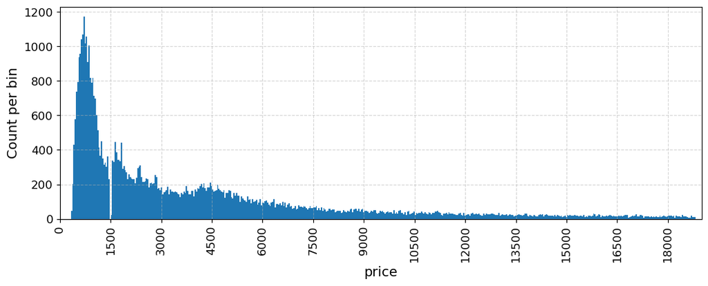

```python
# Plot "price"
diamonds[target_column].hist(bins=price_bins, figsize=(12, 4))

plt.xlim(0, price_max)
plt.xticks(np.arange(0, price_max + 1, price_cat_size), rotation=90)

plt.xlabel(target_column)
plt.ylabel("Count per bin")
plt.grid(True, linestyle="--", alpha=0.5)
plt.show()
```

```python
diamonds["target_cat"] = pd.cut(
    diamonds[target_column],
    bins=np.arange(0, price_max + 1, price_cat_size),
    labels=np.arange(price_cat_size, price_max + 1, price_cat_size),
    include_lowest=True
)
```

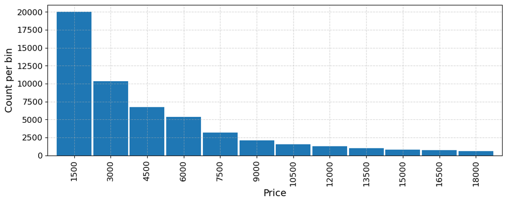

```python
diamonds["target_cat"].value_counts().sort_index().plot.bar(
    figsize=(12, 4),
    width=0.95
)
plt.xlabel("Price")
plt.ylabel("Count per bin")
plt.grid(True, linestyle="--", alpha=0.5)
plt.show()
```

```python
# Create tuned models table only from variables that already exist
TUNED_MODELS = {}

model_candidates = [
    # Baseline models
    ("Dummy Regressor", "dummy_reg"),

    # Linear / regularized models
    ("Linear Regressor", "lin_reg"),
    ("Ridge Regressor", "ridge_best_tuning"),
    ("Lasso Regressor", "lasso_best_tuning"),
    ("ElasticNet Regressor", "elastic_best_tuning"),
    ("Bayesian Ridge Regressor", "bayes_ridge_best_tuning"),
    ("Quantile Regressor", "quantile_best_tuning"),

    # Robust linear models
    ("Huber Regressor", "huber_best_tuning"),
    ("RANSAC Regressor", "ransac_best_tuning"),

    # Online linear models
    ("SGD Regressor", "sgd_best_tuning"),
    ("Passive Aggressive Regressor", "pa_best_tuning"),

    # GLM / distribution-based linear models
    ("Poisson Regressor", "poisson_best_tuning"),
    ("Gamma Regressor", "gamma_best_tuning"),

    # SVR / distance-based models
    ("SVR (linear)", "svr_linear_best_tuning"),
    ("SVR (RBF)", "svr_rbf_best_tuning"),
    ("KNeighbors Regressor", "knn_best_tuning"),
    ("NuSVR Regressor", "nusvr_best_tuning"),

    # Tree-based models
    ("Decision Tree Regressor", "dt_best_tuning"),

    # Tree-based ensemble models
    ("Random Forest Regressor", "rf_best_tuning"),
    ("Extra Trees Regressor", "extra_trees_best_tuning"),

    # Boosting ensemble models
    ("AdaBoost Regressor", "ada_best_tuning"),
    ("Gradient Boosting Regressor", "gbr_best_tuning"),
    ("Hist Gradient Boosting Regressor", "hgb_best_tuning"),
    ("XGBoost Regressor", "xgb_best_tuning"),
    ("LightGBM Regressor", "lgbm_best_tuning"),
    ("CatBoost Regressor", "cat_best_tuning"),

    # Neural models
    ("MLP Regressor", "mlp_best_tuning"),

    # Advanced ensemble models
    ("Bagging Regressor", "bagging_best_tuning"),
    ("Voting Regressor", "voting_best_tuning"),
    ("Stacking Regressor", "stacking_best_tuning")
]

for model_name, var_name in model_candidates:
    if var_name in globals():
        TUNED_MODELS[model_name] = globals()[var_name]

best_model = TUNED_MODELS[best_model_name]
```

```python
import pandas as pd
import numpy as np
from sklearn.metrics import mean_absolute_error, root_mean_squared_error

best_y_pred = best_model.predict(X_test)

range_eval_df = pd.DataFrame({
    "actual": y_test,
    "predicted": best_y_pred
}).copy()

range_eval_df = range_eval_df.reset_index(drop=True)

actual_price_max = int(diamonds[target_column].max())

bin_edges = np.arange(0, price_max + price_cat_size, price_cat_size)

bin_labels = [
    f"{bin_edges[i]}-{bin_edges[i+1]}"
    for i in range(len(bin_edges) - 2)
] + [
    f"{bin_edges[-2]}-{actual_price_max}"
]

range_eval_df["target_cat"] = pd.cut(
    range_eval_df["actual"],
    bins=bin_edges,
    labels=bin_labels,
    include_lowest=True,
    right=True
)

# Remove unused empty categories
range_eval_df["target_cat"] = range_eval_df["target_cat"].cat.remove_unused_categories()

# Row-level percentage errors
range_eval_df["abs_pct_error"] = (
    np.abs(range_eval_df["predicted"] - range_eval_df["actual"])
    / range_eval_df["actual"] * 100
)

range_eval_df["signed_pct_error"] = (
    (range_eval_df["predicted"] - range_eval_df["actual"])
    / range_eval_df["actual"] * 100
)

def calculate_range_metrics(group):
    y_true = group["actual"]
    y_pred = group["predicted"]

    mean_actual = y_true.mean()
    mean_predicted = y_pred.mean()
    mean_bias = (y_pred - y_true).mean()
    mae = mean_absolute_error(y_true, y_pred)
    rmse = root_mean_squared_error(y_true, y_pred)

    mae_pct = (mae / mean_actual * 100) if mean_actual != 0 else np.nan
    rmse_pct = (rmse / mean_actual * 100) if mean_actual != 0 else np.nan

    mape = group["abs_pct_error"].mean()
    mean_relative_error_pct = group["signed_pct_error"].mean()

    return pd.Series({
        "count": len(group),
        "mean_actual": mean_actual,
        "mean_predicted": mean_predicted,
        "mean_bias": mean_bias,
        "MAE": mae,
        "RMSE": rmse,
        "MAE_pct": mae_pct,
        "RMSE_pct": rmse_pct,
        "MAPE_pct": mape,
        "mean_relative_error_pct": mean_relative_error_pct
    })

range_metrics_df = (
    range_eval_df
    .dropna(subset=["target_cat"])
    .groupby("target_cat", observed=True)
    .apply(calculate_range_metrics)
    .reset_index()
)

range_metrics_df
```

|  | target_cat | count | mean_actual | mean_predicted | mean_bias | MAE | RMSE | MAE_pct | RMSE_pct | MAPE_pct | mean_relative_error_pct |
| --- | --- | --- | --- | --- | --- | --- | --- | --- | --- | --- | --- |
| 0 | 0-1500 | 4002.00 | 841.46 | 846.38 | 4.92 | 61.05 | 81.10 | 7.25 | 9.64 | 7.37 | 1.01 |
| 1 | 1500-3000 | 2065.00 | 2185.42 | 2213.90 | 28.48 | 142.86 | 232.15 | 6.54 | 10.62 | 6.46 | 1.27 |
| 2 | 3000-4500 | 1340.00 | 3774.41 | 3843.90 | 69.49 | 267.86 | 376.99 | 7.10 | 9.99 | 7.13 | 1.82 |
| 3 | 4500-6000 | 1071.00 | 5166.04 | 5175.51 | 9.46 | 325.95 | 470.74 | 6.31 | 9.11 | 6.28 | 0.20 |
| 4 | 6000-7500 | 633.00 | 6691.58 | 6736.58 | 45.00 | 450.84 | 681.95 | 6.74 | 10.19 | 6.76 | 0.72 |
| 5 | 7500-9000 | 417.00 | 8216.30 | 8265.90 | 49.60 | 499.39 | 727.78 | 6.08 | 8.86 | 6.10 | 0.61 |
| 6 | 9000-10500 | 313.00 | 9709.33 | 9742.84 | 33.51 | 682.47 | 968.96 | 7.03 | 9.98 | 7.03 | 0.36 |
| 7 | 10500-12000 | 254.00 | 11211.44 | 11241.73 | 30.28 | 728.98 | 1095.13 | 6.50 | 9.77 | 6.50 | 0.26 |
| 8 | 12000-13500 | 201.00 | 12733.15 | 13165.56 | 432.40 | 1104.42 | 1520.21 | 8.67 | 11.94 | 8.68 | 3.41 |
| 9 | 13500-15000 | 161.00 | 14201.34 | 14260.36 | 59.02 | 841.52 | 1123.02 | 5.93 | 7.91 | 5.92 | 0.41 |
| 10 | 15000-16500 | 145.00 | 15747.39 | 15391.24 | -356.15 | 816.10 | 1041.52 | 5.18 | 6.61 | 5.17 | -2.20 |
| 11 | 16500-18000 | 124.00 | 17212.06 | 16165.40 | -1046.66 | 1074.32 | 1275.49 | 6.24 | 7.41 | 6.23 | -6.07 |
| 12 | 18000-18823 | 62.00 | 18385.98 | 16669.15 | -1716.83 | 1716.83 | 1961.04 | 9.34 | 10.67 | 9.31 | -9.31 |

```python
# ============================================================
# Export best model performance by price range as CSV
# ============================================================

if SAVE_PORTFOLIO_OUTPUTS:
    output_path = REGRESSION_RESULTS_DIR / "supervised_regression_best_model_performance_by_price_range.csv"

    best_model_performance_by_price_range = range_metrics_df.copy()

    best_model_performance_by_price_range.to_csv(
        output_path,
        index=False
    )

    print("Saved:", output_path)
```

```
Saved: _exports\regression_models\results\supervised_regression_best_model_performance_by_price_range.csv
```

## High-Value Prediction Performance

```python
high_value_mask = y_test > 16000
print("Best Model:", best_model_name)
print("RMSE for high values:", root_mean_squared_error(y_test[high_value_mask], best_y_pred[high_value_mask]))
print("Mean true high value:", y_test[high_value_mask].mean())
print("Mean pred high value:", best_y_pred[high_value_mask].mean())
```

```
Best Model: Stacking Regressor
RMSE for high values: 1487.6193364562034
Mean true high value: 17363.684210526317
Mean pred high value: 16172.427284286647
```

## Actual vs Predicted Price Distributions by Model Group

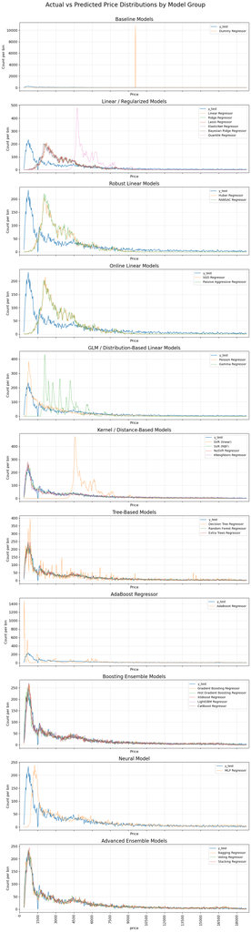

```python
# Calculate bin counts for the true target values
counts_y_test, bin_edges = np.histogram(y_test, bins=price_bins)

# Calculate bin centers for the plot x-axis
bin_centers = (bin_edges[:-1] + bin_edges[1:]) / 2

# Define model groups
model_groups = {
    "Baseline Models": [
        ("dummy_pred_test", "Dummy Regressor"),
    ],
    "Linear / Regularized Models": [
        ("lin_pred_test", "Linear Regressor"),
        ("ridge_best_pred_test", "Ridge Regressor"),
        ("lasso_best_pred_test", "Lasso Regressor"),
        ("elastic_best_pred_test", "ElasticNet Regressor"),
        ("bayes_ridge_best_pred_test", "Bayesian Ridge Regressor"),
        ("quantile_best_pred_test", "Quantile Regressor"),
    ],
    "Robust Linear Models": [
        ("huber_best_pred_test", "Huber Regressor"),
        ("ransac_best_pred_test", "RANSAC Regressor"),
    ],
    "Online Linear Models": [
        ("sgd_best_pred_test", "SGD Regressor"),
        ("pa_best_pred_test", "Passive Aggressive Regressor"),
    ],
    "GLM / Distribution-Based Linear Models": [
        ("poisson_best_pred_test", "Poisson Regressor"),
        ("gamma_best_pred_test", "Gamma Regressor"),
    ],
    "Kernel / Distance-Based Models": [
        ("svr_linear_best_pred_test", "SVR (linear)"),
        ("svr_rbf_best_pred_test", "SVR (RBF)"),
        ("nusvr_best_pred_test", "NuSVR Regressor"),
        ("knn_best_pred_test", "KNeighbors Regressor"),
    ],
    "Tree-Based Models": [
        ("dt_best_pred_test", "Decision Tree Regressor"),
        ("rf_best_pred_test", "Random Forest Regressor"),
        ("extra_trees_best_pred_test", "Extra Trees Regressor"),
    ],
    "AdaBoost Regressor": [
        ("ada_best_pred_test", "AdaBoost Regressor"),
    ],
    "Boosting Ensemble Models": [
        ("gbr_best_pred_test", "Gradient Boosting Regressor"),
        ("hgb_best_pred_test", "Hist Gradient Boosting Regressor"),
        ("xgb_best_pred_test", "XGBoost Regressor"),
        ("lgbm_best_pred_test", "LightGBM Regressor"),
        ("cat_best_pred_test", "CatBoost Regressor"),
    ],
    "Neural Model": [
        ("mlp_best_pred_test", "MLP Regressor"),
    ],
    "Advanced Ensemble Models": [
        ("bagging_best_pred_test", "Bagging Regressor"),
        ("voting_best_pred_test", "Voting Regressor"),
        ("stacking_best_pred_test", "Stacking Regressor"),
    ],
}

# Keep only groups that contain at least one existing prediction variable
available_groups = {}

for group_name, models in model_groups.items():
    existing_models = []
    for var_name, label in models:
        if var_name in globals() and globals()[var_name] is not None:
            existing_models.append((var_name, label))
    if existing_models:
        available_groups[group_name] = existing_models

# Create subplots only for groups that have available variables
n_groups = len(available_groups)

if n_groups == 0:
    print("No prediction variables were found.")
else:
    fig, axes = plt.subplots(n_groups, 1, figsize=(12, 4 * n_groups), sharex=True)

    # If only one subplot exists, convert axes to a list
    if n_groups == 1:
        axes = [axes]

    # Plot each model group
    for ax, (group_name, models) in zip(axes, available_groups.items()):
        # Plot the true target distribution
        ax.plot(bin_centers, counts_y_test, label="y_test", linewidth=1.2)

        # Plot each available model in the current group
        for var_name, label in models:
            counts_pred, _ = np.histogram(globals()[var_name], bins=price_bins)
            ax.plot(bin_centers, counts_pred, label=label, linewidth=0.6)

        ax.set_title(group_name, fontsize=16)
        ax.set_xlim(0, price_max)
        ax.set_ylabel("Count per bin", fontsize=12)
        ax.set_xlabel("Price", fontsize=12)
        ax.grid(True, linestyle="--", alpha=0.5)
        ax.legend()

    # Format the shared x-axis
    axes[-1].set_xticks(np.arange(0, price_max + 1, price_cat_size))
    axes[-1].tick_params(axis="x", rotation=90)
    axes[-1].set_xlabel(target_column)

    plt.suptitle("Actual vs Predicted Price Distributions by Model Group", fontsize=20, y=1.003)
    plt.tight_layout()

    if SAVE_PORTFOLIO_OUTPUTS:
        fig.savefig(
            REGRESSION_IMAGES_DIR / "supervised_regression_actual_vs_predicted_distributions_by_model_group.png",
            dpi=FIG_DPI,
            bbox_inches="tight"
        )

    plt.show()
```

## Prediction Error Analysis

### Actual vs Predicted Values for the Best Regression Model

**This plot shows how close the model’s predictions are to the real values.**

- The closer the points are to the diagonal line, the better the model.
- If the points spread out more at higher values, the model performs worse there.

```python
best_prediction_errors = best_y_pred - y_test

top_model_names = [
    model_name
    for model_name in results_df_sorted["Model"]
    if model_name in best_pred_candidates and best_pred_candidates[model_name] is not None
]
```

```python
import math

model_numbers = len(results_df_with_total) - 1
plt_columns = 4
plt_rows = math.ceil(model_numbers / plt_columns)
figsize_width = 15
figsize_height = plt_rows * (23 / 7)
```

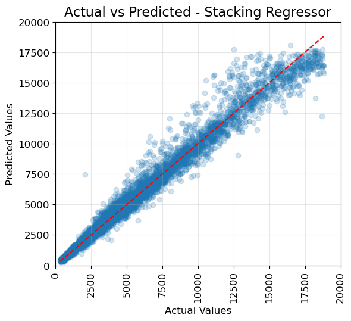

```python
plt.figure(figsize=(6, 5.5))
plt.scatter(y_test, best_y_pred, alpha=0.2)
plt.plot(
    [y_test.min(), y_test.max()],
    [y_test.min(), y_test.max()],
    linestyle="--",
    color='red'
)
plt.title(f"Actual vs Predicted - {best_model_name}", fontsize=16, y=1.003)
plt.xlabel("Actual Values", fontsize=12)
plt.ylabel("Predicted Values", fontsize=12)
plt.grid(alpha=0.3)
plt.xticks(np.linspace(0, 20000, 9))
plt.yticks(np.linspace(0, 20000, 9))
plt.tick_params(axis="x", labelrotation=90)
plt.ylim([0, 20000])
plt.xlim([0, 20000])
plt.tight_layout()


if SAVE_PORTFOLIO_OUTPUTS:
    plt.savefig(
        REGRESSION_IMAGES_DIR / "supervised_regression_actual_vs_predicted_best_model.png",
        dpi=FIG_DPI,
        bbox_inches="tight"
    )

plt.show()
```

### Actual vs Predicted Values for All Tuned Regression Models

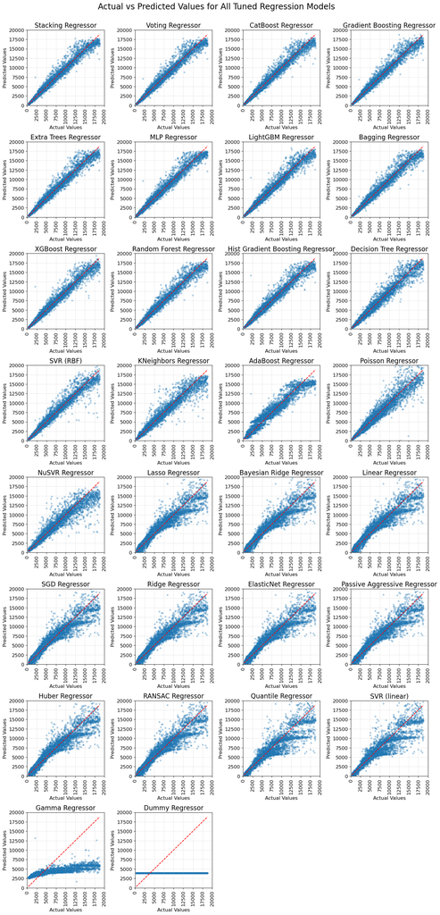

```python
#fig, axes = plt.subplots(7, 4, figsize=(15, 25))
fig, axes = plt.subplots(plt_rows, plt_columns, figsize=(figsize_width, figsize_height+5))
axes = axes.ravel()

for ax, model_name in zip(axes, top_model_names):
    y_pred = best_pred_candidates[model_name]

    ax.scatter(y_test, y_pred, alpha=0.3, s=12)
    ax.plot(
        [y_test.min(), y_test.max()],
        [y_test.min(), y_test.max()],
        linestyle="--",
        color='red'
    )

    ax.set_title(model_name, fontsize=16)
    ax.set_xlabel("Actual Values", fontsize=12)
    ax.set_ylabel("Predicted Values", fontsize=12)
    ax.grid(alpha=0.3)
    ax.set_xticks(np.linspace(0, 20000, 9))
    ax.set_yticks(np.linspace(0, 20000, 9))
    ax.tick_params(axis="x", labelrotation=90)
    ax.set_ylim([0, 20000])
    ax.set_xlim([0, 20000])

for ax in axes[len(top_model_names):]:
    ax.axis("off")

plt.suptitle("Actual vs Predicted Values for All Tuned Regression Models", fontsize=20, y=1.003)
plt.tight_layout()

if SAVE_PORTFOLIO_OUTPUTS:
    fig.savefig(
        REGRESSION_IMAGES_DIR / "supervised_regression_actual_vs_predicted_all_models.png",
        dpi=FIG_DPI,
        bbox_inches="tight"
    )

plt.show()
```

### Residual Plot for the Best Regression Model

**This plot shows the errors made by the model.**

- In a good case, the points are randomly scattered around 0.
- If a visible pattern appears, the model is not capturing something well.

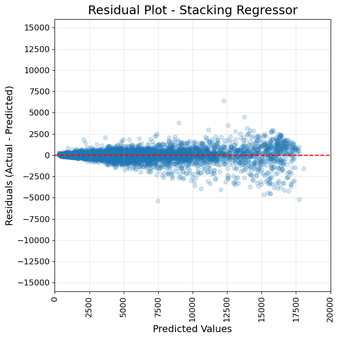

```python
# Classical residual definition:
# residual = actual - predicted
best_residuals = y_test - best_y_pred

plt.figure(figsize=(7, 7))

plt.scatter(
    best_y_pred,
    best_residuals,
    alpha=0.2
)

plt.axhline(y=0, linestyle="--", color="red")

plt.title(f"Residual Plot - {best_model_name}", fontsize=18, y=1.003)
plt.xlabel("Predicted Values", fontsize=14)
plt.ylabel("Residuals (Actual - Predicted)", fontsize=14)
plt.xlim([0, 20000])
plt.ylim([-16000, 16000])
plt.xticks(np.linspace(0, 20000, 9))
plt.yticks(np.linspace(-15000, 15000, 13))
plt.tick_params(axis="x", labelrotation=90)

plt.grid(alpha=0.3)
plt.tight_layout()

if SAVE_PORTFOLIO_OUTPUTS:
    plt.savefig(
        REGRESSION_IMAGES_DIR / "supervised_regression_residuals_best_model.png",
        dpi=FIG_DPI,
        bbox_inches="tight"
    )

plt.show()
```

### Residual Plots for All Tuned Regression Models

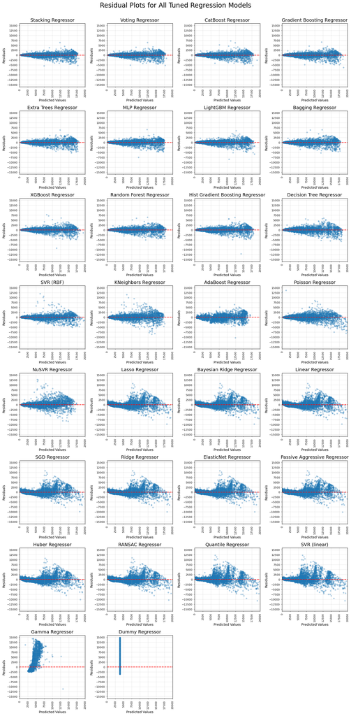

```python
fig, axes = plt.subplots(plt_rows, plt_columns, figsize=(figsize_width, figsize_height * 1.15))
axes = axes.ravel()

for ax, model_name in zip(axes, top_model_names):
    y_pred = best_pred_candidates[model_name]

    # Classical residual definition:
    # residual = actual - predicted
    model_residuals = y_test - y_pred

    ax.scatter(y_pred, model_residuals, alpha=0.3, s=12)
    ax.axhline(y=0, linestyle="--", color="red")

    ax.set_title(model_name, fontsize=14)
    ax.tick_params(axis="both", labelsize=8, length=3, width=0.4)
    ax.set_xlabel("Predicted Values", fontsize=10)
    ax.set_ylabel("Residuals", fontsize=10)
    ax.set_ylim(-16000, 16000)
    ax.set_xlim(0, 20000)
    ax.set_xticks(np.linspace(0, 20000, 9))
    ax.set_yticks(np.linspace(-15000, 15000, 13))
    ax.tick_params(axis="x", labelrotation=90)
    ax.grid(alpha=0.3)

for ax in axes[len(top_model_names):]:
    ax.axis("off")

plt.suptitle("Residual Plots for All Tuned Regression Models", fontsize=20, y=1.003)
plt.tight_layout()

if SAVE_PORTFOLIO_OUTPUTS:
    fig.savefig(
        REGRESSION_IMAGES_DIR / "supervised_regression_residuals_all_models.png",
        dpi=FIG_DPI,
        bbox_inches="tight"
    )

plt.show()
```

### Residual Distribution for the Best Regression Model

**This plot shows how often small or large errors happen.**

- In a good case, the values are centered around 0.
- If the distribution is very skewed or very wide, that is an interesting sign.

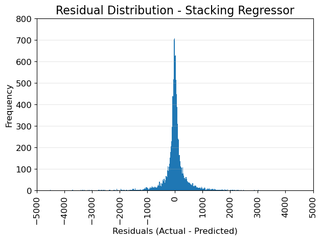

```python
# Classical residual definition:
# residual = actual - predicted
best_residuals = y_test - best_y_pred

bin_edges = np.linspace(-5000, 5000, 500)

plt.hist(best_residuals, bins=bin_edges)

plt.title(f"Residual Distribution - {best_model_name}", fontsize=16, y=1.003)
plt.xlabel("Residuals (Actual - Predicted)", fontsize=12)
plt.ylabel("Frequency", fontsize=12)
plt.ylim([0, 800])
plt.xlim([-5000, 5000])
plt.yticks(np.linspace(0, 800, 9))
plt.xticks(np.linspace(-5000, 5000, 11))
plt.tick_params(axis="x", labelrotation=90)

plt.grid(axis="y", alpha=0.3)
plt.tight_layout()

if SAVE_PORTFOLIO_OUTPUTS:
    plt.savefig(
        REGRESSION_IMAGES_DIR / "supervised_regression_error_distribution_best_model.png",
        dpi=FIG_DPI,
        bbox_inches="tight"
    )

plt.show()
```

### Residual Distributions for All Tuned Regression Models

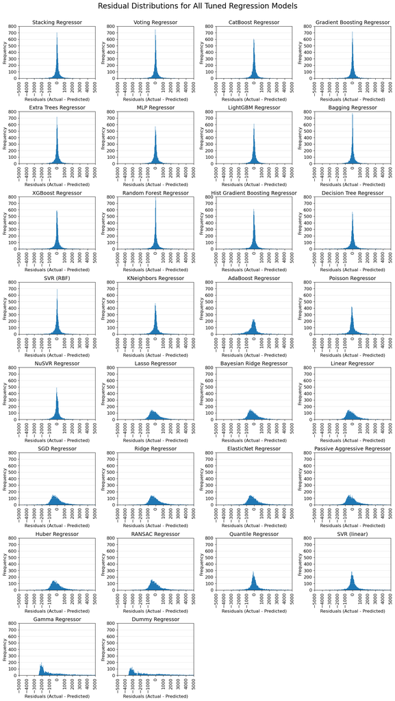

```python
fig, axes = plt.subplots(plt_rows, plt_columns, figsize=(figsize_width, figsize_height))
axes = axes.ravel()

bin_edges = np.linspace(-5000, 5000, 500)  # evenly spaced bin edges between -5000 and 5000

for ax, model_name in zip(axes, top_model_names):
    y_pred = best_pred_candidates[model_name]

    # Classical residual definition:
    # residual = actual - predicted
    model_residuals = y_test - y_pred

    ax.hist(model_residuals, bins=bin_edges)
    ax.set_title(model_name, fontsize=14)
    ax.set_xlabel("Residuals (Actual - Predicted)", fontsize=12)
    ax.set_ylabel("Frequency", fontsize=12)
    ax.set_ylim([0, 800])
    ax.set_xlim([-5000, 5000])
    ax.set_yticks(np.linspace(0, 800, 9))
    ax.set_xticks(np.linspace(-5000, 5000, 11))
    ax.tick_params(axis="x", labelrotation=90)
    ax.grid(axis="y", alpha=0.3)

for ax in axes[len(top_model_names):]:
    ax.axis("off")

plt.suptitle("Residual Distributions for All Tuned Regression Models", fontsize=20, y=1.003)
plt.tight_layout()

if SAVE_PORTFOLIO_OUTPUTS:
    fig.savefig(
        REGRESSION_IMAGES_DIR / "supervised_regression_error_distribution_all_models.png",
        dpi=FIG_DPI,
        bbox_inches="tight"
    )

plt.show()
```

## best_params summary

```python
# Create best searches table only from variables that already exist
BEST_SEARCHES = {}

search_candidates = [
    # Linear / regularized models
    ("Ridge Regressor", "ridge_search"),
    ("Lasso Regressor", "lasso_search"),
    ("ElasticNet Regressor", "elastic_search"),
    ("Bayesian Ridge Regressor", "bayes_ridge_search"),
    ("Quantile Regressor", "quantile_search"),

    # Robust linear models
    ("Huber Regressor", "huber_search"),
    ("RANSAC Regressor", "ransac_search"),

    # Online linear models
    ("SGD Regressor", "sgd_search"),
    ("Passive Aggressive Regressor", "pa_search"),

    # GLM / distribution-based linear models
    ("Poisson Regressor", "poisson_search"),
    ("Gamma Regressor", "gamma_search"),

    # SVR / distance-based models
    ("SVR (linear)", "svr_linear_search"),
    ("SVR (RBF)", "svr_rbf_search"),
    ("NuSVR Regressor", "nusvr_search"),
    ("KNeighbors Regressor", "knn_search"),

    # Tree-based models
    ("Decision Tree Regressor", "dt_search"),

    # Tree-based ensemble models
    ("Random Forest Regressor", "rf_search"),
    ("Extra Trees Regressor", "extra_trees_search"),

    # Boosting ensemble models
    ("AdaBoost Regressor", "ada_search"),
    ("Gradient Boosting Regressor", "gbr_search"),
    ("Hist Gradient Boosting Regressor", "hgb_search"),
    ("XGBoost Regressor", "xgb_search"),
    ("LightGBM Regressor", "lgbm_search"),
    ("CatBoost Regressor", "cat_search"),

    # Neural models
    ("MLP Regressor", "mlp_search"),

    # Advanced ensemble models
    ("Bagging Regressor", "bagging_search"),
    ("Voting Regressor", "voting_search"),
    ("Stacking Regressor", "stacking_search")
]

for model_name, var_name in search_candidates:
    if var_name in globals():
        BEST_SEARCHES[model_name] = globals()[var_name]
```

```python
best_params_summary = []

for model_name, model_obj in BEST_SEARCHES.items():
    best_params_summary.append({
        "Model": model_name,
        "Best_Params": model_obj.best_params_
    })

best_params_summary_df = pd.DataFrame(best_params_summary)

best_params_summary_df = best_params_summary_df.merge(
    results_df_sorted[["Model", "Tun_RMSE", "Tun_R2"]],
    on="Model",
    how="left"
)

best_params_summary_df = best_params_summary_df[
    ["Model", "Tun_RMSE", "Tun_R2", "Best_Params"]
].sort_values("Tun_RMSE", ascending=True).reset_index(drop=True)

# Remove " Regressor" from Model and move it to index
best_params_summary_df["Model"] = best_params_summary_df["Model"].str.replace(" Regressor", "", regex=False)
best_params_summary_df = best_params_summary_df.set_index("Model")
best_params_summary_df.index.name = None

display(
    best_params_summary_df.style
        .format({
            "Tun_RMSE": "{:.2f}",
            "Tun_R2": "{:.4f}"
        })
        .map_index(
            lambda v: "text-align: left; white-space: nowrap;",
            axis=0
        )
        .set_table_styles([
            {
                "selector": "th.row_heading",
                "props": [
                    ("text-align", "left"),
                    ("white-space", "nowrap")
                ]
            },
        ], overwrite=False)
)
```

|  | Tun_RMSE | Tun_R2 | Best_Params |
| --- | --- | --- | --- |
| Stacking | 522.41 | 0.9829 | {'base_estimators': ['cat_best_tuning', 'gbr_best_tuning', 'extra_trees_best_tuning', 'mlp_best_tuning', 'lgbm_best_tuning', 'bagging_best_tuning', 'xgb_best_tuning'], 'final_estimator': 'Ridge(alpha=… |
| Voting | 523.72 | 0.9828 | {'base_estimators': ['cat_best_tuning', 'gbr_best_tuning', 'extra_trees_best_tuning', 'mlp_best_tuning', 'lgbm_best_tuning', 'bagging_best_tuning'], 'weights': None, 'additional_grid_search': False} |
| CatBoost | 539.24 | 0.9817 | {'model__loss_function': 'RMSE', 'model__learning_rate': 0.03, 'model__l2_leaf_reg': 1.0, 'model__iterations': 1000, 'model__depth': 10} |
| Gradient Boosting | 540.63 | 0.9816 | {'model__subsample': 0.7, 'model__n_estimators': 1000, 'model__max_depth': 6, 'model__loss': 'huber', 'model__learning_rate': 0.046} |
| Extra Trees | 542.91 | 0.9815 | {'model__n_estimators': 100, 'model__min_samples_split': 10, 'model__min_samples_leaf': 1, 'model__max_features': 1.0, 'model__max_depth': 20} |
| MLP | 546.21 | 0.9813 | {'model__max_iter': 3000, 'model__learning_rate_init': 0.003, 'model__hidden_layer_sizes': (75,), 'model__early_stopping': False, 'model__alpha': 0.003, 'model__activation': 'tanh'} |
| LightGBM | 546.91 | 0.9812 | {'model__subsample': 0.8, 'model__reg_lambda': 0.0, 'model__reg_alpha': 0.0, 'model__num_leaves': 31, 'model__n_estimators': 500, 'model__max_depth': 12, 'model__learning_rate': 0.05, 'model__colsampl… |
| Bagging | 557.92 | 0.9804 | {'model__n_estimators': 300, 'model__max_samples': 0.7, 'model__max_features': 1.0, 'model__estimator__min_samples_split': 2, 'model__estimator__min_samples_leaf': 1, 'model__estimator__max_depth': No… |
| XGBoost | 559.19 | 0.9804 | {'model__subsample': 0.8, 'model__reg_lambda': 0, 'model__reg_alpha': 0, 'model__n_estimators': 200, 'model__max_depth': 8, 'model__learning_rate': 0.05, 'model__colsample_bytree': 1.0} |
| Random Forest | 559.44 | 0.9803 | {'model__n_estimators': 100, 'model__min_samples_split': 10, 'model__min_samples_leaf': 1, 'model__max_features': 1.0, 'model__max_depth': 20} |
| Hist Gradient Boosting | 567.64 | 0.9798 | {'model__min_samples_leaf': 10, 'model__max_leaf_nodes': 127, 'model__max_iter': 500, 'model__max_depth': 12, 'model__learning_rate': 0.05} |
| Decision Tree | 641.31 | 0.9742 | {'model__max_depth': 15, 'model__max_features': None, 'model__min_samples_leaf': 4, 'model__min_samples_split': 20} |
| SVR (RBF) | 667.51 | 0.9720 | {'model__C': 1200.0, 'model__epsilon': 0.2, 'model__gamma': 'scale', 'model__tol': 0.01} |
| KNeighbors | 791.59 | 0.9606 | {'model__n_neighbors': 11, 'model__p': 1, 'model__weights': 'uniform'} |
| AdaBoost | 843.12 | 0.9553 | {'model__n_estimators': 300, 'model__loss': 'exponential', 'model__learning_rate': 0.1, 'model__estimator__min_samples_split': 5, 'model__estimator__min_samples_leaf': 4, 'model__estimator__max_depth'… |
| Poisson | 875.40 | 0.9519 | {'model__alpha': 3.0, 'model__max_iter': 300, 'model__tol': 5e-05} |
| NuSVR | 950.57 | 0.9432 | {'model__C': 70.0, 'model__gamma': 0.1, 'model__nu': 0.5, 'model__tol': 0.001} |
| Lasso | 1191.18 | 0.9109 | {'model__alpha': 1.0, 'model__max_iter': 50000} |
| Bayesian Ridge | 1191.27 | 0.9108 | {'model__max_iter': 300, 'model__tol': 0.01} |
| SGD | 1191.36 | 0.9108 | {'model__tol': 0.001, 'model__penalty': 'elasticnet', 'model__max_iter': 2000, 'model__loss': 'squared_error', 'model__learning_rate': 'adaptive', 'model__eta0': 0.001, 'model__alpha': 0.001} |
| Ridge | 1191.68 | 0.9108 | {'model__alpha': 50.0} |
| ElasticNet | 1193.11 | 0.9106 | {'model__alpha': 0.01, 'model__l1_ratio': 0.8} |
| Passive Aggressive | 1193.47 | 0.9105 | {'model__tol': 1e-05, 'model__penalty': 'elasticnet', 'model__max_iter': 2000, 'model__loss': 'epsilon_insensitive', 'model__learning_rate': 'pa2', 'model__eta0': 0.001, 'model__epsilon': 0.01, 'model… |
| Huber | 1195.11 | 0.9103 | {'model__tol': 0.0001, 'model__max_iter': 500, 'model__epsilon': 6.9, 'model__alpha': 0.05175} |
| RANSAC | 1201.35 | 0.9093 | {'model__stop_probability': 0.99, 'model__residual_threshold': 100, 'model__min_samples': 0.3, 'model__max_trials': 300} |
| Quantile | 1322.29 | 0.8902 | {'model__alpha': 0.0, 'model__quantile': 0.5} |
| SVR (linear) | 1323.45 | 0.8900 | {'model__C': 50.0, 'model__epsilon': 0.1} |
| Gamma | 3228.21 | 0.3453 | {'model__alpha': 10.0, 'model__max_iter': 100, 'model__tol': 0.1} |

## Permutation Importance for the Best Regression Model

```python
from sklearn.inspection import permutation_importance

# Permutation importance is used for the best model regardless of model type.
# This gives a consistent, model-agnostic explanation based on the original input features.

perm = permutation_importance(
    best_model,
    X_test,
    y_test,
    scoring="neg_root_mean_squared_error",
    n_repeats=10,
    random_state=RANDOM_STATE,
    n_jobs=1
)

importance_values = perm.importances_mean
importance_std = perm.importances_std

importance_df = pd.DataFrame({
    "Feature": X_test.columns,
    "Importance": importance_values,
    "Std": importance_std,
    "Abs_Importance": np.abs(importance_values)
}).sort_values("Abs_Importance", ascending=False).reset_index(drop=True)

# Add percentage importance
importance_df["Importance_pct"] = (
    importance_df["Abs_Importance"] / importance_df["Abs_Importance"].sum() * 100
)

importance_df["Importance_pct"] = (
    importance_df["Importance_pct"]
    .round(2)
    .astype(str) + "%"
)

print(f"Model explanation type: permutation importance ({best_model_name})")

importance_df
```

```
Model explanation type: permutation importance (Stacking Regressor)
```

|  | Feature | Importance | Std | Abs_Importance | Importance_pct |
| --- | --- | --- | --- | --- | --- |
| 0 | carat | 3797.79 | 14.17 | 3797.79 | 49.93% |
| 1 | y | 1412.38 | 8.21 | 1412.38 | 18.57% |
| 2 | clarity | 1180.82 | 14.98 | 1180.82 | 15.52% |
| 3 | color | 801.72 | 10.27 | 801.72 | 10.54% |
| 4 | x | 178.79 | 3.22 | 178.79 | 2.35% |
| 5 | z | 173.77 | 2.31 | 173.77 | 2.28% |
| 6 | cut | 39.78 | 1.88 | 39.78 | 0.52% |
| 7 | depth | 12.64 | 0.77 | 12.64 | 0.17% |
| 8 | table | 9.19 | 0.91 | 9.19 | 0.12% |

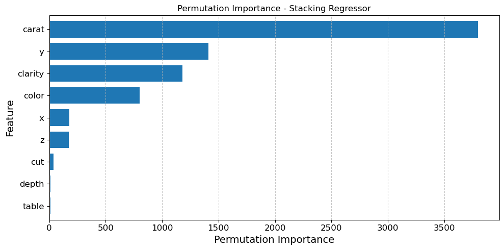

```python
if importance_df is not None:
    top_importance_df = importance_df.sort_values("Importance", ascending=True)

    top_importance_df.plot.barh(
        x="Feature",
        y="Importance",
        figsize=(10, 5),
        width=0.75,
        legend=False
    )

    plt.xlabel("Permutation Importance")
    plt.ylabel("Feature")
    plt.title(f"Permutation Importance - {best_model_name}")
    plt.grid(axis="x", linestyle="--", alpha=0.7)
    plt.tight_layout()
    plt.tight_layout()

    if SAVE_PORTFOLIO_OUTPUTS:
        plt.savefig(
            REGRESSION_IMAGES_DIR / "supervised_regression_permutation_importance.png",
            dpi=FIG_DPI,
            bbox_inches="tight"
        )

    plt.show()
```

```python
print("Original input features:", len(X_test.columns))
print("Permutation importance values:", len(importance_values))
print("Explanation is based on original input features.")
```

```
Original input features: 9
Permutation importance values: 9
Explanation is based on original input features.
```

## Log-Target Mini Experiment

**This is a small extra test to check whether the model works better when the target values are transformed to a log scale.**

The model is trained on `log1p(y_train)` instead of the original target values.  
After prediction, the results are transformed back to the original scale with `expm1()`.

This experiment is useful when the target values are highly skewed or when a few very large values may affect the model too much.

At the end, the normal version and the log-target version are compared using RMSE and R² on the original scale.

```python
start_fit = time.perf_counter()
```

```python
from sklearn.base import clone
import numpy as np

# Log-Target Mini Experiment

log_model = clone(best_model)

y_train_log = np.log1p(y_train)

log_model.fit(X_train, y_train_log)

# Log-model predictions
y_pred_log = log_model.predict(X_test)
y_pred_from_log = np.expm1(y_pred_log)

# Normal-model predictions
normal_pred = best_model.predict(X_test)

# Metrics on original target scale
log_rmse = root_mean_squared_error(y_test, y_pred_from_log)
log_r2 = r2_score(y_test, y_pred_from_log)

normal_rmse = root_mean_squared_error(y_test, normal_pred)
normal_r2 = r2_score(y_test, normal_pred)

print("Model:", best_model_name)
print("Normal target RMSE:", normal_rmse)
print("Normal target R2:", normal_r2)
print("Log target RMSE:", log_rmse)
print("Log target R2:", log_r2)
```

```
Model: Stacking Regressor
Normal target RMSE: 522.4074749766904
Normal target R2: 0.9828545638547189
Log target RMSE: 530.6912843634028
Log target R2: 0.9823065027644141
```

```python
log_target_time = time.perf_counter() - start_fit
formatted_time = str(timedelta(seconds=int(log_target_time)))
print(f"Fit time: {formatted_time}")
```

```
Fit time: 0:17:57
```

## Saving and Loading the Models

### Save all the Fitted Models

```python
start_fit = time.perf_counter()
```

```python
if not QUICK_LOAD and SAVE_MODEL_ARTIFACTS:
    import os
    import re
    import joblib
    import pandas as pd

    os.makedirs(os.path.join("_exports", "regression_models", "fitted_models"), exist_ok=True)

    def normalize_model_name(name):
        name = str(name).lower()
        name = name.replace(" regressor", "")
        name = name.replace("(", "")
        name = name.replace(")", "")
        name = name.replace("/", "_")
        name = name.replace("-", " ")
        name = re.sub(r"[^a-z0-9_ ]+", "", name)
        name = re.sub(r"\s+", " ", name).strip()
        return name

    # Build normalized lookup from TUNED_MODELS
    normalized_tuned_models = {
        normalize_model_name(model_name): model_object
        for model_name, model_object in TUNED_MODELS.items()
    }

    saved_models_info = []

    for model_name in results_df_with_total["Model"].drop_duplicates():
        normalized_name = normalize_model_name(model_name)

        if normalized_name not in normalized_tuned_models:
            continue

        model_object = normalized_tuned_models[normalized_name]

        safe_model_name = normalized_name.replace(" ", "_")
        model_filename = os.path.join("_exports", "regression_models", "fitted_models", f"fitted_model_{safe_model_name}.pkl")

        joblib.dump(model_object, model_filename)

        file_size_bytes = os.path.getsize(model_filename)
        file_size_kb = file_size_bytes / 1024
        file_size_mb = file_size_bytes / (1024 * 1024)

        saved_models_info.append({
            "Model": model_name,
            "Size_Bytes": file_size_bytes,
          # "Size_KB": file_size_kb,
            "Size_MB": file_size_mb,
            "File": model_filename
        })

    saved_models_df = pd.DataFrame(saved_models_info).reset_index(drop=True)
```

```python
if not QUICK_LOAD and SAVE_MODEL_ARTIFACTS:
    saved_models_display_df = (
        saved_models_df[
            ["Model", "Size_Bytes", "Size_MB", "File"]
        ]
        .sort_values("Model")
        .reset_index(drop=True)
    )

    styled_saved_models_df = (
        saved_models_display_df.style
        .format({
            "Size_Bytes": "{:,.0f}",
            "Size_MB": "{:,.2f}"
        })
        .set_properties(
            subset=["Model", "File"],
            **{
                "text-align": "left",
                "white-space": "nowrap"
            }
        )
        .set_table_styles([
            {
                "selector": "th.col_heading",
                "props": [("text-align", "left")]
            }
        ], overwrite=False)
    )

    display(styled_saved_models_df)

elif QUICK_LOAD:
    print("Saving skipped because QUICK_LOAD = True.")

elif not SAVE_MODEL_ARTIFACTS:
    print("Saving skipped because SAVE_MODEL_ARTIFACTS = False.")
```

|  | Model | Size_Bytes | Size_MB | File |
| --- | --- | --- | --- | --- |
| 0 | AdaBoost | 2,750,889 | 2.62 | _exports\regression_models\fitted_models\fitted_model_adaboost.pkl |
| 1 | Bagging | 827,306,985 | 788.98 | _exports\regression_models\fitted_models\fitted_model_bagging.pkl |
| 2 | Bayesian Ridge | 9,913 | 0.01 | _exports\regression_models\fitted_models\fitted_model_bayesian_ridge.pkl |
| 3 | CatBoost | 16,483,032 | 15.72 | _exports\regression_models\fitted_models\fitted_model_catboost.pkl |
| 4 | Decision Tree | 338,963 | 0.32 | _exports\regression_models\fitted_models\fitted_model_decision_tree.pkl |
| 5 | Dummy | 3,201 | 0.00 | _exports\regression_models\fitted_models\fitted_model_dummy.pkl |
| 6 | ElasticNet | 3,864 | 0.00 | _exports\regression_models\fitted_models\fitted_model_elasticnet.pkl |
| 7 | Extra Trees | 94,575,306 | 90.19 | _exports\regression_models\fitted_models\fitted_model_extra_trees.pkl |
| 8 | Gamma | 4,089 | 0.00 | _exports\regression_models\fitted_models\fitted_model_gamma.pkl |
| 9 | Gradient Boosting | 7,950,454 | 7.58 | _exports\regression_models\fitted_models\fitted_model_gradient_boosting.pkl |
| 10 | Hist Gradient Boosting | 2,097,689 | 2.00 | _exports\regression_models\fitted_models\fitted_model_hist_gradient_boosting.pkl |
| 11 | Huber | 47,017 | 0.04 | _exports\regression_models\fitted_models\fitted_model_huber.pkl |
| 12 | KNeighbors | 9,324,566 | 8.89 | _exports\regression_models\fitted_models\fitted_model_kneighbors.pkl |
| 13 | Lasso | 3,848 | 0.00 | _exports\regression_models\fitted_models\fitted_model_lasso.pkl |
| 14 | LightGBM | 1,400,589 | 1.34 | _exports\regression_models\fitted_models\fitted_model_lightgbm.pkl |
| 15 | Linear | 3,977 | 0.00 | _exports\regression_models\fitted_models\fitted_model_linear.pkl |
| 16 | MLP | 90,801 | 0.09 | _exports\regression_models\fitted_models\fitted_model_mlp.pkl |
| 17 | NuSVR | 4,957,214 | 4.73 | _exports\regression_models\fitted_models\fitted_model_nusvr.pkl |
| 18 | Passive Aggressive | 4,765 | 0.00 | _exports\regression_models\fitted_models\fitted_model_passive_aggressive.pkl |
| 19 | Poisson | 4,089 | 0.00 | _exports\regression_models\fitted_models\fitted_model_poisson.pkl |
| 20 | Quantile | 3,737 | 0.00 | _exports\regression_models\fitted_models\fitted_model_quantile.pkl |
| 21 | RANSAC | 47,689 | 0.05 | _exports\regression_models\fitted_models\fitted_model_ransac.pkl |
| 22 | Random Forest | 71,422,410 | 68.11 | _exports\regression_models\fitted_models\fitted_model_random_forest.pkl |
| 23 | Ridge | 3,769 | 0.00 | _exports\regression_models\fitted_models\fitted_model_ridge.pkl |
| 24 | SGD | 4,047 | 0.00 | _exports\regression_models\fitted_models\fitted_model_sgd.pkl |
| 25 | SVR (RBF) | 9,827,064 | 9.37 | _exports\regression_models\fitted_models\fitted_model_svr_rbf.pkl |
| 26 | SVR (linear) | 9,840,760 | 9.38 | _exports\regression_models\fitted_models\fitted_model_svr_linear.pkl |
| 27 | Stacking | 950,675,728 | 906.64 | _exports\regression_models\fitted_models\fitted_model_stacking.pkl |
| 28 | Voting | 947,864,400 | 903.95 | _exports\regression_models\fitted_models\fitted_model_voting.pkl |
| 29 | XGBoost | 2,811,310 | 2.68 | _exports\regression_models\fitted_models\fitted_model_xgboost.pkl |

### Load all the Fitted Models

```python
if not QUICK_LOAD and SAVE_MODEL_ARTIFACTS:
    import os
    import joblib
    import pandas as pd

    models_dir = os.path.join("_exports", "regression_models", "fitted_models")

    if not os.path.exists(models_dir):
        raise FileNotFoundError(f"Model directory not found: {models_dir}")

    loaded_models = {}

    for filename in sorted(os.listdir(models_dir)):
        if filename.endswith(".pkl"):
            model_key = filename.replace("fitted_model_", "").replace(".pkl", "")
            full_path = os.path.join(models_dir, filename)
            loaded_models[model_key] = joblib.load(full_path)

    if not loaded_models:
        raise FileNotFoundError(
            f"No fitted model .pkl files were found in: {models_dir}"
        )

    loaded_models_df = pd.DataFrame({
        "Model_Key": list(loaded_models.keys())
    }).reset_index(drop=True)

    display(loaded_models_df)
```

|  | Model_Key |
| --- | --- |
| 0 | adaboost |
| 1 | bagging |
| 2 | bayesian_ridge |
| 3 | catboost |
| 4 | decision_tree |
| 5 | dummy |
| 6 | elasticnet |
| 7 | extra_trees |
| 8 | gamma |
| 9 | gradient_boosting |
| 10 | hist_gradient_boosting |
| 11 | huber |
| 12 | kneighbors |
| 13 | lasso |
| 14 | lightgbm |
| 15 | linear |
| 16 | mlp |
| 17 | nusvr |
| 18 | passive_aggressive |
| 19 | poisson |
| 20 | quantile |
| 21 | random_forest |
| 22 | ransac |
| 23 | ridge |
| 24 | sgd |
| 25 | stacking |
| 26 | svr_linear |
| 27 | svr_rbf |
| 28 | voting |
| 29 | xgboost |

```python
if not QUICK_LOAD and SAVE_MODEL_ARTIFACTS:
    # Access the loaded Voting model
    display(loaded_models["voting"])

elif QUICK_LOAD:
    print("Loading skipped because QUICK_LOAD = True.")

elif not SAVE_MODEL_ARTIFACTS:
    print("Loading skipped because SAVE_MODEL_ARTIFACTS = False.")
```

```
VotingRegressor(estimators=[('cat',
                             Pipeline(steps=[('preprocessing',
                                              ColumnTransformer(transformers=[('num',
                                                                               'passthrough',
                                                                               ['carat',
                                                                                'depth',
                                                                                'table',
                                                                                'x',
                                                                                'y',
                                                                                'z']),
                                                                              ('cat',
                                                                               OneHotEncoder(handle_unknown='ignore'),
                                                                               ['cut',
                                                                                'color',
                                                                                'clarity'])])),
                                             ('model',
                                              CatBoostRegressor(allow_writing_files=False, depth=10, iterations=1000, l2_leaf_reg=1.0, learning_rate=0.03, l...
                            ('bagging',
                             Pipeline(steps=[('preprocessing',
                                              ColumnTransformer(transformers=[('num',
                                                                               'passthrough',
                                                                               ['carat',
                                                                                'depth',
                                                                                'table',
                                                                                'x',
                                                                                'y',
                                                                                'z']),
                                                                              ('cat',
                                                                               OneHotEncoder(handle_unknown='ignore'),
                                                                               ['cut',
                                                                                'color',
                                                                                'clarity'])])),
                                             ('model',
                                              BaggingRegressor(estimator=DecisionTreeRegressor(random_state=42),
                                                               max_samples=0.7,
                                                               n_estimators=300,
                                                               random_state=42))]))],
                n_jobs=1)
```

## Saving and Loading the Search Objects

### Save all the Search Objects

```python
if not QUICK_LOAD and SAVE_MODEL_ARTIFACTS:
    import os
    import re
    import joblib
    import pandas as pd

    os.makedirs("_exports", exist_ok=True)
    os.makedirs(os.path.join("_exports", "regression_models", "search_objects"), exist_ok=True)

    def normalize_model_name(name):
        name = str(name).lower()
        name = name.replace(" regressor", "")
        name = name.replace("(", "")
        name = name.replace(")", "")
        name = name.replace("/", "_")
        name = name.replace("-", " ")
        name = re.sub(r"[^a-z0-9_ ]+", "", name)
        name = re.sub(r"\s+", " ", name).strip()
        return name

    # Build normalized lookup from search objects
    normalized_search_objects = {}

    # 1) If you already have a dictionary of search objects, use it here
    if "BEST_SEARCHES" in globals():
        normalized_search_objects = {
            normalize_model_name(model_name): search_object
            for model_name, search_object in BEST_SEARCHES.items()
        }

    # 2) Fallback: build the lookup from variables ending with _search
    elif any(var_name.endswith("_search") for var_name in globals()):
        normalized_search_objects = {
            normalize_model_name(var_name.replace("_search", "")): search_object
            for var_name, search_object in globals().items()
            if var_name.endswith("_search")
        }

    saved_searches_info = []

    for model_name in results_df_with_total["Model"].drop_duplicates():
        normalized_name = normalize_model_name(model_name)

        if normalized_name not in normalized_search_objects:
            continue

        search_object = normalized_search_objects[normalized_name]

        safe_model_name = normalized_name.replace(" ", "_")
        search_filename = os.path.join(
            "_exports",
            "regression_models",
            "search_objects",
            f"regression_search_{safe_model_name}.pkl"
        )

        joblib.dump(search_object, search_filename)

        file_size_bytes = os.path.getsize(search_filename)
        file_size_kb = file_size_bytes / 1024
        file_size_mb = file_size_bytes / (1024 * 1024)

        saved_searches_info.append({
            "Model": model_name,
            "Size_Bytes": file_size_bytes,
          # "Size_KB": file_size_kb,
            "Size_MB": file_size_mb,
            "File": search_filename
        })

    saved_searches_df = pd.DataFrame(saved_searches_info).reset_index(drop=True)
```

```python
if not QUICK_LOAD and SAVE_MODEL_ARTIFACTS:
    saved_searches_display_df = (
        saved_searches_df
        .sort_values("Model")
        .reset_index(drop=True)
    )

    styled_saved_searches_df = (
        saved_searches_display_df.style
        .format({
            "Size_Bytes": "{:,.0f}",
            "Size_MB": "{:,.2f}"
        })
        .set_properties(
            subset=["Model", "File"],
            **{
                "text-align": "left",
                "white-space": "nowrap"
            }
        )
        .set_table_styles([
            {
                "selector": "th.col_heading",
                "props": [("text-align", "left")]
            }
        ], overwrite=False)
    )

    display(styled_saved_searches_df)

elif QUICK_LOAD:
    print("Saving skipped because QUICK_LOAD = True.")

elif not SAVE_MODEL_ARTIFACTS:
    print("Saving skipped because SAVE_MODEL_ARTIFACTS = False.")
```

|  | Model | Size_Bytes | Size_MB | File |
| --- | --- | --- | --- | --- |
| 0 | AdaBoost | 2,771,567 | 2.64 | _exports\regression_models\search_objects\regression_search_adaboost.pkl |
| 1 | Bagging | 827,324,831 | 789.00 | _exports\regression_models\search_objects\regression_search_bagging.pkl |
| 2 | Bayesian Ridge | 22,483 | 0.02 | _exports\regression_models\search_objects\regression_search_bayesian_ridge.pkl |
| 3 | CatBoost | 17,608,063 | 16.79 | _exports\regression_models\search_objects\regression_search_catboost.pkl |
| 4 | Decision Tree | 493,807 | 0.47 | _exports\regression_models\search_objects\regression_search_decision_tree.pkl |
| 5 | ElasticNet | 11,023 | 0.01 | _exports\regression_models\search_objects\regression_search_elasticnet.pkl |
| 6 | Extra Trees | 481,833,623 | 459.51 | _exports\regression_models\search_objects\regression_search_extra_trees.pkl |
| 7 | Gamma | 13,759 | 0.01 | _exports\regression_models\search_objects\regression_search_gamma.pkl |
| 8 | Gradient Boosting | 8,228,063 | 7.85 | _exports\regression_models\search_objects\regression_search_gradient_boosting.pkl |
| 9 | Hist Gradient Boosting | 2,845,775 | 2.71 | _exports\regression_models\search_objects\regression_search_hist_gradient_boosting.pkl |
| 10 | Huber | 103,903 | 0.10 | _exports\regression_models\search_objects\regression_search_huber.pkl |
| 11 | KNeighbors | 18,651,599 | 17.79 | _exports\regression_models\search_objects\regression_search_kneighbors.pkl |
| 12 | Lasso | 9,551 | 0.01 | _exports\regression_models\search_objects\regression_search_lasso.pkl |
| 13 | LightGBM | 1,708,375 | 1.63 | _exports\regression_models\search_objects\regression_search_lightgbm.pkl |
| 14 | MLP | 361,003 | 0.34 | _exports\regression_models\search_objects\regression_search_mlp.pkl |
| 15 | NuSVR | 9,886,067 | 9.43 | _exports\regression_models\search_objects\regression_search_nusvr.pkl |
| 16 | Passive Aggressive | 20,879 | 0.02 | _exports\regression_models\search_objects\regression_search_passive_aggressive.pkl |
| 17 | Poisson | 14,331 | 0.01 | _exports\regression_models\search_objects\regression_search_poisson.pkl |
| 18 | Quantile | 9,999 | 0.01 | _exports\regression_models\search_objects\regression_search_quantile.pkl |
| 19 | RANSAC | 99,499 | 0.09 | _exports\regression_models\search_objects\regression_search_ransac.pkl |
| 20 | Random Forest | 1,173,455,399 | 1,119.09 | _exports\regression_models\search_objects\regression_search_random_forest.pkl |
| 21 | Ridge | 10,067 | 0.01 | _exports\regression_models\search_objects\regression_search_ridge.pkl |
| 22 | SGD | 32,415 | 0.03 | _exports\regression_models\search_objects\regression_search_sgd.pkl |
| 23 | SVR (RBF) | 19,667,827 | 18.76 | _exports\regression_models\search_objects\regression_search_svr_rbf.pkl |
| 24 | SVR (linear) | 19,684,211 | 18.77 | _exports\regression_models\search_objects\regression_search_svr_linear.pkl |
| 25 | Stacking | 950,676,077 | 906.64 | _exports\regression_models\search_objects\regression_search_stacking.pkl |
| 26 | Voting | 947,864,692 | 903.95 | _exports\regression_models\search_objects\regression_search_voting.pkl |
| 27 | XGBoost | 3,273,543 | 3.12 | _exports\regression_models\search_objects\regression_search_xgboost.pkl |

### Load all the Search Objects

```python
if not QUICK_LOAD and SAVE_MODEL_ARTIFACTS:
    import os
    import joblib
    import pandas as pd

    searches_dir = os.path.join("_exports", "regression_models", "search_objects")

    if not os.path.exists(searches_dir):
        raise FileNotFoundError(f"Search directory not found: {searches_dir}")

    loaded_searches = {}

    for filename in sorted(os.listdir(searches_dir)):
        if filename.endswith(".pkl"):
            search_key = filename.replace("regression_search_", "").replace(".pkl", "")
            full_path = os.path.join(searches_dir, filename)
            loaded_searches[search_key] = joblib.load(full_path)

    if not loaded_searches:
        raise FileNotFoundError(
            f"No search object .pkl files were found in: {searches_dir}"
        )

    loaded_searches_table = pd.DataFrame({
        "Search_Key": list(loaded_searches.keys()),
        "Object_Type": [type(search).__name__ for search in loaded_searches.values()]
    }).reset_index(drop=True)

    display(loaded_searches_table)
```

|  | Search_Key | Object_Type |
| --- | --- | --- |
| 0 | adaboost | RandomizedSearchCV |
| 1 | bagging | RandomizedSearchCV |
| 2 | bayesian_ridge | GridSearchCV |
| 3 | catboost | RandomizedSearchCV |
| 4 | decision_tree | GridSearchCV |
| 5 | elasticnet | GridSearchCV |
| 6 | extra_trees | RandomizedSearchCV |
| 7 | gamma | GridSearchCV |
| 8 | gradient_boosting | RandomizedSearchCV |
| 9 | hist_gradient_boosting | RandomizedSearchCV |
| 10 | huber | RandomizedSearchCV |
| 11 | kneighbors | GridSearchCV |
| 12 | lasso | GridSearchCV |
| 13 | lightgbm | RandomizedSearchCV |
| 14 | mlp | RandomizedSearchCV |
| 15 | nusvr | GridSearchCV |
| 16 | passive_aggressive | RandomizedSearchCV |
| 17 | poisson | GridSearchCV |
| 18 | quantile | GridSearchCV |
| 19 | random_forest | RandomizedSearchCV |
| 20 | ransac | RandomizedSearchCV |
| 21 | ridge | GridSearchCV |
| 22 | sgd | RandomizedSearchCV |
| 23 | stacking | SimpleNamespace |
| 24 | svr_linear | GridSearchCV |
| 25 | svr_rbf | GridSearchCV |
| 26 | voting | SimpleNamespace |
| 27 | xgboost | RandomizedSearchCV |

```python
if not QUICK_LOAD and SAVE_MODEL_ARTIFACTS:
    # Access the loaded Voting search object
    display(loaded_searches["voting"])

elif QUICK_LOAD:
    print("Loading skipped because QUICK_LOAD = True.")

elif not SAVE_MODEL_ARTIFACTS:
    print("Loading skipped because SAVE_MODEL_ARTIFACTS = False.")
```

```
namespace(best_estimator_=VotingRegressor(estimators=[('cat',
                                                       Pipeline(steps=[('preprocessing',
                                                                        ColumnTransformer(transformers=[('num',
                                                                                                         'passthrough',
                                                                                                         ['carat',
                                                                                                          'depth',
                                                                                                          'table',
                                                                                                          'x',
                                                                                                          'y',
                                                                                                          'z']),
                                                                                                        ('cat',
                                                                                                         OneHotEncoder(handle_unknown='ignore'),
                                                                                                         ['cut',
                                                                                                          'color',
                                                                                                          'clarity'])])),
                                                                       ('model',
                                                                        CatBoostRegressor(allow_writing_files=False, depth=10, iterations=1000, l2_leaf_reg=1.0, learning_rate=0.03, l...
                                                      ('bagging',
                                                       Pipeline(steps=[('preprocessing',
                                                                        ColumnTransformer(transformers=[('num',
                                                                                                         'passthrough',
                                                                                                         ['carat',
                                                                                                          'depth',
                                                                                                          'table',
                                                                                                          'x',
                                                                                                          'y',
                                                                                                          'z']),
                                                                                                        ('cat',
                                                                                                         OneHotEncoder(handle_unknown='ignore'),
                                                                                                         ['cut',
                                                                                                          'color',
                                                                                                          'clarity'])])),
                                                                       ('model',
                                                                        BaggingRegressor(estimator=DecisionTreeRegressor(random_state=42),
                                                                                         max_samples=0.7,
                                                                                         n_estimators=300,
                                                                                         random_state=42))]))],
                                          n_jobs=1),
          best_params_={'base_estimators': ['cat_best_tuning',
                         'gbr_best_tuning',
                         'extra_trees_best_tuning',
                         'mlp_best_tuning',
                         'lgbm_best_tuning',
                         'bagging_best_tuning'],
                        'weights': None,
                        'additional_grid_search': False})
```

## Saving and Loading the Base Models

### Save all the Base Models

```python
if not QUICK_LOAD and SAVE_MODEL_ARTIFACTS:
    import os
    import joblib
    import pandas as pd

    os.makedirs("_exports", exist_ok=True)
    os.makedirs(os.path.join("_exports", "regression_models", "fitted_base_models"), exist_ok=True)

    model_variable_map = {
        "Dummy": "dummy_reg",
        "Linear": "lin_reg",
        "Ridge": "ridge_reg",
        "Lasso": "lasso_reg",
        "ElasticNet": "elastic_reg",
        "Bayesian Ridge": "bayes_ridge_reg",
        "Quantile": "quantile_reg",
        "Huber": "huber_reg",
        "RANSAC": "ransac_reg",
        "SGD": "sgd_reg",
        "Passive Aggressive": "pa_reg",
        "Poisson": "poisson_reg",
        "Gamma": "gamma_reg",
        "SVR (linear)": "svr_linear",
        "SVR (RBF)": "svr_rbf",
        "KNeighbors": "knn_reg",
        "NuSVR": "nusvr_reg",
        "Decision Tree": "dt_reg",
        "Random Forest": "rf_reg",
        "Extra Trees": "extra_trees_reg",
        "AdaBoost": "ada_reg",
        "Gradient Boosting": "gbr_reg",
        "Hist Gradient Boosting": "hgb_reg",
        "XGBoost": "xgb_reg",
        "LightGBM": "lgbm_reg",
        "CatBoost": "cat_reg",
        "MLP": "mlp_reg",
        "Bagging": "bagging_reg",
        "Voting": "voting_reg",
        "Stacking": "stacking_reg",
    }

    saved_fitted_base_models_info = []

    for model_name in results_df_with_total["Model"].drop_duplicates():
        if model_name not in model_variable_map:
            continue

        var_name = model_variable_map[model_name]

        if var_name not in globals():
            continue

        fitted_model = globals()[var_name]

        safe_model_name = (
            model_name.lower()
            .replace(" ", "_")
            .replace("(", "")
            .replace(")", "")
            .replace("/", "_")
        )

        model_filename = os.path.join(
            "_exports",
            "regression_models",
            "fitted_base_models",
            f"fitted_base_model_{safe_model_name}.pkl"
        )

        joblib.dump(fitted_model, model_filename)

        file_size_bytes = os.path.getsize(model_filename)
        file_size_mb = file_size_bytes / (1024 * 1024)

        saved_fitted_base_models_info.append({
            "Model": model_name,
            "Size_Bytes": file_size_bytes,
            "Size_MB": file_size_mb,
            "File": model_filename
        })

    saved_fitted_base_models_df = pd.DataFrame(saved_fitted_base_models_info).reset_index(drop=True)
```

```python
if not QUICK_LOAD and SAVE_MODEL_ARTIFACTS:
    saved_fitted_base_models_display_df = (
        saved_fitted_base_models_df
        .sort_values("Model")
        .reset_index(drop=True)
    )

    styled_saved_fitted_base_models_df = (
        saved_fitted_base_models_display_df.style
        .format({
            "Size_Bytes": "{:,.0f}",
            "Size_MB": "{:,.2f}"
        })
        .set_properties(
            subset=["Model", "File"],
            **{
                "text-align": "left",
                "white-space": "nowrap"
            }
        )
        .set_table_styles([
            {
                "selector": "th.col_heading",
                "props": [("text-align", "left")]
            }
        ], overwrite=False)
    )

    display(styled_saved_fitted_base_models_df)

elif QUICK_LOAD:
    print("Saving skipped because QUICK_LOAD = True.")

elif not SAVE_MODEL_ARTIFACTS:
    print("Saving skipped because SAVE_MODEL_ARTIFACTS = False.")
```

|  | Model | Size_Bytes | Size_MB | File |
| --- | --- | --- | --- | --- |
| 0 | AdaBoost | 143,289 | 0.14 | _exports\regression_models\fitted_base_models\fitted_base_model_adaboost.pkl |
| 1 | Bagging | 300,621,529 | 286.70 | _exports\regression_models\fitted_base_models\fitted_base_model_bagging.pkl |
| 2 | Bayesian Ridge | 9,913 | 0.01 | _exports\regression_models\fitted_base_models\fitted_base_model_bayesian_ridge.pkl |
| 3 | CatBoost | 1,120,637 | 1.07 | _exports\regression_models\fitted_base_models\fitted_base_model_catboost.pkl |
| 4 | Decision Tree | 110,003 | 0.10 | _exports\regression_models\fitted_base_models\fitted_base_model_decision_tree.pkl |
| 5 | Dummy | 3,201 | 0.00 | _exports\regression_models\fitted_base_models\fitted_base_model_dummy.pkl |
| 6 | ElasticNet | 3,848 | 0.00 | _exports\regression_models\fitted_base_models\fitted_base_model_elasticnet.pkl |
| 7 | Extra Trees | 387,253,594 | 369.31 | _exports\regression_models\fitted_base_models\fitted_base_model_extra_trees.pkl |
| 8 | Gamma | 4,089 | 0.00 | _exports\regression_models\fitted_base_models\fitted_base_model_gamma.pkl |
| 9 | Gradient Boosting | 273,878 | 0.26 | _exports\regression_models\fitted_base_models\fitted_base_model_gradient_boosting.pkl |
| 10 | Hist Gradient Boosting | 744,225 | 0.71 | _exports\regression_models\fitted_base_models\fitted_base_model_hist_gradient_boosting.pkl |
| 11 | Huber | 47,017 | 0.04 | _exports\regression_models\fitted_base_models\fitted_base_model_huber.pkl |
| 12 | KNeighbors | 9,324,566 | 8.89 | _exports\regression_models\fitted_base_models\fitted_base_model_kneighbors.pkl |
| 13 | Lasso | 3,848 | 0.00 | _exports\regression_models\fitted_base_models\fitted_base_model_lasso.pkl |
| 14 | LightGBM | 298,507 | 0.28 | _exports\regression_models\fitted_base_models\fitted_base_model_lightgbm.pkl |
| 15 | Linear | 3,977 | 0.00 | _exports\regression_models\fitted_base_models\fitted_base_model_linear.pkl |
| 16 | MLP | 266,929 | 0.25 | _exports\regression_models\fitted_base_models\fitted_base_model_mlp.pkl |
| 17 | NuSVR | 4,926,686 | 4.70 | _exports\regression_models\fitted_base_models\fitted_base_model_nusvr.pkl |
| 18 | Passive Aggressive | 4,031 | 0.00 | _exports\regression_models\fitted_base_models\fitted_base_model_passive_aggressive.pkl |
| 19 | Poisson | 4,089 | 0.00 | _exports\regression_models\fitted_base_models\fitted_base_model_poisson.pkl |
| 20 | Quantile | 3,737 | 0.00 | _exports\regression_models\fitted_base_models\fitted_base_model_quantile.pkl |
| 21 | RANSAC | 47,689 | 0.05 | _exports\regression_models\fitted_base_models\fitted_base_model_ransac.pkl |
| 22 | Random Forest | 1,102,028,266 | 1,050.98 | _exports\regression_models\fitted_base_models\fitted_base_model_random_forest.pkl |
| 23 | Ridge | 3,769 | 0.00 | _exports\regression_models\fitted_base_models\fitted_base_model_ridge.pkl |
| 24 | SGD | 4,047 | 0.00 | _exports\regression_models\fitted_base_models\fitted_base_model_sgd.pkl |
| 25 | SVR (RBF) | 9,838,702 | 9.38 | _exports\regression_models\fitted_base_models\fitted_base_model_svr_rbf.pkl |
| 26 | SVR (linear) | 9,841,902 | 9.39 | _exports\regression_models\fitted_base_models\fitted_base_model_svr_linear.pkl |
| 27 | Stacking | 690,337,760 | 658.36 | _exports\regression_models\fitted_base_models\fitted_base_model_stacking.pkl |
| 28 | Voting | 689,884,176 | 657.92 | _exports\regression_models\fitted_base_models\fitted_base_model_voting.pkl |
| 29 | XGBoost | 453,566 | 0.43 | _exports\regression_models\fitted_base_models\fitted_base_model_xgboost.pkl |

### Load all the Base Models

```python
if not QUICK_LOAD and SAVE_MODEL_ARTIFACTS:
    import os
    import joblib
    import pandas as pd

    models_dir = os.path.join("_exports", "regression_models", "fitted_base_models")

    if not os.path.exists(models_dir):
        raise FileNotFoundError(f"Model directory not found: {models_dir}")

    loaded_fitted_base_models = {}

    for filename in sorted(os.listdir(models_dir)):
        if filename.endswith(".pkl"):
            model_key = filename.replace("fitted_base_model_", "").replace(".pkl", "")
            full_path = os.path.join(models_dir, filename)
            loaded_fitted_base_models[model_key] = joblib.load(full_path)

    if not loaded_fitted_base_models:
        raise FileNotFoundError(
            f"No fitted base model .pkl files were found in: {models_dir}"
        )

    loaded_fitted_base_models_df = pd.DataFrame({
        "Model_Key": list(loaded_fitted_base_models.keys())
    }).reset_index(drop=True)

    display(loaded_fitted_base_models_df)
```

|  | Model_Key |
| --- | --- |
| 0 | adaboost |
| 1 | bagging |
| 2 | bayesian_ridge |
| 3 | catboost |
| 4 | decision_tree |
| 5 | dummy |
| 6 | elasticnet |
| 7 | extra_trees |
| 8 | gamma |
| 9 | gradient_boosting |
| 10 | hist_gradient_boosting |
| 11 | huber |
| 12 | kneighbors |
| 13 | lasso |
| 14 | lightgbm |
| 15 | linear |
| 16 | mlp |
| 17 | nusvr |
| 18 | passive_aggressive |
| 19 | poisson |
| 20 | quantile |
| 21 | random_forest |
| 22 | ransac |
| 23 | ridge |
| 24 | sgd |
| 25 | stacking |
| 26 | svr_linear |
| 27 | svr_rbf |
| 28 | voting |
| 29 | xgboost |

```python
if not QUICK_LOAD and SAVE_MODEL_ARTIFACTS:
    # Access the loaded fitted base Voting model
    display(loaded_fitted_base_models["voting"])

elif QUICK_LOAD:
    print("Loading skipped because QUICK_LOAD = True.")

elif not SAVE_MODEL_ARTIFACTS:
    print("Loading skipped because SAVE_MODEL_ARTIFACTS = False.")
```

```
VotingRegressor(estimators=[('cat',
                             Pipeline(steps=[('preprocessing',
                                              ColumnTransformer(transformers=[('num',
                                                                               'passthrough',
                                                                               ['carat',
                                                                                'depth',
                                                                                'table',
                                                                                'x',
                                                                                'y',
                                                                                'z']),
                                                                              ('cat',
                                                                               OneHotEncoder(handle_unknown='ignore'),
                                                                               ['cut',
                                                                                'color',
                                                                                'clarity'])])),
                                             ('model',
                                              CatBoostRegressor(allow_writing_files=False, iterations=1000, l2_leaf_reg=3.0, loss_function='RMSE', random_s...
                            ('bagging',
                             Pipeline(steps=[('preprocessing',
                                              ColumnTransformer(transformers=[('num',
                                                                               'passthrough',
                                                                               ['carat',
                                                                                'depth',
                                                                                'table',
                                                                                'x',
                                                                                'y',
                                                                                'z']),
                                                                              ('cat',
                                                                               OneHotEncoder(handle_unknown='ignore'),
                                                                               ['cut',
                                                                                'color',
                                                                                'clarity'])])),
                                             ('model',
                                              BaggingRegressor(estimator=DecisionTreeRegressor(random_state=42),
                                                               max_samples=0.8,
                                                               n_estimators=100,
                                                               random_state=42))]))],
                n_jobs=1)
```